# 再论不平等的起源

运气基线、两段分布，与一次可以算出来的相变

*首次发布时间：2026-10-26 ｜ 最后更新时间：2026-10-29 21:33 EDT*

# 摘要

卢梭把不平等的来源分成自然与人造两类。本文把他的思想实验真正跑一遍，看到第三个来源——运气；再逐个量出其他机制把不平等推高或压低多少，最后说明只看基尼系数为什么不够。

- 第 1 章 卢梭的问题，以及模型能补上的那一格。
- 第 2 章 一座公平的岛：人人起步相同、规则相同，多年以后财富怎样分布？先请读者猜两道题。
- 第 3 章 第一题的答案：这个形状从哪来，换掉零件还剩什么。
- 第 4 章 第二题的答案：这个基线怎么算，在现实里意味着什么。
- 第 5 章 推到极限：回报带上涨落，不平等能坏到什么程度。
- 第 6 章 其他来源：能力、信贷、继承、增长、税收，各自把不平等推向哪边、推多远。
- 第 7 章 一个数不够：同样的不平等程度，可以是流动的，也可以是固定的。
- 第 8 章 结语：回到卢梭，把账本补成三栏。

*本文由《公平与效率：同一个温度》拆分而来：那一篇处理“要不要为效率牺牲公平”，本篇处理不平等从哪来。全文的图与表在 knit 时现算，结果数字在算出处登记溯源（清单见文末）。较长的推导多放在可折叠的细节里，跳过不影响往下读。*

# 1 从卢梭的问题开始

1754 年，法国第戎科学院悬赏征文，题目是：“人类不平等的起源是什么？它是否为自然法所许可？” 卢梭交了一篇四倍于要求长度的稿子，落选了——四年前他凭《论科学与艺术》拿过同一个奖的头名。这篇落选的稿子 1755 年出版，就是《论人类不平等的起源和基础》。

他的答案分两步。

第一步：把“不平等”劈成两半。

- 自然的不平等：年龄、体力、健康、天资。
- 政治的（或道德的）不平等：财富、地位、权力、特权——它们“依赖于约定”，是人造的。

卢梭的判断是：自然的不平等很小，而且在自然状态里几乎不起作用（没有积累，谁强壮一点无关紧要）；我们看到的巨大差距，几乎全部来自第二类。

第二步：给出人造不平等的机制链。冶金与农业 → 分工 → 私有财产 → 相互依赖 → 攀比（他区分 *amour de soi*「自保之爱」与 *amour-propre*「自尊／虚荣」，后者只在社会中产生，是不平等的引擎）→ 差距固化 → 法律与政府 → 专制。其中最尖锐的一步是：法律的确立，把既成的篡夺变成了永久的权利。第二部分开篇那句话是全书最出名的——第一个圈起一块地、说“这是我的”、并且找到一群头脑简单到相信他的人的人，就是文明社会真正的奠基者。

（顺带纠一个常见误读：卢梭从未用过“高贵的野蛮人”这个说法，也没有主张回到森林里去。）

有一点常被忽略，但对本文最要紧：卢梭明确说过他不是在写历史。他要“撇开事实”，从人的天性出发推理出一条可能的路径。用今天的话说，《论不平等》是一个思想实验，一个模型——只是在他那里，这个模型跑不起来。

今天它跑得起来。而一跑起来，就会冒出一个他不可能看见的答案。

## 1.1 两百年后多出来的第三个来源：运气

卢梭把不平等分成“自然的”和“人造的”，这个二分里藏着一个默认前提：每一份不平等都得有一个原因——要么来自天赋差异，要么来自人为安排。

把他的思想实验真的跑一遍，会看到第三样东西：

> 没有天赋差异，没有私有财产，没有圈地的人，规则对所有人一字不差，每一笔交易都是一次公平的抛硬币——结果依然会稳定在一个相当不平等的分布上。

这份不平等既不是自然的，也不是人造的。它是运气的——每一笔交易谁多谁少纯属偶然，而偶然本身就会沉淀出差距。

直觉在这里会拦一下：运气有好有坏，长期下来不是该正负抵消吗？抵消的只是均值——总量守恒，每个人的期望财富自始至终都是平均数，一分不多一分不少。但不平等量的不是均值，是离散度，而离散度不会抵消，只会越搅越开，直到撞上唯一的那堵墙：财富有下界，却没有上界。

这堵墙不在零上，这一点值得先说清，免得后面被读成一句假话。现实里净资产为负的人不少——房贷、学贷、信用卡，富人欠银行的更多。但借得到多少是有限的：放贷要抵押或看收入，破产还能把债一笔勾销，于是往下这一头被拦在离零不远的地方；而往上那一头不封顶。真正让分布向右拖出尾巴的是这个不对称，不是零这个具体位置。第 6.1.2 节会把信贷装进模型，让财富真的可以为负，看这堵墙松动之后会怎样。

有了这堵墙，剩下的就是组合计数：在所有可能的分法里，“穷”这个状态的实现方式远远多于“富”（第 3.2 节会把这些分法一个一个数给你看）。随机搅拌落在哪一档，概率就正比于那一档有多少种分法——于是它必然停在一个右偏的分布上，而且停稳之后不再回来。

所以这份不平等不需要任何人做错事，也不需要原因。

这不推翻卢梭，而是给他补一条**运气基线**。

他说自然不平等很小——这点被现代数据支持。要补的是下一步的记账方式。卢梭那两步是这样走的：先把自然的那份划掉，剩下的整个归入“人造”；再在人造这一栏里往下追，一路追到私有财产、追到法律把既成事实钉成权利。两步各自都不错，但这是一本只有两个格子的账——它没有给“没有原因的那部分”留位置。

运气基线补的就是这个格子，而且它插在第一步和第二步之间：人造那一栏得先减掉纯运气的沉淀，剩下的才轮到机制来解释。低于基线，说明有再分配在起作用；高于基线，说明有正反馈、或者规则的异质性在放大——而“规则对不同人不一样”，正是卢梭那位圈地者在模型里的样子。他确实在这一栏里，只是这一栏不全是他的。

这条基线具体是多少？下一章会先让你猜，再揭晓。

# 2 一座与世隔绝的岛：一万枚金币，很多年后

一个富有的海盗路过一座与世隔绝的岛。

岛上物产丰饶，住着一千个岛民，没有货币，也没有任何层级——没有酋长，没有祭司，没有地主，人和人之间完全对等。海盗一时兴起，从船上搬下一箱金币：给每个岛民十枚，一共一万枚，告诉他们这些金币可以自由交换，然后扬帆走了。

很多年后他回来。岛还是那座岛：

- 依然与世隔绝——没有一枚金币流进来，也没有一枚流出去；
- 依然绝对程序公平——没长出任何层级，没有利息，没有价格，没有人被偏袒，规则对每个岛民一字不差；
- 岛民不死——没有生老病死，于是也没有继承：没有人把金币传给子女；夫妻之间既不合并钱袋，也不互相赠予。很多年之后，拿着金币的还是最初那一千个人。
- 破产的人照样参加交换——一枚金币都没有的岛民，下一轮同样会被配到对子里；他只是这一轮拿不出东西给对方，但随时可能收到一枚。在这座岛上，破产不是出局，只是暂时的。
- 金币对岛民来说依然只是好看的东西，谁跟谁换、换多少，纯凭一时兴起。

唯一变了的，是金币的分布。

这几条不是修辞，它们就是模型的全部前提：

| 故事里的说法 | 模型里的前提 | 落到数学上 |
| --- | --- | --- |
| 依然与世隔绝 | 总量守恒 | Σ w = M，每一轮都相等 |
| 依然绝对程序公平 | 规则同质且无偏 | 对每一对 (i, j)：P(i 给 j) = P(j 给 i) = ½，与两人是谁、各持多少无关 |
| 岛上没有信贷 | 0 处有一堵墙 | w ≥ 0，对每个人、每一轮 |
| 破产的人照样参加交换 | 这堵墙是反射的 | w = 0 的人这一轮只收不付，且 P(0 → 1) > 0——0 不是吸收态 |
| 岛民不死，也不传给谁 | 持币者恒为最初那 N 人 | 参与者集合固定、N 恒定；除交换外没有任何改变 w 的操作 |

最后一条看着像图省事，其实是把继承与婚配这一整族机制直接摘掉——不是调成中性，是让它们根本不存在。省下来的是一堆本来必须补的假设（谁和谁配对、婚姻合不合并钱袋、传给谁、传多少），而换来的结论更硬：接下来看到的一切，都不能推给婚姻、继承或人口结构。它还让“很多年”这个跨度不需要任何解释——同一批人一直在换金币而已，后面那张“跟着同一个岛民三万轮”的图也因此是字面意义上的同一个人。

现实里当然不是这样，而松开这一条是一族方向可正可负的旋钮：诸子均分是均等化，长子继承是集中，婚姻门当户对（同类结婚）则是放大。本文先把它们整族拿掉，留到第 6.2 节再装回去量。

中间两条说的是同一堵墙的两件事，缺一不可：一是墙存在（没有信贷，财富不能为负），二是这堵墙会反弹（破产不出局）。用一句话记：0 是一堵墙，不是一个坑。

两件事都要紧，而且缺哪一件，跑出来的都是另一个模型：把墙拆掉（允许借贷、财富可以为负），是一回事，第 6 章会拿数据说话；把墙换成坑（破产即出局），又是另一回事，数学上那属于赌徒破产问题，第 4.3 节会遇到它的近亲。两条都不在本章的设定里——这座岛上，墙在，而且会反弹。

最后交代一个贯穿全文的口径。这个模型跟踪的量是每个岛民手里有多少金币——那是存量，也就是财富。所以本文出现的每一个基尼系数，除非明确写出“收入”二字，都是财富基尼，不是收入基尼。两者混起来会得出完全错误的结论。差多少、为什么差，本章后面会说到，而真正把它算出来要到第 4.2 节。

落到代码上，规则只有一句：每一轮把一千个岛民随机两两配对，每一对里随机挑一个人，交给对方 1 枚金币。

## 2.1 先答两道题

往下看之前先自己答。这两道题几乎所有人都会答错，而错在哪里正是本文的全部内容。

第一题：很多年之后，把这 1000 个岛民各自手里的金币数统计成分布，它最接近下面哪个形状？（注意是按人头统计，而且手里是 0 枚的人也算在内）

- A. 均值仍是 10 枚的正态分布——人数最多的还是 10 枚附近，只是比一开始散开了些。
- B. 均值仍是 10 枚的对数正态分布——人数最多的那一格在 10 枚以下，右边拖出一条尾巴。
- C. 均值仍是 10 枚的指数分布——人数最多的是最穷的那一格，此后每多一枚金币，人数按同一个固定比例递减。
- D. 均值仍是 10 枚的幂律分布——人数最多的也是最穷的那一格，但尾巴粗得多，极少数人拿走绝大部分金币。

第二题：这座岛金币存量的基尼系数最接近哪个？（0 = 完全平均，1 = 一人独占）

- A. ≈ 0——和出发时一样，几乎没有分化
- B. ≈ 0.25
- C. ≈ 0.5
- D. ≈ 0.75

**想好了再点开：答案与四个选项各自对应的机制**

第一题的答案是 C：指数分布。

$p(x) \propto e^{-x/\mu}$，均值 $\mu = 10$。（严格说，金币不可切分，精确答案是它的离散版几何分布 $p_n\propto q^{\,n}$，$q = 10/11$；不过每人十枚已经足够细，形状上就是一条指数——离散只体现在基尼系数的第二位小数上。）

翻译成人话：人数最多的那一格是身无分文，此后每多一枚金币，人数就少大约 9%。一座程序上绝对公平、与世隔绝、连价格都没有的岛，自己长出了一个相当悬殊的财富分布。

四个选项不是随便凑的，每一个都是某种真实机制的正确答案——只不过不是这一个：

- A（正态）：这是“随机 = 在均值附近涨落”的直觉，它对独立的随机误差成立——每个人的偏差各自独立，互不相干，于是围着均值堆成钟形。但这座岛上的转移是守恒的：一个人多一枚，必然另一个人少一枚，偏差之间被硬绑在一起；再加上财富有下界、无上界，分布只能向右拖出尾巴。守恒 + 有下界无上界 = 指数，不是正态。
- B（对数正态）：如果财富靠的是独立的乘性增长——每期按百分比涨跌、彼此不相干，既没有守恒也没有托底——那么 $\ln W$ 就是一次随机游走，中心极限定理给出对数正态。这座岛的总量是守恒的，不是这种。
- C（指数）：正确。三个前提各干一件事，缺一不可：守恒把均值钉死（有人多必有人少，分布不能整体漂移）；0 是墙让财富只能向右展开——有下界、无上界，所以分布必然右偏；无偏意味着没有一根把偏离的人拉回中间的弹簧（那会给出正态分布），只有一个对人人相同、朝向 0 的轻微漂移——它来自身无分文的人付不出钱（第 3.1 节）。三条合起来，剩下的唯一可能就是“在给定均值、不能为负之外不多假设任何东西”的那个分布——指数分布。直觉版更短：手里钱少的实现方式，比手里钱多的实现方式多得多（第 3 章会把这句话数出来）。 而“缺一不可”是字面意思——每拆掉一条，答案就换一个：拆掉守恒（有增长），答案取决于增量怎么分（第 6 章）；拆掉0 这堵墙（有信贷），平稳态可能根本不存在（第 6.1.2 节）；拆掉无偏（规则对不同人不一样），指数尾立刻变成幂律尾——那正好就是选项 D。
- D（幂律）：如果岛民的储蓄习惯因人而异，或者金币能生息、利率还带随机性而同时存在托底（工资、转移支付），答案就是它。这两条后面都会加进模型里试一遍。

第二题的答案也是 C：基尼系数约 0.52。精确值是 $11/21$，那个零头来自金币不可切分——第 3 章定形状，第 4 章算这个数。

答案摆在上面了，但摆出答案不等于看见它发生。

下面这张图就是把这座岛跑出来的样子，同时回答一个更要紧的问题：这个不平等，是“不同的人”，还是“同一个人的不同时候”？

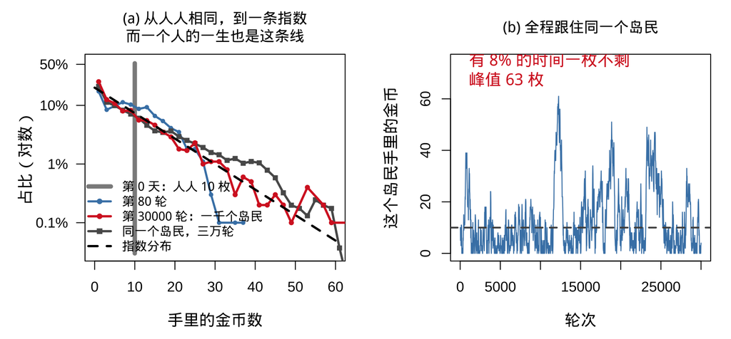

```r
## 岛屿模型：1000 个岛民各持 10 枚金币；每轮全体随机两两配对，每对里一人给另一人 1 枚
coin_game <- function(N = ISL_N, coins = ISL_C0, rounds = ISL_ROUNDS,
                      snaps = c(15, 80, ISL_ROUNDS), track = 1, seed = 4){
  set.seed(seed)
  w <- rep(coins, N); half <- N/2
  traj <- integer(rounds + 1); traj[1] <- w[track]; out <- list(`0` = w)
  for (r in 1:rounds){
    idx <- sample.int(N); i <- idx[1:half]; j <- idx[(half + 1):N]
    pay <- w[i] > 0                       # 手里没钱的人这一轮不付
    w[i] <- w[i] - pay; w[j] <- w[j] + pay
    traj[r + 1] <- w[track]
    if (r %in% snaps) out[[as.character(r)]] <- w
  }
  list(snaps = out, traj = traj, w = w)
}
G <- coin_game()
ACC <- "#D62728"
brk <- seq(0, 400, by = 2)
dens <- function(v){ h <- hist(pmin(v, 400), breaks = brk, plot = FALSE)
                     list(x = h$mids, y = h$counts/sum(h$counts)) }

par(mfrow = c(1, 2), mar = c(4.6, 5.0, 3.2, 1.2), cex.lab = 1.12, cex.main = 1.05)

## (a) 平均主义怎么塌掉的——顺便把"一个人的一生"叠上去（遍历性）
plot(NA, xlim = c(0, 60), ylim = c(3e-4, 0.55), log = "y", yaxt = "n",
     xlab = "手里的金币数", ylab = "占比（对数）",
     main = "(a) 从人人相同，到一条指数\n而一个人的一生也是这条线")
axis(2, at = c(0.5, 0.1, 0.01, 1e-3), labels = c("50%", "10%", "1%", "0.1%"), las = 1)
segments(10, 3e-4, 10, 0.52, lwd = 5, col = "gray55")                    # 第 0 天
d80 <- dens(G$snaps[["80"]]); ok <- d80$y > 0
lines(d80$x[ok], d80$y[ok], type = "o", pch = 16, cex = .7, lwd = 2.4, col = "steelblue")
dt <- dens(G$traj[301:length(G$traj)])            # 同一个岛民的时间直方图，掐掉前 300 轮热身
lines(dt$x[dt$y > 0], dt$y[dt$y > 0], type = "o", pch = 15, cex = .8, lwd = 2.6, col = "gray35")
dp <- dens(G$w)                                    # 最后一刻的横截面
lines(dp$x[dp$y > 0], dp$y[dp$y > 0], type = "o", pch = 16, cex = .8, lwd = 2.6, col = ACC)
curve(2*dexp(x, 1/10), add = TRUE, lty = 2, lwd = 2.6, col = "black")
legend("bottomleft",
       c("第 0 天：人人 10 枚", "第 80 轮", "第 30000 轮：一千个岛民",
         "同一个岛民，三万轮", "指数分布"),
       col = c("gray55", "steelblue", ACC, "gray35", "black"),
       lwd = c(5, 2.4, 2.6, 2.6, 2.6), lty = c(1, 1, 1, 1, 2),
       pch = c(NA, 16, 16, 15, NA), bty = "n", cex = 0.88)

## (b) 同一个人的一生
ii <- seq(1, length(G$traj), by = 20)
plot(ii, G$traj[ii], type = "l", col = "steelblue", lwd = 1.1,
     ylim = c(0, max(G$traj)*1.18),
     xlab = "轮次", ylab = "这个岛民手里的金币",
     main = "(b) 全程跟住同一个岛民")
abline(h = 10, lty = 2, lwd = 2, col = "gray30")
text(0, max(G$traj)*1.10,
     sprintf("有 %.0f%% 的时间一枚不剩\n峰值 %d 枚", 100*mean(G$traj == 0), max(G$traj)),
     col = ACC, cex = 1.15, pos = 4)
```

左图：绝对的平均在几十轮里就塌了，而且塌成了一条直线。80 轮时分布已经明显右偏、开始贴住 0；跑到平衡，它在半对数坐标上就是一条直线——指数分布，图里那条黑虚线正是它。人数最多的那一格是最穷的那一格，9% 的人一枚不剩，基尼 = 0.523。同一张图上还叠了第四条线：把任意一个岛民三万轮里的财富做直方图（深灰方块），它和最后一刻一千个岛民的横截面（红）落在同一条曲线上。这是遍历性——时间平均 = 系综平均。

右图：所以这不是“有些人天生会赚钱”。图里从头到尾跟着的是同一个岛民。他破产过（8% 的时间一枚不剩），也阔过（峰值 63 枚，是平均的 6 倍）。他和别人唯一的区别是运气的先后顺序。两张图合起来说的是一件事：那条指数曲线不是什么“阶层结构”，它是同一个人在不同时刻的样子被摊平摆开。（这条性质是本文最后要回到的地方：它意味着“不平等”这个词在这里指的是同一个人的起落，不是不同人的固定位置。真实社会两者混在一起，而基尼分不出来。）

这台机器不是经济学的发明。物理学里早有一台一模一样的，而且是同一个方程：玻尔兹曼–吉布斯律。大量粒子之间不停碰撞、交换能量，碰撞不偏袒任何一个粒子，总能量守恒，能量不能为负——于是稳态下，系统处在能量为 $E$ 的状态上的概率正比于 $e^{-E/T}$ (Boltzmann 1877)。最干净的实物例子是等温大气：重力对每个分子一视同仁、不随高度变化，地面把分子挡住，于是空气密度随高度按指数衰减。把“能量”换成“金币”、“粒子”换成“岛民”，守恒、无偏、有下界这三条一条不差，公式一个字都不用改；气体里那个温度的位置，在这里由人均金币顶替。这正是 Drăgulescu 与 Yakovenko 2000 年把货币当成能量来写的那篇文章 (Drăgulescu and Yakovenko 2000)，第 2.3 节会交代它的来龙去脉。

顺带交代一句开场留下的口径。上面这条指数分布给的是这座岛的财富基尼；它的收入基尼是另一回事，而且根本不是一个定数——取决于“多少轮算作一年”。两者差在哪，第 2.2 节先分清口径，第 4.2 节再把数算出来。

## 2.2 三个口径，三个数

从这里到本章结束，摆出来的事实和模型都是别人的——先看现实世界的形状，再看这台机器的来历。本文自己的只有拿它们做的分解、对照与取舍，那几处会随手点明。

马上就要把这座岛和真实国家放在一起比。比之前，先把三件事分清。它们在公共讨论里几乎天天被混，而且混了之后所有比较都不成立：

**第 2 条的细节：哪些养老金算进净资产、哪些不算（可跳过）**

上面那些数字量的是家庭净资产（金融资产 + 实物资产 − 负债），标准是你现在能不能支配、能不能变现：

- 算进去的：你名下能自己处置的账户余额——美国的 401(k)、IRA，各类个人储蓄与投资。这些就是金融资产，一分不少。
- 不算进去的：对未来给付的权益——美国的 Social Security、瑞典的 inkomstpension、瑞士的 OASI 这类**公共现收现付**养老金，以及多数国家的**职业年金**。它们没有市价，不能变卖，也不能继承给子女，于是在资产负债表上是零，尽管对普通家庭那往往是一生中最大的一笔指望。

注意瑞士第二支柱：它完全积累、而且有个人账户，照样不计入净资产——因为退休前不可自由支配。所以判据不是“积累还是现收现付”，是“现在能不能动”。这里的两个百分比容易被读成把 0.20 拆成两块，但原文报的是各自单独的反事实：只把法定养老金加进净资产，基尼从 0.75 降到 0.57（降 23%）；只把职业年金加进去，降到 0.65（降 13%）；两者都加进去（增广财富）才是 0.55，合计降 26% (Kuhn 2020)。三次比较各自独立，23% 与 13% 不相加、也加不出 26%。（这几个降幅是原文算自未舍入值的，拿上面那几个已舍入的基尼去除会差一个百分点——所以两者分别登记，不互推。）

最后一件事，也正好把上面三层口径收个尾：这不是一个数学玩具。用美国税务与人口普查数据实测，个人收入分布中占绝大多数人口的那一段确实是指数分布，其 Lorenz 曲线不含任何拟合参数就与数据吻合；而指数分布的基尼系数恒为 $1/2$，所以这条实证给出的个人收入基尼系数就是 0.5 (Drăgulescu and Yakovenko 2001a)。

那条曲线是闭式的，所以可以就地重画一遍——下图左边就是它：

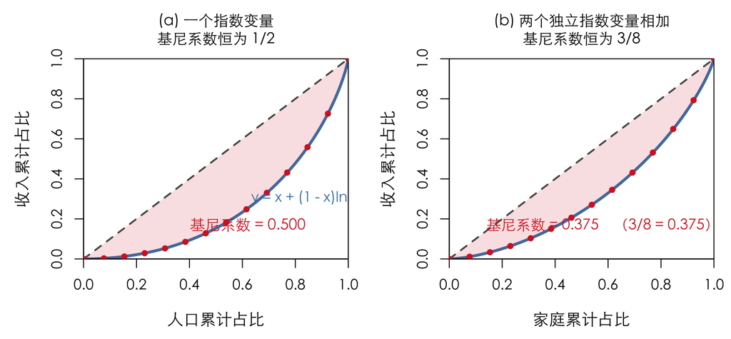

```r
## 复现 Drăgulescu–Yakovenko (2001) 的两条 Lorenz 曲线。
## 两条都是解析式、无拟合参数；红点是按对应分布抽样得到的，用来演示数据会落在线上。
ACC2 <- "#D62728"; BLU2 <- "steelblue"
lor_gini <- function(x, y) 1 - 2*sum((y[-1] + y[-length(y)])/2 * diff(x))   # 梯形法求面积

par(mfrow = c(1, 2), mar = c(4.6, 4.8, 3.4, 1.0), cex.lab = 1.12,
    cex.main = 1.04, family = "cjk")
nS <- 20000; pS <- (1:nS)/nS; iS <- round(seq(1, nS, length.out = 14))

## (a) 个人收入：该文 Fig. 3 的实线
xa <- seq(0, 1, length.out = 400); ya <- xa + (1 - xa)*log(1 - xa)
ya[1] <- 0; ya[length(ya)] <- 1
plot(xa, ya, type = "l", lwd = 3.2, col = BLU2, xlim = c(0, 1), ylim = c(0, 1),
     xaxs = "i", yaxs = "i", xlab = "人口累计占比", ylab = "收入累计占比",
     main = "(a) 一个指数变量
基尼系数恒为 1/2")
polygon(c(xa, rev(xa)), c(xa, rev(ya)), col = adjustcolor(ACC2, .14), border = NA)
lines(c(0, 1), c(0, 1), lty = 2, lwd = 2, col = "gray35")
set.seed(1); u1 <- sort(rexp(nS)); L1 <- cumsum(u1)/sum(u1)
points(pS[iS], L1[iS], pch = 16, cex = 0.95, col = ACC2)
text(0.60, 0.30, "y = x + (1 - x)ln(1 - x)", col = BLU2, cex = 1.0, pos = 4)
text(0.62, 0.17, sprintf("基尼系数 = %.3f", lor_gini(xa, ya)), col = ACC2, cex = 1.05)

## (b) 双薪家庭：该文 Fig. 5 的实线（参数式）
rr <- seq(0, 30, length.out = 2000)
xb <- 1 - (1 + rr)*exp(-rr); yb <- xb - rr^2*exp(-rr)/2
plot(xb, yb, type = "l", lwd = 3.2, col = BLU2, xlim = c(0, 1), ylim = c(0, 1),
     xaxs = "i", yaxs = "i", xlab = "家庭累计占比", ylab = "收入累计占比",
     main = "(b) 两个独立指数变量相加
基尼系数恒为 3/8")
polygon(c(xb, rev(xb)), c(xb, rev(yb)), col = adjustcolor(ACC2, .14), border = NA)
lines(c(0, 1), c(0, 1), lty = 2, lwd = 2, col = "gray35")
set.seed(2); u2 <- sort(rexp(nS) + rexp(nS)); L2 <- cumsum(u2)/sum(u2)
points(pS[iS], L2[iS], pch = 16, cex = 0.95, col = ACC2)
text(0.58, 0.17, sprintf("基尼系数 = %.3f　（3/8 = %.3f）",
     lor_gini(xb, yb), 3/8), col = ACC2, cex = 1.02)
```

```r
stopifnot(abs(lor_gini(xa, ya) - 0.5) < 0.002, abs(lor_gini(xb, yb) - 3/8) < 0.002)
```

右边那张图值得单独说一句，因为本文后面会独立地再撞见同一个数。同一篇文章还做了双薪家庭：两个人的收入各自是指数分布、彼此独立，加起来之后 Lorenz 曲线变成图 (b) 那条，基尼系数恒为 $3/8 = 0.375$，1947–1994 年的 Census 家庭数据就落在这条线上 (Drăgulescu and Yakovenko 2001a)。

而第 6.2 节量继承规则时会算出：夫妻合并、诸子均分这一档的财富基尼正好也是 $3/8$。这不是巧合——两边是同一个数学：把两个独立的指数变量加起来（或取均值——基尼是尺度不变量，两者相同）。那里是“夫妻两份财产合并、两个孩子各分一半”，这里是“一个家庭两个人挣钱”，场景完全不同，加出来的分布却是同一条。

这一条顺带给模拟上了一道外部的保险。第 6.2 节的代码里写着一句检查：诸子均分那一档算出来的基尼必须落在 $3/8$ 上，否则报错。本来它只是防自己写错代码的——而现在，同一个 $3/8$ 在 1947–1994 年的美国家庭收入数据上也成立。于是这道检查同时在核两件事：代码有没有算错，以及这个模型的加总方式是不是真的对得上现实。

但请立刻注意这里又换了一个口径——它量的是**个人收入**，既不是新闻里常报的**家庭可支配收入**，也不是财富。于是同一个美国，三个口径，三个数：

家庭可支配收入基尼 ≈ 0.4 ｜ 个人收入基尼 ≈ 0.5 ｜ 财富基尼 ≈ 0.83

三个数都是对的，而且差别不是误差，是定义。这就是为什么本文从头到尾只用一个口径——财富——并且每次都写明。

口径统一了，现在这个比较才立得住。真实世界的财富基尼普遍在 0.7 以上——英国、法国的财富基尼约 0.70，加拿大、芬兰约 0.72，挪威 0.77，美国 0.83，瑞典 0.87 (UBS 2023)。

0.52 比这些数都低——但它低的方式才是重点。这座岛没有能力差异，没有偏袒，没有信贷，没有增长，没有继承集中，规则对一千个人一字不差：现实中所有被认为制造不平等的东西，这里一个都没有，它还是走到了 0.52。所以这不是“还算温和”，这是基线——真实世界那些 0.70、0.83，是在这条线之上，由别的机制再加出来的。本文剩下的篇幅，做的就是这个加法。

三个口径摆清楚了，这座岛在真实世界里的位置也定了。剩下的是另一组问题：这台机器是谁造的、别人拿它做过什么、以及本文为什么还用基尼这把尺子——下面三节。

## 2.3 这台机器的来历，和经济学家的意见

它常被当成“物理学家越界”的例子，可实际上经济学、社会学、物理学各自独立地写出过它，最早的那一版比物理学家早了将近半个世纪。

经济学里的先声（1953）。Champernowne 在《经济学杂志》上给出第一个把收入分布当作**随机过程稳态**来解释的模型：收入在对数尺度上做有界随机游走，稳态自动是 Pareto 型 (Champernowne 1953)。他要论证的正是本文的主张之一——分布的形状可以由随机动力学本身决定，不必来自个人能力的分布。

社会学里的独立发现（1986）。Angle 提出“不平等过程”（inequality process）：一个纯随机的、成对的剩余转移过程，稳态落在 Gamma 族上，形状参数随社会的技术水平变化 (Angle 1986)。这比物理学家的版本早了十几年，而且他明确是把它当作社会分层理论来论证的。

物理学版本（2000 年起）。Drăgulescu 与 Yakovenko 把货币类比为原子碰撞中守恒的能量：交易时货币易手而总量不变，正如碰撞时能量转移而总量不变，于是货币服从玻尔兹曼–吉布斯分布，“温度”就是人均货币 (Drăgulescu and Yakovenko 2000)——第 2.1 节末尾那个物理类比的出处就是这篇；玻尔兹曼–吉布斯只是指数分布 $P(m)\propto e^{-m/\langle m\rangle}$ 的物理学名字（第 3 章会把它推三遍）；加入储蓄率得到 Gamma (Chakraborti and Chakrabarti 2000)；储蓄率因人而异则把尾巴变成幂律 (Chatterjee et al. 2004)；乘性随机回报导致“财富凝聚” (Bouchaud and Mézard 2000)。完整综述见 (Yakovenko and Rosser 2009)。

经济学界的批评要照录，而且要连本文的答法一起录。Gallegati、Keen、Lux 与 Ormerod 的《econophysics 令人担忧的几个倾向》列了四条，其中两条直接打在这里 (Gallegati et al. 2006)：一是对经济学自身已有工作的无知——Champernowne 正是例子；二是“货币严格守恒”这个前提太强，真实经济有信贷、有生产，钱不是守恒量。两条都对。但要看清它们打在哪儿：它们打的是“它算不算一个经济模型”。而本文只把它当机制发生器用——把所有能想到的原因全部关掉，看还剩多少不平等。要当基线，假设少反而是优点。至于那两条前提本身，第 6 章会把守恒拆开检验，第 6.1.2 节还拆开测了三种信贷制度，连“0 是一堵墙”这条也一并放开过。

“不需要原因”的解释，统计学里早有先例。高尔顿发现，父母很高的孩子，平均没有父母那么高；这不需要任何把人往中间拉的力，只要两代之间的相关小于 1 就必然发生 (Galton 1886)。Secrist 后来在企业利润上看到同样的现象，据此断言竞争会让企业一律趋于平庸 (Secrist 1933)；Hotelling 在书评里指出这是对回归均值的误读：按某一年的成绩把企业分组，各组往后自然往中间靠，这并不说明企业之间的差距在缩小 (Hotelling 1933)。本文这台机器是同一类解释，差别在于它讲的是截面的形状，而形状由守恒、下界和交换规则共同决定，换了规则就换形状（第 3.4 节）。

一句话收住这个模型的位置：它的价值不在于预测经济，而在于分离出“哪一部分不平等不需要原因”。它是基线，不是理论。

顺带交代一下隔壁那条路。主流经济学今天的解释是随机增长模型：异质且持续的资本回报率差异导致偏斜的财富分布（方法综述 (Gabaix 2009)，挪威全国税务面板的实证 (Fagereng et al. 2020)，以及“资本回报率长期高于增长率”这个更广为人知的论断 (Piketty 2014)）。它和本文后面“增量按财富比例分、但回报带随机性”那一节是同一件事的两种语言。

## 2.4 有没有人做过本文这件事

有人系统梳理过“不平等的起源”，而且至少三条独立的线，各自从一个学科出发：

- 经济学理论侧：Benhabib 与 Bisin 的综述按机制分类，把所有能产生偏斜与厚尾的理论（随机回报、遗产、生命周期……）逐一给出微观基础，再映射到实证 (Benhabib and Bisin 2018)。
- 历史实证侧：Scheidel 反过来梳理什么曾经真的压低过不平等，结论是四骑士——大规模动员战争、革命、国家崩溃、瘟疫；核心论断很硬：只有暴力冲击显著压低过不平等 (Scheidel 2017)。
- 统计物理侧：就是上面那一支。领域综述见 (Yakovenko and Rosser 2009)，专著见 (Chakrabarti et al. 2013)，二十五年的模型谱系另有一份新梳理 (Greenberg and Gao 2024)。

这几份都是编目——Benhabib–Bisin 按机制分类逐一给微观基础，Scheidel 按史料清点，Greenberg–Gao 按模型类型编排。编目的共同特点是：每个机制在各自的模型里被研究，假设不同、单位不同，所以量级不可比，你没法说“能力差异和资本回报哪个更狠”。

(Chakrabarti et al. 2013) 那本专著离本文最近。它按机制分章——商品、网络、债务、税收各占一节，这个编排本身已经比大多数综述更靠近本文想做的事。而且它确实把基尼用到过机制上：交换规则那一章的收尾按基尼比较了几种规则；第 6 章的图 6.4 更是直接画出基尼随储蓄倾向变化的Kuznets 倒 U 曲线——那正是“同一把尺子量一个机制”。

但那是两个机制，不是一套贯穿全书的刻度。承载机制主体的那几章，结果一律由分布形状与幂律尾指数来报；基尼主要待在讲数据的第 2 章里，做定义、Lorenz 几何与国别比较。该书两位作者同期的综述 (Chatterjee and Chakrabarti 2007) 更彻底：通篇比较模型只靠形状与尾指数，基尼一次都没有作为度量出现。

顺带一句该引的话——本文那个“不需要原因”的说法并非首创，同一篇综述的开头就写过：

> *“局部当然总能找到许多’显而易见的原因’来解释财富或收入的不均；然而一旦考虑各个社会中收入与财富分布的那个全局稳健结构，这些’原因’看起来非常无力。”* (Chatterjee and Chakrabarti 2007)

本文做的就是把这句话拆开量：基线值多少，每个“原因”又各自值多少。第 6 章把这些机制全塞进同一个交换模型，用同一把尺子逐个报数。

## 2.5 那为什么用基尼

得先说句公道话，否则上面那句“尺子没统一”就是在占便宜：按形状与尾指数报，信息量比按基尼报大。基尼是 Lorenz 曲线上的一个标量泛函，多对一——不同的分布可以给出同一个基尼（第 4 章会用两个世界把这件事摆开，把基尼系数翻译成分布：一张换算表还给了一张“同一个基尼、四种形状”的换算表）；而“哪个分布族、尾指数多少”几乎就是分布本身。那不是一种更粗的报法，恰恰是更细的报法。

那本文为什么还要退回到一个数？因为本文问的不是“这个机制把分布变成了什么”，而是“这些机制里哪个更狠”。形状回答不了后一问：统一储蓄率把指数变成 Gamma、异质储蓄把它变成幂律、税收把它往回压——三样东西活在三个不同的参数空间里，没有公共刻度，排不出先后。要排序就必须投影到一根轴上，而投影一定丢信息。这是一笔明码的交易，不是一次改进。选基尼是因为它在这笔交易里有一个别的标量没有的好处：基线是解析的——任何指数分布的基尼都恰好是 $1/2$，与尺度无关（第 4.1 节算），于是“某机制值多少基尼点”是从一个精确已知的点量出来的位移，一个拟合参数都不含。（不过这条好处不是基尼独有的，得说实话：指数分布的顶端 1% 份额与对数方差同样有闭式，分别是 $p(1-\ln p)$ 与 $\pi^2/6$，都不需要估。所以选基尼的真正理由不是它在数学上更干净，而是它读得最广、而且量的正是本文关心的”整体离散度”。）

代价照付，分两处付。一是第 7 章：一个数不够，所以要补上第二根轴。二是尾巴要紧的地方照样报 $\alpha$——第 5 章干脆把不动点的尾指数解析地解出来，那条曲线穿过 2 和 1 的位置就是两道边界，不需要经过基尼这个中转。

所以文献里那个空缺，不是“他们忘了算基尼”，是没人有理由把所有机制投到同一根轴上——因为没人在做机制之间的排序。编目不需要公共刻度，排序才需要。

而这个框架本身不新奇，也不该被说成新奇。“以最大熵解为基准、量某个机制把分布推离多远”是这个领域里现成的做法——近年就有动理学模型明确按这个框架写，标题里直接写着“偏离最大熵基准”，量的是定额交易与流动性约束这两条如何把分布推离基线 (Liuh 2025)。只是这类工作每篇通常只处理一两个机制。本文没有发明这个框架，只是把它一次铺开：同一条基线、同一台引擎、二十来个因素排在一根轴上（第 6.5 节那张总图）。好处是这些数之间真的能比；代价也得说清楚——它们全是玩具模型里的数，不是对现实的估计。

最后留一个待检验的对照，等读到第 6 章再回头看：Scheidel 从史料得出“和平的再分配从未大幅压低过不平等”；本文会从模型得出一个更麻烦的版本：再分配连方向都不是给定的——它取决于税基覆盖谁、支出流向谁（第 6.3.4 节）。两条完全独立的路径，看看它们会不会指向同一件事。

本章还剩最后两节，也是数学最重的两节。前面一直在说“主体是指数、顶端是幂律”，却还没把这两段摆出来看过；下面先把它们各自画在该画的纸上，再回答一个很具体的问题：两段之间那条缝，落在多少钱上。

## 2.6 主体是指数，顶端是幂律

现在回到第一题的选项 D，因为它才是大多数人听到“财富分布”四个字时想到的那个。Pareto 一百多年前正是从财富数据里看到幂律的，“最富的 1% 拿走多少”这类说法背后也是它。而这一篇要用整整两章论证财富的基本分布是指数。

两边都对，因为真实的财富与收入分布是两段拼起来的：

- 主体（绝大多数人）：指数。这一段由守恒 + 无偏 + 不能欠债决定，就是本篇要推的东西。
- 顶端（最富的百分之几）：幂律尾。这一段由乘性增长加托底决定（$W_{t+1}=A_tW_t+B_t$ 那一类 Kesten 过程），也正是 Pareto 当年从财富数据里看到的那一截。

而这不是理论上的可能性，是两段都被实测拆出来过，量的还正好是财富。Drăgulescu 与 Yakovenko 用英国税务局（Inland Revenue）依据遗产税申报重建的 1996 年全国个人净资产分布，做过这样一次拆分 (Drăgulescu and Yakovenko 2001b)：

- 10 万英镑以下：指数分布，尺度参数 $W_{\text{UK}} = 59.6$ 千英镑。注意这是尺度，不是这一段的人均净资产——主体被截断在 10 万英镑，条件均值比尺度低不少——本节后面那条缝的讨论里会把它算出来；
- 10 万英镑以上：幂律，尾指数 $\alpha = 1.9$。

按这两个参数一算，接点落在第 81 百分位：净资产最低的 81% 归指数那一段，最高的 19% 归幂律那一段。

两段得用两张不同的纸才看得出来：主体在**半对数**坐标上是直线（斜率 $-1/W$），尾巴要换到**双对数**坐标才是直线（斜率 $-\alpha$）。下面按上面这两个参数把这两条律重画一遍，左右各换一张纸：

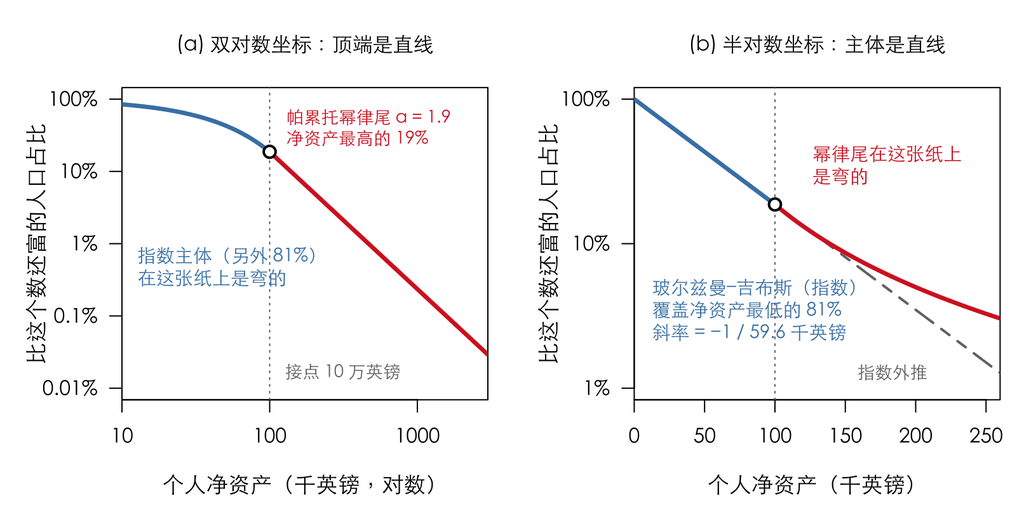

```r
## 重画 Drăgulescu–Yakovenko (2001) 报的英国 1996 年净资产两段拟合：
## 10 万英镑以下 N(w) = exp(-w/W)，W = 59.6 千英镑；以上 N(w) = N(100)·(w/100)^(-alpha)，alpha = 1.9。
## 画的是这两条**拟合律**，不是原文的数据点——参数取自原文，曲线由解析式生成。
ACC <- "#D62728"; BLU <- "steelblue"; GRY <- "gray45"
TW <- 59.6; WC <- 100; AL <- 1.9
NC <- exp(-WC/TW)                                  # 接点处的累计人口占比
## 这三个参数正文要引好几处，就地登记——此前正文各处是各写各的手写副本
reg("uk_scale", TW, "source", "§2.6 two_regimes",
    "D-Y 2001b：英国下层指数段的尺度参数（千英镑）｜1996｜个人净资产")
reg("uk_cut",   WC, "source", "§2.6 two_regimes", "同上：两段拟合的接点（千英镑）")
reg("uk_alpha", AL, "source", "§2.6 two_regimes", "同上：上层幂律的尾指数")
reg("uk_pU",    100*NC, "derived", "§2.6 two_regimes", "接点以上的人口百分比 = exp(-WC/TW)")
reg("uk_pctile",100*(1-NC), "derived", "§2.6 two_regimes", "接点落在第几百分位")
PL <- 100*(1 - NC); PH <- 100*NC                   # 接点两侧各占多少人口
Nw <- function(w) ifelse(w <= WC, exp(-w/TW), NC*(w/WC)^(-AL))
yat <- 10^(0:-4); ylb <- c("100%", "10%", "1%", "0.1%", "0.01%")

par(mfrow = c(1, 2), mar = c(4.6, 5.0, 3.6, 1.0), cex.lab = 1.08, cex.main = 1.0,
    family = "cjk")

## (a) 双对数：净资产高的那一段是直线
wl <- exp(seq(log(10), log(3000), length.out = 1500))
plot(wl, Nw(wl), type = "n", log = "xy", ylim = c(1e-4, 1), xaxs = "i",
     xaxt = "n", yaxt = "n", xlab = "个人净资产（千英镑，对数）",
     ylab = "比这个数还富的人口占比", main = "(a) 双对数坐标：顶端是直线")
axis(1, at = c(10, 100, 1000), labels = c("10", "100", "1000"))
axis(2, at = yat, labels = ylb, las = 1)
lines(wl[wl >= WC], NC*(wl[wl >= WC]/WC)^(-AL), lwd = 3.4, col = ACC)
lines(wl[wl <= WC], exp(-wl[wl <= WC]/TW),      lwd = 3.4, col = BLU)
abline(v = WC, lty = 3, col = GRY)
points(WC, NC, pch = 21, bg = "white", col = "black", cex = 1.3, lwd = 2)
text(107, 0.34, sprintf("帕累托幂律尾 α = 1.9\n净资产最高的 %.0f%%", PH),
     col = ACC, pos = 4, cex = 0.86)
text(10.5, 0.004, sprintf("指数主体（另外 %.0f%%）\n在这张纸上是弯的", PL),
     col = BLU, pos = 4, cex = 0.92)
text(105, 1.6e-4, "接点 10 万英镑", col = GRY, pos = 4, cex = 0.86)

## (b) 半对数：净资产低的那一段是直线
ws <- seq(0, 260, length.out = 800)
plot(ws, exp(-ws/TW), type = "n", log = "y", ylim = c(1e-2, 1), xaxs = "i", yaxt = "n",
     xlab = "个人净资产（千英镑）", ylab = "比这个数还富的人口占比",
     main = "(b) 半对数坐标：主体是直线")
axis(2, at = 10^(0:-2), labels = c("100%", "10%", "1%"), las = 1)
lines(ws, exp(-ws/TW), lty = 2, lwd = 2, col = GRY)          # 指数外推，作参照
lines(ws[ws >= WC], Nw(ws[ws >= WC]),   lwd = 3.4, col = ACC)
lines(ws[ws <= WC], exp(-ws[ws <= WC]/TW), lwd = 3.4, col = BLU)
abline(v = WC, lty = 3, col = GRY)
points(WC, NC, pch = 21, bg = "white", col = "black", cex = 1.3, lwd = 2)
text(4, 0.030, sprintf("玻尔兹曼–吉布斯（指数）\n覆盖净资产最低的 %.0f%%\n斜率 = −1 / 59.6 千英镑", PL),
     col = BLU, pos = 4, cex = 0.92)
text(118, 0.32, "幂律尾在这张纸上\n是弯的", col = ACC, pos = 4, cex = 0.92)
text(150, 0.0125, "指数外推", col = GRY, pos = 4, cex = 0.86)
```

```r
## 自检：接点连续，且远端幂律必须压过指数外推（两条律在接点附近几乎相切，检查放到 200 以外）
stopifnot(abs(Nw(WC) - exp(-WC/TW)) < 1e-12,
          all(Nw(seq(200, 3000, by = 1)) > exp(-seq(200, 3000, by = 1)/TW)))
```

这张图画的是那两条拟合律本身，不是原文的数据点——原文把英国税务局的实测点直接叠在这两条线上。要紧的只有一件事：同一条曲线，在两张纸上各有一段是直的。

顺带说清一件容易误会的事：接点在人口里的位置不是固定的。英国的财富数据上它落在第 81 百分位，而下面那张美国收入的图上要到第 96 百分位左右。按财富排队时，幂律那一段来得早得多——这本身就是一条信息：同一个社会，用财富看到的“少数人”，比用收入看到的宽好几倍。所以本文里的“主体 / 尾巴”指的始终是两段机制，不是某个固定的百分比。

而同一篇文章里顺手记的一笔，正好是本文的主线。纯指数分布的基尼系数恒为 0.50；而英国税务局给出的实际财富基尼，1984 年是 0.64、1996 年是 0.68 (Drăgulescu and Yakovenko 2001b)。中间这十几个基尼点，主要来自顶端那条幂律尾——原文正是这样解释实测 Lorenz 曲线为什么系统性地偏离纯指数那条线的。本文剩下的篇幅做的就是这件事：先把 0.50 这一份说清楚，再逐个去找加出来的那些。

既然两段都有了参数，这个基尼就可以拆开看——拆出来的东西比那个总数有意思。

**两段拼接在统计学里叫什么（可跳过）**

这种”各管一段”的构造有名字：**拼接分布**（spliced distribution），两段的特例叫**复合分布**（composite distribution）——保险精算里研究得最多的是复合对数正态–Pareto，用来同时拟合大量小额赔款与少数巨额赔款 (Cooray and Ananda 2005; Scollnik 2007)；极值理论里同一个构造叫**阈值超越**（peaks-over-threshold）：阈值以下用一个体分布，以上用广义 Pareto。

顺带把一个容易混的说法钉一下：拼接不是”两个分布相加”。相加是**混合**，两个成分各自铺满整个取值范围、按权重叠加；拼接是各管一段、互不重叠。下面那个精确分解依赖的正是不重叠——若换成混合，恒等式就会多出残差项。

两段是按财富排序不重叠的：接点以下全归一段，以上全归另一段。这种情况下基尼有一个精确的分解，没有残差项——

$$G \;=\; p_L s_L G_L \;+\; p_U s_U G_U
\;+\; (p_L - s_L)$$

前两项是组内：每一段自己有多不平等。第三项是组间：顶端多拿了多少。

$p$ 是人口占比，$s$ 是财富占比，下标 $L$ 指主体那一段、$U$ 指顶端那一段。注意组内那两项的权重是 $p \cdot s$，不是人口占比——这一点马上就会看出要紧。

**切点为什么可以随问题换（可跳过）**

切点是一个选择，而且这个恒等式对任何切点都成立。这里切在 10 万英镑，是因为本节要说的正是“两段 = 两套机制”，而那里正是机制换挡的地方。换个问题就该换个切点：第 4.1 节会给出另一个自然的切点——让组间项取到最大的那一点，它落在“财富恰好等于均值”的分位上，不含任何拟合参数。同一条恒等式，切点编码的是你在问什么。

```r
## 把上面那两条拟合律的基尼精确拆开。两段按财富排序互不重叠，所以分解无残差项。
## 尾部是纯 Pareto，组内基尼有闭式 1/(2α−1)；主体是截断在 wc 处的指数，数值积分。
sL_ <- (TW*(1 - NC*(1 + WC/TW)))                       # 主体持有的财富（未归一）
sU_ <- AL*NC*WC/(AL - 1)                               # 尾部持有的财富（α>1 才收敛）
mu_ <- sL_ + sU_; sL <- sL_/mu_; sU <- sU_/mu_         # 两段各自的财富占比
pL <- 1 - NC; pU <- NC                                 # 两段各自的人口占比

gini_trunc_exp <- function(TT, hi, n = 2e5){           # 截断指数的基尼，数值积分
  x <- seq(0, hi, length.out = n); f <- dexp(x, 1/TT); f <- f/sum(f)
  cw <- cumsum(f); cx <- cumsum(f*x)/sum(f*x)
  1 - sum((cx[-1] + cx[-n])*diff(cw))
}
GL <- gini_trunc_exp(TW, WC); GU <- 1/(2*AL - 1)
Gwin <- pL*sL*GL + pU*sU*GU; Gbtw <- pL - sL; Gtot <- Gwin + Gbtw

## 验一遍：直接从拼接分布抽样求基尼，必须和分解式对上
set.seed(7); u <- runif(4e5)
xs <- ifelse(u < pL, -TW*log(1 - u), WC*((1 - u)/NC)^(-1/AL))
stopifnot(abs(gini(xs) - Gtot) < 0.005)
## 主体那一段的条件均值：指数截断在 WC 处，E[W|W<WC] = TW - WC/(exp(WC/TW)-1)。
## 尺度参数 TW 只有在**不截断**时才等于均值——正文那条口径提醒就靠这个数。
uk_body_mean <- TW - WC/(exp(WC/TW) - 1)
stopifnot(uk_body_mean < TW)                     # 截断必然把条件均值压到尺度以下
reg("uk_body_mean", uk_body_mean, "analytic", "§2.6 gini_decomp",
    "主体（截断在 10 万英镑的指数）的条件均值，千英镑；与尺度参数 59.6 不是一个量")
reg("uk_decomp_between", Gbtw, "analytic", "§2.6 gini_decomp", "组间项 = 顶端份额减人口份额")
reg("uk_decomp_within",  Gwin, "analytic", "§2.6 gini_decomp", "两段组内之和")
```

| 分项 | 人口占比 p | 财富占比 s | 本段基尼 G | 进入总基尼的量 p·s·G |
| --- | --- | --- | --- | --- |
| 主体（指数段，L） | 81.3% | 43.0% | 0.416 | 0.146 |
| 顶端（幂律段，U） | 18.7% | 57.0% | 0.357 | 0.038 |
| 组内合计 | — | — | — | 0.184 |
| 组间：顶端多拿的 | — | — | — | 0.383 |
| 合计 | 100% | 100% | — | 0.567 |

表里前两行就是公式里那六个量：$p_L,p_U$ 在“人口占比 p”一列，$s_L,s_U$ 在“财富占比 s”一列，$G_L,G_U$ 在“本段基尼 G”一列；最后一列是三者相乘之后真正进入总基尼的那一份。“组内合计”是前两行最后一列相加；“组间”那一行就是 $p_L-s_L$，即主体那一行的人口占比减去它的财富占比（81.3% − 43.0%）。

三个数里只有最后一个要紧。尾巴自己内部有多不平等（$G_U = 0.36$）几乎不起作用——它的权重只有 $p_U s_U = 0.11$，乘完只贡献 0.04。两段的组内加起来 0.18，而组间一项就是 0.38，占了总量的 68%。

翻译成人话：“顶端有多不平等”不重要，“顶端拿走多少”才重要。而组间那一项字面上就是这个数——$p_L - s_L = s_U - p_U$，尾巴拿走的财富份额，超出它人头份额的部分：57% 减 19%。一个数，不用估任何参数，而且可解释。

（一句口径提醒：这里算的是那两条拟合律的基尼 0.57，税务局对原始数据报的是 0.68。两者不是同一个量——一个是两条理想曲线的积分，一个是有覆盖缺口的原始统计。这 0.11 的差别不要当成“某个机制”来读。）

真实数据长什么样，可以直接看原图。下面是同一套做法在美国个人收入上的结果——1983–2018 年三十五年、全部报税记录 (Ludwig and Yakovenko 2022)：

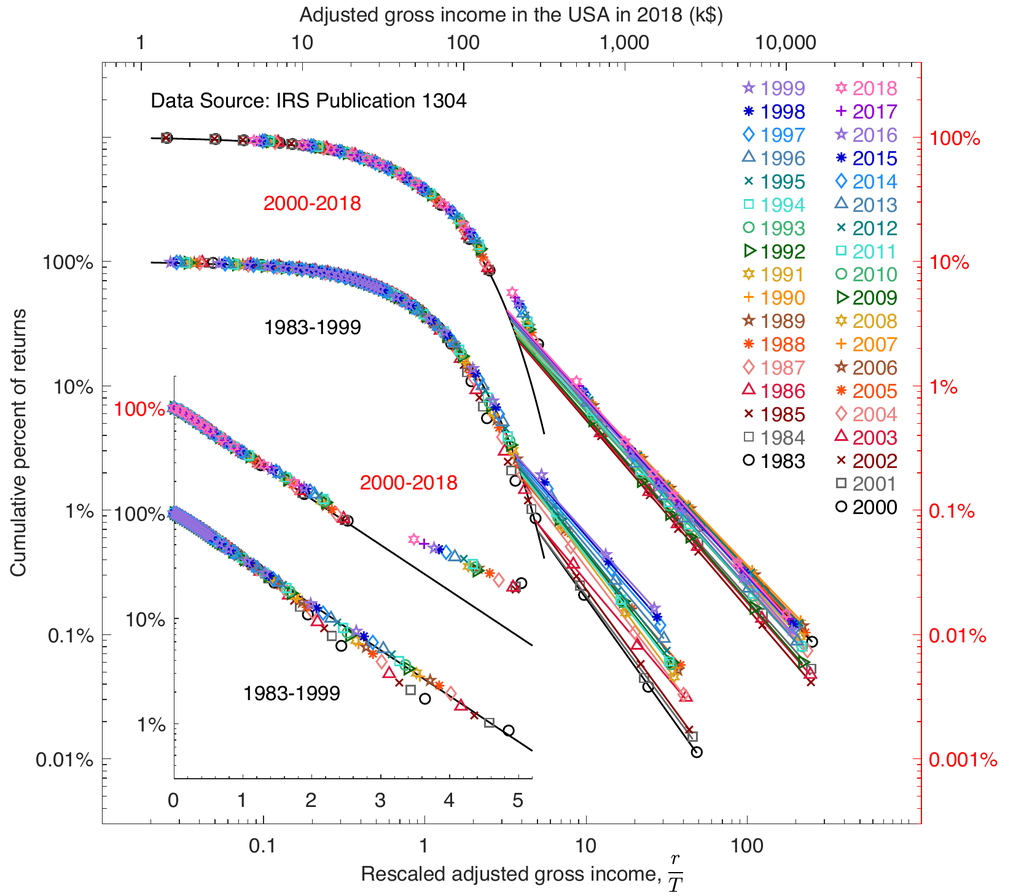

美国个人收入的累计分布，1983–2018 年，数据源为 IRS Publication 1304。大图是双对数坐标（幂律尾在这里是直线），内嵌小图是半对数坐标（指数主体在这里是直线）；各年数据按当年的尺度参数缩放后叠合在一起。图片来源：[Yakovenko (2023)](https://arxiv.org/abs/2307.02470) 图 2 左栏，[CC BY 4.0](https://creativecommons.org/licenses/by/4.0/)；该图原载 [Ludwig 与 Yakovenko (2022)](https://doi.org/10.1098/rsta.2021.0162)。

注意这换成了收入口径——它为什么不能拿来印证本文的财富基线，第 4.4 节专门讲。但形状上的信息很硬：三十五年的点，各自按当年的尺度缩放之后叠在同一条曲线上；内嵌小图那条半对数直线是指数主体（2018 年约占 96% 的人），大图那条双对数直线是幂律尾（约 4%）。Yakovenko 由此下过一个很硬的判断：数据里只有两个阶级，中产阶级并不作为第三段存在——他同时指出，文献里对“中产阶级”本来就没有公认定义，每个写它的人都自带一套 (Yakovenko 2023)。

它的实证成绩，上面已经看过两条——英国 1996 年的净资产 (Drăgulescu and Yakovenko 2001b)、美国 1983–2018 年的个人收入 (Drăgulescu and Yakovenko 2001a; Ludwig and Yakovenko 2022)，主体都是指数。这里补第三条，也是最能说明问题的一条：这个形状后来被推到了 67 个国家。Tao 等人用统一口径重做，发现指数主体不是英美两国的巧合，而是各国共有的形状——把每个国家的收入按它自己的尺度参数归一化之后，一国一条，在半对数坐标上条条都是直线 (Tao et al. 2019)：

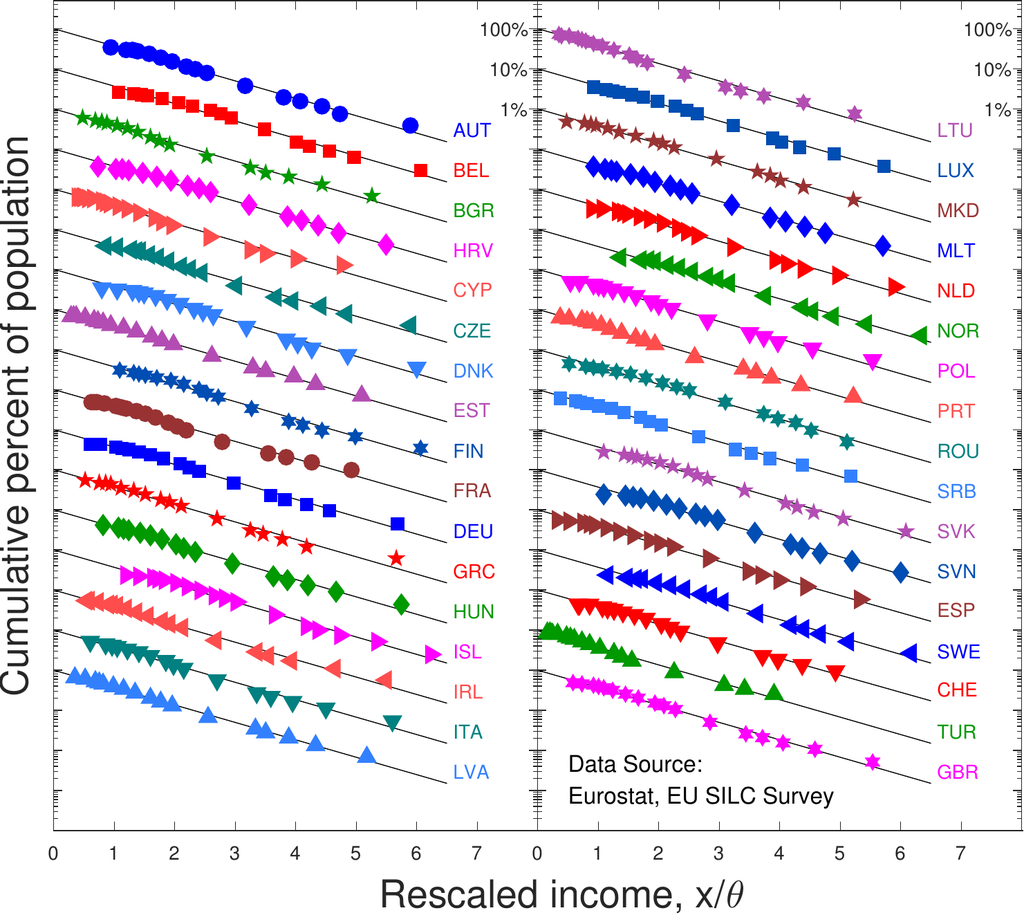

欧盟及其周边国家 2014 年的收入累计分布，数据源为 Eurostat EU-SILC 调查。纵轴对数、横轴线性，收入按各国自己的尺度参数归一化，各国曲线纵向错开显示；每一条都是直线，即指数分布。图片来源：[Yakovenko (2023)](https://arxiv.org/abs/2307.02470) 图 1 左栏，[CC BY 4.0](https://creativecommons.org/licenses/by/4.0/)；该图原载 [Tao 等 (2019)](https://doi.org/10.1007/s11403-017-0211-6)。

这张图值得停一下，因为它换掉了一个常见的读法：各国的收入水平、税制、工会密度、福利制度差得很远，主体那一段的函数形状却各国相同，都是指数。

但形状相同不等于不平等程度相同，这一步不能跳。Tao 等人拟合的其实是**位移指数分布**：比纯指数多一个位置参数，可以读成一条收入地板。多了这个参数，这一段的基尼就不再恒等于 $1/2$，而是随“地板高出尺度多少”变化——原文自己就把这个比值当作政策可以拧的东西讨论，并据此建议适度提高失业救济水平 (Tao et al. 2019)。所以正确的说法是：制度差异改变的是这两个参数，而不是这一段的函数形状。

**位移指数分布的密度与基尼，以及半对数斜率量的到底是什么（可跳过）**

密度是 $f(x)=\theta^{-1}e^{-(x-\mu)/\theta}\ (x\ge\mu)$：除了尺度 $\theta$，还有一个位置参数 $\mu$。半对数图上那条直线的斜率是 $-1/\theta$，即尺度的负倒数；只有在 $\mu=0$ 时它才等于均值的负倒数（一般地均值是 $\mu+\theta$）。而它的基尼是

$$G \;=\;
\frac{1}{2\,(1+\mu/\theta)}$$

只有 $\mu=0$ 才回到 $1/2$。

纯指数（$\mu=0$）那个特例才有下面这条干净的推论，而它值得单列出来，因为本文的基线正是这个特例：纯指数分布的基尼与尺度无关、恒为 $1/2$（第 4.1 节会算）。于是在 $\mu=0$ 的近似下，各国实测收入基尼的高低差异就落到顶端那一截上。Silva 与 Yakovenko 把这条关系写成了一个式子并拿美国税务数据验过——$G=(1+f)/2$，其中 $f$ 是流入 Pareto 尾的那部分收入占总收入的比例 (Silva and Yakovenko 2005)。$f=0$ 时基尼正好是 0.5。

$f$ 其实有两种算法，差别不大但不恒等。下面凡是引这个公式的地方，$f$ 一律指 $f_L$。

**两种 $f$ 差在哪，以及为什么取 $f_L$（可跳过）**

代错一个，基尼就差 0.06。原文说两种算法大体吻合，但并不恒等；Ludwig 与 Yakovenko 后来给了它们各自的记号 (Ludwig and Yakovenko 2022)：$f_r$ 是接点以上的实际收入份额，$f_L$ 是相对于把指数段外推到无穷所多出来的那部分。他们的式 3.7 用的是 $f_L$。

以 2018 年美国为例，$f_r=0.3378$ 给出 $G=0.6689$，$f_L=0.2172$ 给出 $G=0.6086$，而当年实测是 $0.6018$——用 $f_L$ 才对得上。

但这个公式有一处对不上，而且对不上的方向正好值得记下来。它在 1990 年代的 IRS 数据上拟合得很好，却抓不住 1980 年代——那几年实测的美国个人收入基尼在 0.5 以下。这一条是原作者自己交代的，原话是”$G$ 在 1980 年代低于 $1/2$ 这件事，我们的公式抓不住”(Silva and Yakovenko 2005; Chakrabarti et al. 2013)。而 $G=(1+f)/2$ 按构造恒 $\ge 0.5$，无论 $f$ 取什么值。所以 0.5 不是一堵实测意义上的地板：真实分布的主体可以比指数更平均一些，那时整条曲线就落到基线下方去了。本文把 0.5 当基线而不是当下界，这条经验证据是理由之一。

这几年落在哪个税制下，值得顺手记一笔——但只记时间，不记因果。同一份逐年参数里，实测基尼低于 0.5 的年份恰好是 1983–1986 这一段，1987 年首次越过（0.497 → 0.516）；而美国的最高边际税率正是在这前后连降几级。

**那几年的美国最高边际税率，逐年（可跳过）**

1965–1980 年是 70%，1981 年 69.125%，1982 年降到 50%，1987 年 38.5%，1988 年 28% (Wilson 2002)。

还有一条容易被忽略的：1972–1981 年劳动所得另有 50% 的上限，所以那个 70% 主要落在非劳动所得上。

本文在这里只报这个时间上的重合，不断因果。那一跳里有多少是分配真的变了、有多少只是申报行为跟着税率变了，第 6.1.3 节会摊开说——而且那里会看到，“高税率压低了不平等”这个读法过不了上面那条算术。

这个式子其实是上面那条精确分解的一个极限：它默认顶端只是一小撮人。用在美国收入上好使，搬到英国财富上就不行——这又是一处“两个口径不能互相印证”。

**$G=(1+f)/2$ 为什么是精确分解的极限，以及它搬到财富上差多少（可跳过）**

上面把基尼拆成“组内 + 组间”。当顶端的人口占比 $p_U\to 0$ 时，组间项趋于 $f$、组内项趋于 $\tfrac12(1-f)$，加起来正是 $(1+f)/2$。所以这个公式默认顶端是一小撮人。

美国收入数据上顶端约占 4%，近似成立；而英国财富数据上顶端占 18.7%，把 $f=$ 57% 代进去会得到 0.78，精确分解给的是 0.57——高了 0.22。

（同一批作者还把这套论证从统计物理翻译成了经济学的语言——用 Arrow–Debreu 一般均衡加上罗尔斯式的自由竞争公平条件重新推了一遍 (Tao et al. 2019)。）

## 2.7 那条缝落在多少钱上

回到上一节那张美国收入的两段图——它的结构在物理里出现过一次一模一样的。19 世纪末的黑体辐射也是这样：长波那一端被 Rayleigh–Jeans 定律拟合得极好，短波那一端被 Wien 定律拟合得极好，两条律各自在自己那半边精确、跨到另一半边就彻底崩掉——同一批数据，要两张纸、两条律才描得完。那张图是一样的结构：两段各自笔直，纵轴跨四个数量级，而且换一张纸才看得见另一段。

而类比还能再走一步：物理那边最后把两段缝成了一条律（Planck），这边也有人做了同一件事——Ludwig 与 Yakovenko 把“加性与乘性两种过程同时在跑”写成一个 Fokker–Planck 方程，稳态解在低端退化成指数、在高端退化成幂律，中间自然过渡 (Ludwig and Yakovenko 2022)。

但类比到这里必须拐个弯，而这个弯才是要紧的那一半。Planck 的统一是一个机制的两个极限：同一份辐射场，长波短波都是它，写成一条律之后“两条律”就不存在了。这里不是。低端和高端来自两种同时在跑、性质不同的过程：加性的那一份是工资（这个月多干一些，收入是加上一笔），乘性的那一份是资本（本金涨 3%，收入是乘一个系数）。所以那条插值式并没有把两个阶级化解掉，它做的恰好相反——它解释了为什么正好是两段，以及接缝该落在哪里：落在两份贡献相等的那个位置。Yakovenko 索性照物理命名，下层叫 thermal（热的），上层叫 superthermal（超热的）。

**那条插值式长什么样，为什么不是 Gamma，以及第 5 章为什么不走它（可跳过）**

它只用三个参数——下层的平均收入 $T$、尾指数 $\alpha$（它由乘性那一侧的漂移与扩散之比定，第 5.3 节会用到这一点）、以及两段的接点 $r_0$：

$$P(r)\;\propto\;\frac{e^{-(r_0/T)\arctan(r/r_0)}}{\bigl[1+(r/r_0)^2\bigr]^{(1+\alpha)/2}}$$

而这条式子 1895 年就被 Karl Pearson 写下来过——Pearson Type IV 分布，登在同一家期刊上 (Pearson 1895)。

为什么不用更眼熟的 Gamma？因为 Gamma 的尾巴仍然是指数的：在双对数纸上它一路变陡、是弯的，而上面那截数据是直的。更要命的理由在第 5 章。

还要交代一句，免得后面串线。第 5 章不走这条方程。它把加性那一份整个拿掉，只留乘性回报加合并劈分，看幂律尾能不能自己长出来——能，而且尾指数可以解析地解出来。两条路的关系，第 4.3 节那张表会点明：Kesten 那种“加一个托底项”是长出幂律尾的充分机制，不是必要的。

那这条缝落在多少钱上？有确切的数，但先得说清是哪种钱。下面两条线量的不是同一个量：美国那条量的是收入（IRS 报税口径的调整后总收入），英国那条量的是财富（净资产）。混起来会得出完全错误的结论，这正是本章开场立下的那条口径纪律。

美国收入，2018 年那条缝落在 185,202 美元。这个数不是从图上读的——Ludwig 与 Yakovenko 把逐年拟合出的参数随论文一起公开了，下面这张表就是其中 1983 与 2018 两行 (Ludwig and Yakovenko 2022)：

| 量（当年名义美元） | 1983 年 | 2018 年 |
| --- | --- | --- |
| 中位收入 | 15,046 | 40,712 |
| 下层平均收入 T | 20,593 | 57,453 |
| 全体平均收入 | 20,661 | 78,027 |
| 两段接点 r* | 103,673 | 185,202 |
| 接点 ÷ T | 5.03 倍 | 3.22 倍 |
| 接点 ÷ 中位收入 | 6.89 倍 | 4.55 倍 |
| 上层人口份额 | 0.68% | 4.08% |

几个可以直接对号入座的读法。2018 年这条线在 18.5 万美元上下——年收入十万美元的人处在第 82 百分位，还稳稳地待在指数那一段里，离缝还差着将近一倍；要跨过去，得挣到中位收入的 4.5 倍。而 1983 年这条线是 103,673 美元，是当年中位收入的 6.9 倍。

门槛在这四十年里相对地降下来了——接点从下层平均的 5.03 倍降到 3.22 倍，其中 1986 年前后有一次陡降，正好撞上里根政府的《1986 年税改法案》(Ludwig and Yakovenko 2022)。但这不是“上层变好进了”。门槛下降的同时，上层人口份额从 0.68% 涨到 4.08%——指数那一段在萎缩、幂律那一段在扩张。不是有人爬上去了，是那条律的地盘扩大了。

表里还藏着一句更直接的话，就在中间那两行。1983 年，全体平均收入（20,661 美元）和下层平均 $T$（20,593 美元）几乎相等——那时候整条分布基本就是一条指数，一个“平均收入”足以代表大多数人。到 2018 年，两者分成了 78,027 与 57,453 美元，而中位数只有 40,712。“平均工资”越来越不像大多数人的收入，差出来的那一截全部住在那条幂律尾里。

一句口径提醒。IRS 的统计单位是一份报税表，不是一个人；2018 年大约三分之一是夫妻合并申报，所以“个人收入”是个近似说法，原文明确交代过这一点 (Ludwig and Yakovenko 2022)。

英国财富，1996 年那条缝落在 10 万英镑——当年下层那段指数的尺度参数是 5.96 万英镑（条件均值只有 36.6 千英镑，因为主体被截断在 10 万），所以接点是尺度的 1.68 倍，落在第 81 百分位 (Drăgulescu and Yakovenko 2001b)。同一件事换个口径量，缝的位置差得很远：收入那条要到第 96 百分位才到，财富这条第 81 百分位就到了。

**倍数和百分位是怎么换算的，以及一次交叉验证（可跳过）**

因为下层是指数，两者可以直接接起来：接点在 $k$ 倍处，接点以上就还剩 $e^{-k}$ 的人。美国 2018 年 $k=3.22$，代进去得 3.98%，而原文独立数出来的上层人口份额是 4.08%——一条从拟合参数来，一条从数人头来，落到同一个地方。

所以回到问题本身：这不是“中产与资产阶级”的界线。按上一节那张美国收入图，中产不作为第三段存在——它整个泡在指数那一段里。真正的界线是加性与乘性的界线，也就是“收入主要来自劳动”与“收入主要来自资本”的界线。

说到这儿，有个流行的比喻突然变得精确了。罗伯特·清崎《富爸爸穷爸爸》整本书立在一句话上：穷爸爸为钱工作，富爸爸让钱为他工作。在上面那个方程里，这句话不是修辞，它字面上就是那两个项：为钱工作是加性项，让钱工作是乘性项。而这个比喻最精确的地方，恰恰在它说的是“两个爸爸”而不是“一根梯子”——通行的想象是贫富站在同一根梯子的不同高度，而数据说的是两套方程：下层的相对不平等三十六年几乎不动、并且始终是指数，上层是另一条律，而基尼系数的全部历史变动都来自上层那一份份额（第 2.6 节那条 $G=(1+f)/2$）(Ludwig and Yakovenko 2022)。

不过这本书没有资格说的那一半也要讲清。数据支持“存在两种动力学”，它不支持“每个人都能从一条切到另一条”——2018 年乘性那一侧只装了 4.1% 的人。本文认领的只是这个结构性判断，任何投资建议都不在其内。而如果真把乘性回报这个旋钮拧到人人都有，会发生什么？那正好是第 5 章的题目，答案不是人人变富。

那”我怎么从这一段走到那一段”？这一问本文答不了。要答它，得给模型装上把工资变成资本的那一步，而那个零件恰恰是第 5 章刻意拒绝的东西。缺的是什么、答案会是什么形状，折在下面。

**“怎么跨过去”：缺的是一条积累通道，以及判据到底卡在哪个数上（可跳过）**

先把两个容易混的量分开。上面报的 $r^*$ 是两段拟合的交点；而在那个 Fokker–Planck 里另有一个 $r_0=\sqrt{B_0/b}$，它是加性与乘性对波动的贡献相等的位置（扩散系数 $B(r)=B_0+br^2$）。原文把两者分列 (Ludwig and Yakovenko 2022)：2018 年 $r^*$ 是 185,202 美元，$r_0$ 是 167,094 美元，相差约 11%。下面这个机制判据说的是 $r_0$，不是 $r^*$。所以判据不是”资本收入超过工资收入”，而是你收入的起落主要由资产价格决定、而不再由工资决定——门槛比前者高得多。

真正缺的是一条积累通道。上面那个两段结构是**横截面**分解，说的是”此刻谁在哪一边”，对谁会移动一个字都没说；而第 5 章那个模型是**同质**的——人人同一个 $\sigma$，“在尾巴里”纯粹是当前手气，里面根本没有任何你可以做的事。要问”怎么跨”，就得给模型装上把工资变成资本的那一步，也就是 $K_{t+1}=A_tK_t+sw$ 这类带外生托底的乘性递推。而那个外生项正是第 5 章刻意拒绝的东西——那里要证的是”不外加任何东西也能长出幂律尾”，这里要问的却恰恰是那个外加项怎么把人推过去。同一个零件，两章要它的理由正好相反。

答案会是什么形状，倒是可以先说。这类递推的性质决定了：当对数回报的期望为负时存在平稳分布，跨过去是可以的，掉回来也是——它是个反复发生的事件，不是一道单向门，能算的只有”平稳状态下在门那边的概率”和”平均能待多久”；而当对数回报的期望为正时，人人最终都跨过去，可那正是第 5 章证明人口层面开始崩掉的区制。所以这一问不会有”做 X 就到”形式的答案。

至于把这条真装上去——它要引入储蓄率与回报波动两个没有校准依据的参数，而本文的立足点是零拟合参数的基线；何况”跨越概率”本质上是一个机会的量，属于公平那一侧。这一步因此留给姊妹篇《公平与效率：同一个温度》：那里已经有位次粘性这根轴、有”持久标签”那组对照实验，也已经就地论证过缺的这一块需要先给模型装上工资。

于是“财富分布是什么分布”这个问题，答案取决于你在看哪一段，而两段各由一套机制统治。本文两段都要走：先用两章推出主体那一段为什么是指数，再在第 5 章打开通往另一段的那道门——往模型里加进带涨落的乘性回报，也就是把“乘性”引进来，指数尾立刻变成幂律尾；而那一章不止给个形状，它把这条尾巴的指数 $\alpha_2(\sigma)$ 直接解出来。（更早还有一次预演：第 3.4 节把储蓄倾向改成因人而异，同一个交换模型也长出幂律尾。）

但这里有一个该被问的问题，而且它是对整个模型最要紧的一问。这座岛上没有工资——没有生产，没人挣钱，金币只是换手。可真实世界里，主体那一段的人绝大多数靠工资活着。一个没有工资的模型，凭什么把一个有工资的世界的财富形状算对？

答案在最大熵那一步的约束里，而它比”守恒”宽得多。第 3.3 节会把三条约束写出来：分布归一、均值被钉住、财富不能为负。里面没有”总量守恒”这一条——守恒只是把均值钉住的一种办法，这座岛用的那种。

现实里钉住它的是另一种办法：收支的长期平衡。一个人的财富是”收入减支出”在时间上的**累积残差**。工资再高，只要长期被支出大致抵掉，这个残差就没有系统性漂移；而这个残差往下有界（第 1.1 节那条不对称）。于是最大熵那三条约束齐了：均值被钉住、有下界、除此之外不多假设——剩下的唯一可能就是指数。工资的绝对大小决定的是尺度（那一段的人均财富），不是形状：高工资高消费的社会和低工资低消费的社会，主体那一段的形状可以一模一样。

**一句限定：钉住均值的不是”无漂移”，是人群这一层的收支相抵（可跳过）**

“无漂移”本身钉不住均值。钉住它的是收支在人群层面的平衡：单个人的财富若只有零漂移加一堵墙，离散度会一直长下去，不会稳定到任何分布。岛上那台机器靠的是总量守恒，现实里靠的是总收入与总支出相抵——两者都是在群体这一层钉住均值。

均值被钉住这一条写成式子就是 $\int_0^\infty x\,p(x)\,\mathrm{d}x=\mu$；第 3.3 节会把三条约束一起摆出来解。

于是”主体是指数”这件事，实测上等价于一句关于储蓄的话：对那 96% 的人，累积储蓄是一个不含”按财富复利”成分的小残差。反过来，一旦残差变成按财富成比例增值，形状立刻换成对数正态或幂律——那就是顶端，就是刚才说的乘性那一项。所以两段结构不是两个世界，而是同一句话的两侧：残差里有没有复利。

这也给上面那个说法一个可检验的形式，而证据已经在前面那张图里了。美国收入分布的主体三十五年一直贴着指数——这件事本身就是”对绝大多数人，财富的累积没有复利成分”的观测，不需要另去查储蓄率。

但这个答案只管财富那一侧，这一点必须说清。模型给不出”年收入”这个量：岛上的”收入”只是别人转过来的金币，它的基尼是核算窗口的函数（第 4.2 节量过，第 7.2 节把这条列为本文的模型边界之一）。能直接和数据对的输出只有一个：财富的分布形状。

留一条阅读提醒：以后再看到“财富分布是 X 分布”这种说法，先问它指的是主体还是尾巴。不区分这两段，两个都对的人也会吵起来。

# 3 第一题：为什么是指数分布

证明这一题有三条独立的路，从最短的走起：三行的细致平衡（不用熵、不用微积分）、数微观态（有限人数下精确）、最大熵（最抽象，但通用到能换出正态和幂律）。三条路给出同一个答案——这本身就是这个结论有多结实的证据。

先把两个名字的关系钉一下，免得后面来回跳：金币不可切分，所以精确的答案是几何分布 $p_n=(1-q)q^{\,n}$；把金币磨细、取连续极限，它就是指数分布 $p(x)=\frac1\mu e^{-x/\mu}$。前两条路直接给出几何分布，第三条路（最大熵）在连续版上做，给出指数分布。同一件事的离散版和连续版，差别只在金币的粗细——这个“粗细”值多少个基尼点，第 4 章末尾那个折叠里会精确算出来。

走完三条路，再动手拆模型：换个零件，看它稳不稳。而拆到最后一个零件时会掉出一条幂律尾——本章最后一节说明它为什么必然是幂律，用的还是同样那三台机器，只换一个坐标。

## 3.1 三行就够：细致平衡

盯住一个岛民手里的枚数 $n$，它在 $0,1,2,\dots$ 上做一维随机游走。“规则同质”这条前提直接给出关键的一句：上行和下行的速率，都与他手里已经有多少枚无关。

- 每一轮他都被配进某一对，当付款方的概率是 $1/2$ ⟹ 下行率 $=\tfrac12$；
- 他要收到一枚，需要对方当付款方、且对方手里不是空的 ⟹ 上行率 $=\tfrac12(1-p_0)$，其中 $p_0$ 是身无分文者所占的比例。

平稳态里，相邻两格之间的净流必须为零（**细致平衡**）：

$$p_n\cdot\tfrac12(1-p_0) \;=\;
p_{n+1}\cdot\tfrac12
\qquad\Longrightarrow\qquad
\frac{p_{n+1}}{p_n} \;=\; 1-p_0 \;\equiv\; q$$

比值与 $n$ 无关。这一句就是全部的答案：从任何一格往上走一格，人数都乘同一个常数 $q$。

这个比值有个物理画面。下行率比上行率多出 $\tfrac12 p_0$，而且对谁都一样、与手里有多少枚无关——像一个不随高度变化的重力，把所有人往 0 那边压，0 这堵墙再把人挡住。重力加地面，给出的正是空气密度随高度的指数衰减（[等温大气](https://nyuhuyang.github.io/notes/exp_normal_boltzmann_zh.html#%E7%89%A9%E7%90%86%E5%AE%9E%E4%BE%8B%E7%AD%89%E6%B8%A9%E5%A4%A7%E6%B0%94%E4%B8%8E%E6%94%BE%E5%B0%84%E6%80%A7%E8%A1%B0%E5%8F%98)）。弹簧是另一回事：拉力与离开平衡位置的距离成正比，给出的是正态分布。岛上没有弹簧，只有这份人人相同的“重力”。

把它一路展开，几何分布就掉出来了：

$$p_n \;=\; q\,p_{n-1} \;=\; q^2 p_{n-2}
\;=\;\dots\;=\; q^{\,n}p_0,
\qquad \sum_{n\ge0}p_n = 1 \;\Longrightarrow\; p_0 = 1-q
\qquad\Longrightarrow\qquad p_n=(1-q)\,q^{\,n}$$

而几何分布就是指数分布的离散版，把 $q^{\,n}$ 改写成 $e^{\,n\ln q}$ 一眼就能看见：人数随枚数按固定比例衰减——这正是“指数”二字的定义，不是别的分布的性质。

要把它写成连续的 $p(x)$，只需把一枚金币的面值记作 $\delta$、人均财富记作 $\mu$。由均值 $\sum_n n\,p_n=q/(1-q)=\mu/\delta$ 得 $q=\mu/(\mu+\delta)$，于是金币越磨越细时

$$\ln q \;=\;
-\ln\!\Bigl(1+\frac{\delta}{\mu}\Bigr)\;\xrightarrow[\ \delta\to0\
]{}\;-\frac{\delta}{\mu},
\qquad\text{从而}\qquad
p_n \;\propto\; e^{\,n\ln q} \;\longrightarrow\; e^{-x/\mu}$$

其中 $x=n\delta$ 是这个人的财富。归一之后就是 $p(x)=\frac1\mu e^{-x/\mu}$——第一题的答案，指数分布。

代回这座岛：$q$ 由人均金币定，$q/(1-q)=c=10$ 给出 $q=10/11$。也就是每多一枚金币，人数就少 9.1%——第 2.1 节那个选项 C 的措辞，到这里有了出处。

三行里还掉出一个漂亮的自洽：$q = 1-p_0$，而几何分布本身满足 $p_0 = 1-q$——几何比值恰好等于“没破产的人所占的比例”。模拟里破产者占 9.2%，理论值 $1/11=$ 9.1%。

把地板拆掉试试。上面那个比值里唯一带信息的量是 $p_0$，但要小心它在这里的身份。$p_0$ 是身无分文者的比例；它之所以出现在上行率里，是因为在这台机器上”手里没钱”和”付不出钱”恰好是同一件事。假如岛上有了信贷、财富可以记成负数，这两件事就分家了——付款失败的概率归零（身无分文的人照样存在，只是不再构成障碍），上行率与下行率于是都等于 $\tfrac12$。

这时平稳性要求的是

$$\pi_j \;=\; \tfrac12\pi_{j-1} +
\tfrac12\pi_{j+1}$$

也就是 $\pi_j$ 沿 $\dots,-2,-1,0,1,2,\dots$ 是一条**仿射数列**。而仿射数列里既非负又可和的只有恒零——没有平稳态。这时每个人的财富就是初始持币加上他的净胜局数（不再有交易因为对方空手而作废），一个无约束的 $\pm1$ 随机游走：离散度按 $\sqrt{n}$ 一路长，永不收敛。

```r
## 把地板拆掉的对照：同一台机器、同一颗种子（seed = 4），唯一的改动是去掉"手里没钱就不付"。
## 两边都是单次实现，逐项可比——不拿渐近期望去对单次实现。
NR <- length(G$traj) - 1; NP <- length(G$w); c0 <- G$snaps[["0"]][1]
qg <- c0/(c0 + 1)                                  # 几何比值 q = 10/11

## (a) 有墙：几何分布标准差的闭式 sqrt(q)/(1-q)
wall_sd <- sqrt(qg)/(1 - qg)
stopifnot(abs(wall_sd - sd(G$w)) < 0.5)            # 闭式必须对上实测

## (b) 无墙：跑真模型。人人恒收付 ±1，财富 = c0 + 净胜局数，可以为负
nowall <- function(N = NP, coins = c0, rounds = NR, seed = 4){
  set.seed(seed); w <- rep(coins, N); half <- N/2
  for (r in 1:rounds){ idx <- sample.int(N); i <- idx[1:half]; j <- idx[(half + 1):N]
    w[i] <- w[i] - 1L; w[j] <- w[j] + 1L }
  w }
wn <- nowall()
stopifnot(sum(wn) == NP*c0)                        # 总量照样守恒，变的只是下界
stopifnot(abs(sd(wn)/sqrt(NR) - 1) < 0.2)          # 离散度应落在解析值 sqrt(n) 附近

## (c) 撞墙频率：反射原理，对称游走自 c0 出发首次触 0
hit <- function(n, d = c0){ k <- (n - d)/2
  2*pbinom(ceiling(k) - 1, n, 0.5) + if ((n - d) %% 2 == 0) dbinom(k, n, 0.5) else 0 }
nowall_hit_med <- which(sapply(1:2000, hit) >= 0.5)[1]

## 自检：反射原理要对上直接模拟（5000 条 400 步的无墙路径）
set.seed(11)
mn <- apply(matrix(sample(c(-1L, 1L), 5000*400, TRUE), 5000, 400), 1,
            function(s) min(cumsum(s)))
stopifnot(abs(mean(mn <= -c0) - hit(400)) < 0.02)

## 三个设定值已在 §2.2 island_params 登记；这里只核对模型确实按那组值跑了
stopifnot(NR == REG$island_rounds$v, NP == REG$island_N$v, c0 == REG$island_c0$v)
reg("wall_sd",        wall_sd,         "analytic", "§3.1 no_wall", "有墙：几何 q=10/11 的标准差闭式")
reg("wall_max",       max(G$w),        "point",    "§3.1 no_wall", "有墙 seed=4 单次实现的首富")
reg("nowall_sd_th",   sqrt(NR),        "analytic", "§3.1 no_wall", "无墙的解析离散度 sqrt(轮数)")
reg("nowall_sd",      sd(wn),          "point",    "§3.1 no_wall", "无墙 seed=4 单次实现的标准差")
reg("nowall_max",     max(wn),         "point",    "§3.1 no_wall", "无墙 seed=4 单次实现的首富")
reg("nowall_min",     min(wn),         "point",    "§3.1 no_wall", "无墙 seed=4 单次实现里欠得最深的")
reg("nowall_debt",    100*mean(wn < 0),"point",    "§3.1 no_wall", "无墙跑完收在负数的岛民百分比")
reg("nowall_ratio",   max(wn)/max(G$w),"derived",  "§3.1 no_wall", "同种子下 无墙首富 / 有墙首富")
reg("nowall_hit_med", nowall_hit_med,  "analytic", "§3.1 no_wall", "无墙自 c0 出发首次触 0 的中位轮数")
reg("nowall_hit_all", 100*hit(NR),     "analytic", "§3.1 no_wall", "无墙跑完全程至少归零一次的百分比")
```

差多远，把同一台机器、同一颗种子跑一遍就知道——唯一的改动是拆掉那堵墙：

- 有墙（本文模型）：财富的标准差 10.5 枚（几何分布的闭式），跑完 30000 轮的首富 71 枚，没有人为负。
- 无墙：标准差 181 枚（解析值 $\sqrt{n}=$ 173，还在长），首富 640 枚，欠得最深的那个欠了 550 枚，48% 的岛民收在负数。

同一颗种子、同一批随机配对，首富差了 9 倍，而两套规则的全部差别只是”没钱能不能付”这一句。

而墙被撞到的频率高得超出直觉。从 10 枚出发，用反射原理算首次触 0 的时刻：中位数只有 220 轮；跑完全程，95% 的岛民至少归零过一次。0 不是模型边上偶尔才生效的边界条件，它是这台机器每一轮都在使的力——分布的形状正是它一次次压出来的。

这条路的代价：它把“对方能不能付款”换成了全岛的平均比例（平均场近似），而且只对这一条具体的交换规则有效——换个交换方式就得重推一遍。有限人数下精确的答案要靠数微观态，见第 3.2 节；两者在人多时一致。

## 3.2 数一数：穷的方式比富的多

上一节那三行给出了答案，代价是用了平均场近似。这一节换一条完全不同、而且有限人数下精确的路：直接数。它还顺带说明一件事——根本不需要动力学：不用等很多年，把金币随机撒下去，答案就已经在那儿了。

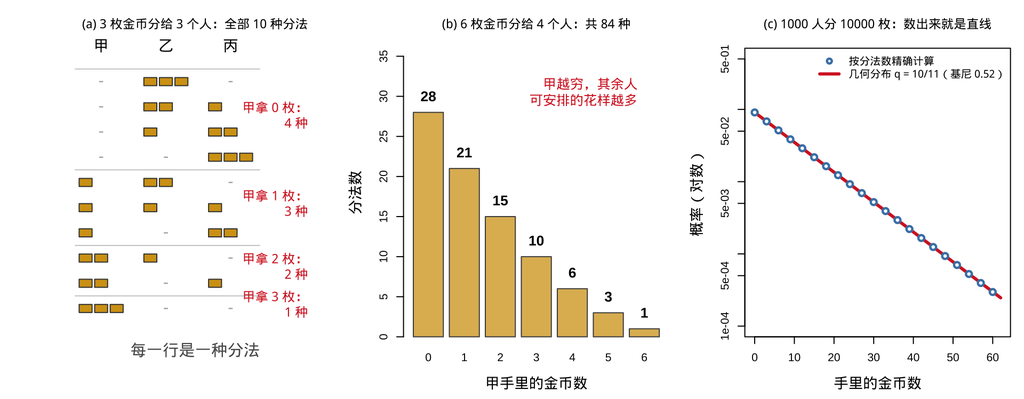

```r
GOLD <- "#D4A017"; ACC <- "#D62728"
par(mfrow = c(1, 3), mar = c(4.6, 4.6, 3.6, 1.0), cex.lab = 1.3, cex.main = 1.12)

## (a) 3 枚金币分 3 个人：把全部 10 种分法逐个画出来
comp <- as.matrix(expand.grid(A = 0:3, B = 0:3, C = 0:3)); comp <- comp[rowSums(comp) == 3, ]
comp <- comp[order(comp[, "A"], -comp[, "B"]), ]
R <- nrow(comp)
plot(NA, xlim = c(0.55, 4.35), ylim = c(0.3, R + 0.9), axes = FALSE,
     xlab = "", ylab = "", main = "(a) 3 枚金币分给 3 个人：全部 10 种分法")
axis(3, at = 1:3, labels = c("甲", "乙", "丙"), tick = FALSE, line = -1.4, cex.axis = 1.35)
for (r in 1:R){
  y <- R - r + 1
  for (j in 1:3){
    cnt <- comp[r, j]
    if (cnt == 0) text(j, y, "-", col = "gray70", cex = 1.5)
    else rect(j - 0.34 + (0:(cnt-1))*0.24, y - 0.16, j - 0.34 + (0:(cnt-1))*0.24 + 0.20, y + 0.16,
              col = GOLD, border = "gray25")
  }
}
grp <- table(factor(comp[, "A"], levels = 0:3))
ytop <- R
for (n in 0:3){
  k <- grp[as.character(n)]
  segments(0.6, ytop + 0.5, 3.45, ytop + 0.5, col = "gray80")
  text(4.3, ytop - k/2 + 0.5, sprintf("甲拿 %d 枚：\n%d 种", n, k),
       col = ACC, cex = 1.15, font = 2, pos = 2)
  ytop <- ytop - k
}
mtext("每一行是一种分法", side = 1, line = 0.6, cex = 0.95, col = "gray35")

## (b) 6 枚分 4 个人：分法数一路递减
ways <- choose(6 - (0:6) + 2, 2)
bp <- barplot(ways, names.arg = 0:6, col = adjustcolor(GOLD, .75), border = "gray30",
              ylim = c(0, 36), xlab = "甲手里的金币数", ylab = "分法数",
              main = sprintf("(b) 6 枚金币分给 4 个人：共 %d 种", sum(ways)))
text(bp, ways + 2, ways, font = 2, cex = 1.25)
text(bp[7], 30, "甲越穷，其余人\n可安排的花样越多",
     col = ACC, cex = 1.2, pos = 2)

## (c) 人一多就成一条直线
Nn <- 1000; Mm <- 10000; nn <- 0:60
exact <- exp(lchoose(Mm - nn + Nn - 2, Nn - 2) - lchoose(Mm + Nn - 1, Nn - 1))
plot(NA, xlim = c(0, 62), ylim = c(1e-4, .5), log = "y",
     xlab = "手里的金币数", ylab = "概率（对数）",
     main = "(c) 1000 人分 10000 枚：数出来就是直线")
curve((1/11)*(10/11)^x, add = TRUE, col = ACC, lwd = 3)
points(nn[seq(1, 61, 3)], exact[seq(1, 61, 3)], pch = 21, bg = "white",
       col = "steelblue", lwd = 2.2, cex = 1.15)
legend("topright", c("按分法数精确计算", "几何分布 q = 10/11（基尼 0.52）"),
       col = c("steelblue", ACC), pch = c(21, NA), pt.bg = "white",
       lwd = c(2.2, 3), lty = c(NA, 1), bty = "n", cex = 0.95)
```

图 (a) 是最小的可手数版本：3 枚金币分 3 个人，一共 10 种分法，全画在那里——甲一枚不拿有 4 种，甲独占 3 枚只有 1 种。穷的方式比富的方式多，这就是全部的原因。图 (b) 换成 6 枚分 4 个人，同一个形状放大：28、21、15、10、6、3、1。

把 6 枚（互相不可区分的）金币分给 4 个人，一共有 $\binom{9}{3} = 84$ 种分法。让这 84 种等概率——这是“完全公平”的最强版本：不偏袒任何一种结果。数一数其中甲手里有 $n$ 枚的各有多少种：

```r
N <- 4; M <- 6
comp <- expand.grid(rep(list(0:M), N)); comp <- comp[rowSums(comp) == M, ]
tab  <- table(factor(comp[[1]], levels = 0:M))       # 甲手里有 n 枚的分法数
rbind(`甲手里 n 枚` = 0:M, `分法数` = as.integer(tab),
      `占比`        = round(as.numeric(tab)/nrow(comp), 3))
```

```
##               [,1]  [,2]   [,3]   [,4]  [,5]  [,6]  [,7]
## 甲手里 n 枚  0.000  1.00  2.000  3.000 4.000 5.000 6.000
## 分法数      28.000 21.00 15.000 10.000 6.000 3.000 1.000
## 占比         0.333  0.25  0.179  0.119 0.071 0.036 0.012
```

```r
## 人一多就是精确的几何分布：1000 个岛民分 10000 枚金币
N <- 1000; M <- 10000
rbind(`精确计数`   = round(sapply(0:6, function(n)
        exp(lchoose(M-n+N-2, N-2) - lchoose(M+N-1, N-1))), 4),
      `几何 q=10/11` = round((1/11) * (10/11)^(0:6), 4))
```

```
##                [,1]   [,2]   [,3]   [,4]   [,5]   [,6]   [,7]
## 精确计数     0.0908 0.0826 0.0751 0.0683 0.0621 0.0564 0.0513
## 几何 q=10/11 0.0909 0.0826 0.0751 0.0683 0.0621 0.0564 0.0513
```

分法数是 28, 21, 15, 10, 6, 3, 1，一路递减。原因只有一句：甲拿得越少，剩下的钱留给另外三个人分的花样就越多（甲拿 $n$ 枚，其余三人分 $6-n$ 枚的方式有 $\binom{6-n+2}{2}$ 种，正是这串数）。

所以：“穷”不是被谁打败的结果，是实现方式最多的那个状态。不平等在这里是个组合计数事实，跟能力、努力、竞争一概无关。

这也就把第 1 章欠下的那一问答完了——运气为什么不正负抵消。均值确实抵消：每个人的期望财富一直是 1.5 枚。但分布的形状不由均值决定，由这串 28、21、15、10、6、3、1 决定——搅拌会走遍所有分法，落在哪一档的概率正比于那一档有多少种分法，于是这串计数本身就是财富分布的形状。运气不是围着均分上下摆的噪声，它撞着“不能为负”这堵墙，长期跑下来就沉淀成一条基线。

这条计数不只对金币成立。托尔斯泰在《安娜·卡列尼娜》开篇写过一句：“幸福的家庭都是相似的，不幸的家庭各有各的不幸。” 这句话常被当作文学修辞，但它其实是同一条计数，只是把金币换成了人生。

想想“富裕”要求什么：一连串关键节点上的选择都得对——生在什么地方、受什么教育、进哪个行业、什么时候置产、婚姻是否稳定、有没有踩中一次大的风险、健康有没有出岔子……这些条件必须同时成立，它是一个交集。而“没富起来”只需要其中任意一条不成立——它是一个并集。

交集稀少，并集广阔，和上面数金币是一模一样的道理：设有 $k$ 个大致独立的关键节点、每个的通过率是 $p$，“全部通过”的概率是 $p^k$，随节点数急剧变小；而“至少错一处”的走法随 $k$ 迅速膨胀。成功的配方少，失败的配方多。上面那张图里“甲拿 0 枚有 28 种分法、拿 6 枚只有 1 种”，说的就是这件事——只不过那里的“节点”是金币的去向，这里的“节点”是人生的岔路。

（这条原则后来被 Jared Diamond 借去解释另一件事：为什么全世界能被驯化的大型动物那么少——一个物种得同时满足食性、生长速度、繁殖习性、性情、应激反应、社群结构六项条件，缺一不可 (Diamond 1997)。它因此被叫做“安娜·卡列尼娜原则”。）

人一多，这件事收敛成精确的指数律。$N$ 人分 $M$ 枚、每种分法等概率时，

$$P(n) \;=\;
\frac{\dbinom{M-n+N-2}{N-2}}{\dbinom{M+N-1}{N-1}}
\;\xrightarrow[\;N,\,M\,\to\,\infty\;]{}\; (1-q)\,q^{\,n},
\qquad q=\frac{c}{c+1},\quad c=\frac{M}{N}$$

即**几何分布**——指数分布的离散版。上面第二段代码验的就是这一步：1000 个岛民分 10000 枚金币，精确计数给出的正是 $q=10/11$ 的几何分布，和岛屿模拟的结果一致。

这里有一个该被问到的技术问题：凭什么每一种分法的概率都一样？这条假设是上面整串计数的全部根据——把它换掉，答案立刻就变。而它不是从“金币都长一个样”推出来的：金币当然彼此没有区别，但那件事本身给不出等概率。给出等概率的是规则的对称性——这条交换规则不偏袒任何人，也不追踪任何一枚金币的来历，于是它对状态的唯一区分就只剩“每个人手里有几枚”，等权重也就只能落在分法上。

第 3.1 节走的是完全不同的一条路（细致平衡，只看进出流量相等），得到的是同一个答案。两条独立的路对上，才是这条假设站得住的真正理由。

这里数出来的东西有个名字。上面那个“某种人数配置能由多少种具体分法实现”的数目，就是**微观态数** $W$；而把它取对数、除以人数，得到的正是熵：

$$\frac{1}{N}\ln W \;=\; -\sum_i p_i \ln
p_i \;=\; H[p]$$

推导只用到 Stirling 展开阶乘，是纯代数，不影响这一节的结论——所以放在折叠里，不想看可以直接跳过。要紧的是这个身份本身：熵不是谁定义出来的，是数出来的；“熵最大”和“实现方式最多”是同一句话。下一节（最大熵）整段都建立在这条身份上。

**三行 Stirling：把”分法数”变成”熵”（可跳过）**

把 $N$ 个人按“手里有多少金币”分组，第 $i$ 组 $N_i$ 人，$p_i = N_i/N$。这种人数配置能由多少种具体的人–金币对应方式实现？就是多项式系数 $W = N!/\prod_i N_i!$。取对数，用 $\ln N! \approx N\ln N - N$：

$$\begin{aligned}
\ln W &= \ln N! - \sum_i \ln N_i! \\[2pt]
&\approx \bigl(N\ln N - N\bigr) - \sum_i \bigl(N_i\ln N_i -
N_i\bigr)
&& \text{Stirling} \\[2pt]
&= N\ln N - \sum_i N_i\ln N_i
&& \textstyle\sum_i N_i = N\text{，两个 } -N \text{ 抵消}
\\[2pt]
&= -\sum_i N_i\ln\frac{N_i}{N} \;=\; -N\sum_i p_i\ln p_i
&& \textstyle N\ln N = \sum_i N_i\ln N
\end{aligned}$$

两边除以 $N$ 即得 $\frac1N\ln W = H[p]$ ∎

因为 $W$ 是 $N$ 的指数量级，$H$ 差一点点，$W$ 就差好几个数量级——这正是“最大熵态压倒性地更可能”的来源。（前一篇有更完整的版本和数值验证：[计数论证：熵 = 排列数的对数](https://nyuhuyang.github.io/notes/exp_normal_boltzmann_zh.html#%E8%AE%A1%E6%95%B0%E8%AE%BA%E8%AF%81%E7%86%B5-%E6%8E%92%E5%88%97%E6%95%B0%E7%9A%84%E5%AF%B9%E6%95%B0)。）

顺带把岛屿模拟里那个刺眼的数解释掉：跑完的 基尼 是 0.523，不是 0.500。它不是没收敛，是金币不够细。几何分布的 基尼 有闭式（推导见第 4 章末尾的折叠），

$$G_{\text{几何}} \;=\; \frac{1}{1+q}
\;=\; \frac{c+1}{2c+1}$$

每人 10 枚金币时 $c=10$，$G = 11/21 = 0.524$。金币越小、$c$ 越大，$G\to 1/2$。0.5 是把金币磨成粉之后的极限值。

## 3.3 通用的路：最大熵

最大熵原理不看动力学，只看你知道什么——因此换约束就换分布，同一台机器能出正态、幂律、玻尔兹曼。代价是抽象，回报是通用，而且它会直接交出温度这个量——本节末尾就会看到，岛上的人均金币 $\mu$ 扮演的正是这个角色。

第 1 步：先问凭什么。关于这座岛，我们知道的只有三件事：金币总数固定、每个人手里不能是负数、规则对谁都一样。除此之外一无所知。这时候断言“分布是正态的”或者“是幂律的”，都是在往里塞我们并没有的信息。

有一条原则专门管这件事——最大熵原理（[Jaynes](https://nyuhuyang.github.io/notes/exp_normal_boltzmann_zh.html#jaynes%E6%9C%80%E5%A4%A7%E7%86%B5-%E6%9C%80%E8%AF%9A%E5%AE%9E%E7%9A%84%E6%8E%A8%E6%96%AD)）：在满足已知约束的所有分布里，挑熵最大的那一个，因为它是在已知之外假设最少的那一个。任何别的分布，都等于偷偷多假设了些什么。

这里直接用两个结论，不再重推（前一篇都给了完整证明）：

- 熵的形式：$H[p] = -\sum_i p_i\ln p_i$（连续版 $-\int p\ln p\,dx$），它度量的是分布的“展开程度”，也就是不确定性的大小（[信息熵的定义](https://nyuhuyang.github.io/notes/exp_normal_boltzmann_zh.html#%E4%BF%A1%E6%81%AF%E7%86%B5%E7%9A%84%E5%AE%9A%E4%B9%89)）。
- 熵还有第二重、更硬的身份：它正好等于每人分摊的微观实现方式数目的对数，$\frac1N\ln W = H[p]$，其中 $W = N!/\prod_i N_i!$ 就是上一节数过的那个微观态数（那里给了 Stirling 推导）。因为 $W$ 是 $N$ 的指数量级，熵最大的分布不只是“最诚实的猜测”，更是随机搅拌之后你几乎必然会看到的那个——偏离一点，微观态数目就塌掉好几个数量级。

（上一节数的就是这个 $W$：6 枚金币分 4 个人，84 种分法。把它取对数、除以人数，就是熵。）

第 2 步：把已知的三件事写成约束。金币磨细、写成密度 $p(x)$ 之后：

1. 它是个概率密度：$\int_0^\infty p(x)\,dx = 1$；
2. 人均金币固定：$\int_0^\infty x\,p(x)\,dx = \mu$；
3. 支撑在非负半轴：$x\ge 0$（这一条不是等式约束，它体现在积分下限里）。

约束 2 就是“总量守恒”的分布版：金币总数固定、人数固定，人均自然固定。这两条约束是问题的输入，不是推出来的——它们正是我们真正知道的那点信息。

第 3 步：变分，把形状解出来。在约束下最大化 $H$，用 Lagrange 乘子把约束吸收进目标函数（乘子的几何图像见[这里](https://nyuhuyang.github.io/notes/exp_normal_boltzmann_zh.html#%E6%8B%89%E6%A0%BC%E6%9C%97%E6%97%A5%E4%B9%98%E5%AD%90%E9%9B%B6%E5%9F%BA%E7%A1%80%E7%89%88)）：

$$L \;=\; -\int p\ln p\,dx \;-\;
\lambda_0\Big(\int p\,dx - 1\Big) \;-\; \lambda_1\Big(\int x\,p\,dx -
\mu\Big)$$

这里要优化的不是一个数，而是一整条函数——找哪条 $p$ 让 $H$ 最大，所以用变分。实操只需一条规则：被积函数对 $p$ 当普通变量求导。熵项 $\frac{\partial}{\partial p}(p\ln p) = \ln p + 1$（乘积法则，$+1$ 来自 $p\cdot\frac1p$），于是

$$\frac{\delta L}{\delta p} \;=\; -\ln
p(x) - 1 - \lambda_0 - \lambda_1 x \;=\; 0
\qquad\Longrightarrow\qquad
p(x) \;=\; \frac{1}{Z}\,e^{-\lambda_1 x},\quad Z =
e^{1+\lambda_0}$$

指数形式就是这么冒出来的：$\ln p$ 是熵求导的产物，而它被令成了约束函数的线性组合——一次项 $x$ 进去，出来就是 $e^{-\lambda_1 x}$。（换约束就换分布：约束 $x^2$ 给正态，约束 $\ln x$ 给幂律，见[分布的一般形式](https://nyuhuyang.github.io/notes/exp_normal_boltzmann_zh.html#%E6%8B%89%E6%A0%BC%E6%9C%97%E6%97%A5%E4%B9%98%E5%AD%90%E6%8E%A8%E5%AF%BC%E5%88%86%E5%B8%83%E7%9A%84%E4%B8%80%E8%88%AC%E5%BD%A2%E5%BC%8F)。）

剩下的只是把两个常数定下来。归一化给 $Z = 1/\lambda_1$，均值给

$$\int_0^\infty x\,\lambda_1 e^{-\lambda_1
x}\,dx \;=\; \frac{1}{\lambda_1} \;=\; \mu
\qquad\Longrightarrow\qquad
\boxed{\;p(x) \;=\; \frac1\mu\,e^{-x/\mu}\;}$$

第 4 步：它是唯一的。严格说，变分只找出了驻点，还需要证明这个驻点是全局最大而且唯一。这一步用 Gibbs 不等式（KL 散度非负）几行就能证完，结论是：在 $x\ge0$、均值为 $\mu$ 的所有分布里，$H(p)\le 1+\ln\mu$，等号仅当 $p$ 就是那条指数分布。完整证明见严格证明：固定均值下指数熵最大。

这两步的分工值得记住：变分负责“找出”候选，Gibbs 不等式负责“证明”它唯一。

落点。岛上没有任何机制在“挑选”指数分布。它是“总量守恒 + 不能为负 + 其余一无所知”这三句话的唯一无偏结论，同时也是微观实现方式压倒性最多的那个状态。$\mu$ 在这里扮演温度：人均金币越多，分布就越展开。这和物理里的玻尔兹曼–吉布斯分布是同一个方程，只是把“能量”换成了“金币”。

**还有第四条路：直接验证这条规则的不动点（可跳过）**

规则是 $w_i' = eS$、$w_j' = (1-e)S$，其中 $S = w_i + w_j$，$e\sim U(0,1)$。假设两人已经服从 $\mathrm{Exp}(1)$ 且独立，看这一步之后还是不是：

1. $S = w_i + w_j \sim \mathrm{Gamma}(2,1)$
2. $U(0,1)$ 就是 $\mathrm{Beta}(1,1)$
3. Beta–Gamma 代数：若 $S\sim\mathrm{Gamma}(a+b)$、$B\sim\mathrm{Beta}(a,b)$ 且二者独立，则 $BS \sim \mathrm{Gamma}(a)$
4. 取 $a=b=1$：$eS \sim \mathrm{Gamma}(1) = \mathrm{Exp}(1)$ ∎

指数分布是这条动力学的不动点。直觉版只有一句：平衡态下两个人的财富本来就按 $U(0,1)$ 的比例劈分他们的总和（$X/(X+Y)\sim U(0,1)$ 是指数分布的老性质），所以“再随机劈一次”什么都没改变。

## 3.4 换个零件试试：连续版与三个变体

把金币磨成粉，模型就变成连续版：$N$ 个人各持 1 单位资源，随机配对，把两人手里的钱按随机比例重新分配，总量守恒。规则依旧对所有人一字不差。这个版本跑得快，也方便改一个零件看会怎样。

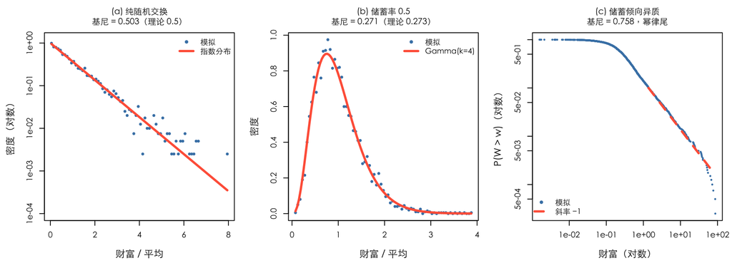

```r
set.seed(1)
KIN_N <- 4000; KIN_R <- 1200
reg("kin_N", KIN_N, "analytic", "§3.4 kinetic_exchange", "连续版模拟的人数")
reg("kin_R", KIN_R, "analytic", "§3.4 kinetic_exchange", "连续版模拟的轮数")
## 首富倍数是闭式 H_N 的求值，不是手写：H_N = sum 1/k，Gumbel 标准差 pi/sqrt(6)
kin_HN <- sum(1/seq_len(KIN_N)); kin_lnN <- log(KIN_N)
## 首富的区间用精确分位数，不用 mean +- k*sd——Gumbel 右偏，对称区间会低估右尾。
## N 个 Exp(1) 的最大值 M 满足 P(M<=x) = (1-e^{-x})^N，于是分位数有闭式。
kin_q <- function(p) -log(1 - p^(1/KIN_N))
reg("kin_HN",   kin_HN,      "analytic", "§3.4 kinetic_exchange", "H_N，N 人里首富对均值的期望倍数")
reg("kin_lnN",  kin_lnN,     "analytic", "§3.4 kinetic_exchange", "ln N，H_N 的主项")
reg("kin_q025", kin_q(.025), "analytic", "§3.4 kinetic_exchange", "首富倍数的 2.5% 分位（闭式）")
reg("kin_q975", kin_q(.975), "analytic", "§3.4 kinetic_exchange", "首富倍数的 97.5% 分位（闭式）")
stopifnot(abs(kin_HN - (kin_lnN + 0.5772156649)) < 1e-3,
          kin_q(.975) - kin_HN > kin_HN - kin_q(.025))   # 右偏：上尾必须更长
kinetic <- function(N = KIN_N, rounds = KIN_R, lam = 0, lam_vec = NULL){
  w <- rep(1, N); L <- if (is.null(lam_vec)) rep(lam, N) else lam_vec; half <- N/2
  for (r in 1:rounds){
    idx <- sample.int(N); i <- idx[1:half]; j <- idx[(half+1):N]
    pooled <- (1-L[i])*w[i] + (1-L[j])*w[j]; e <- runif(half)
    w[i] <- L[i]*w[i] + e*pooled
    w[j] <- L[j]*w[j] + (1-e)*pooled
  }
  w
}
wa <- kinetic(lam = 0)          # (a) 纯随机交换
wb <- kinetic(lam = 0.5)        # (b) 每人留存一半再交换
set.seed(2)
wc <- kinetic(lam_vec = runif(KIN_N))   # (c) 储蓄倾向因人而异
## Gamma(k=4) 基尼的闭式，图注与后面的登记项共用这一个变量（公式只写一次）。
## k = 1 + 3λ/(1-λ)，λ=0.5 给 k=4。
g4_closed <- gamma(4.5)/(sqrt(pi)*gamma(5))

par(mfrow = c(1, 3), mar = c(4.4, 4.6, 3.4, 1), family = "cjk")
u <- wa/mean(wa); h <- hist(u[u < 8], breaks = 60, plot = FALSE)
plot(h$mids, h$density, log = "y", pch = 16, col = "steelblue", cex = 0.8, ylim = c(1e-4, 1.2),
     main = sprintf("(a) 纯随机交换\n基尼 = %.3f（理论 0.5）", gini(wa)),
     xlab = "财富 / 平均", ylab = "密度（对数）", cex.lab = 1.2, cex.main = 1.05)
curve(exp(-x), add = TRUE, col = "tomato", lwd = 3)
legend("topright", c("模拟", "指数分布"), pch = c(16, NA), lwd = c(NA, 3),
       col = c("steelblue", "tomato"), bty = "n", cex = 0.95)

ub <- wb/mean(wb); hb <- hist(ub, breaks = 60, plot = FALSE)
plot(hb$mids, hb$density, pch = 16, col = "steelblue", cex = 0.8,
     main = sprintf("(b) 储蓄率 0.5\n基尼 = %.3f（理论 %.3f）", gini(wb), g4_closed),
     xlab = "财富 / 平均", ylab = "密度", cex.lab = 1.2, cex.main = 1.05)
curve(dgamma(x*4, shape = 4)*4, add = TRUE, col = "tomato", lwd = 3)
legend("topright", c("模拟", "Gamma(k=4)"), pch = c(16, NA), lwd = c(NA, 3),
       col = c("steelblue", "tomato"), bty = "n", cex = 0.95)

sc <- sort(wc, TRUE); sf <- seq_along(sc)/length(sc)
plot(sc, sf, log = "xy", pch = 16, col = "steelblue", cex = 0.55,
     main = sprintf("(c) 储蓄倾向异质\n基尼 = %.3f，幂律尾", gini(wc)),
     xlab = "财富（对数）", ylab = "P(W > w)（对数）", cex.lab = 1.2, cex.main = 1.05)
reg("save_all",  gini(wb), "point", "§3.4 kinetic_exchange", "全民储蓄率 0.5；解析值 0.2734")
## Gamma(k=4) 基尼的闭式，与上面那个模拟值分开登记：图注与折叠标题引的是这个理论值。
reg("save_all_closed", g4_closed, "analytic", "§3.4 kinetic_exchange",
    "Gamma(k=4) 基尼闭式 Γ(k+½)/(√π Γ(k+1))；k=1+3λ/(1-λ) 在 λ=0.5 处给 k=4")
reg("save_het",  gini(wc), "point", "§3.4 kinetic_exchange", "储蓄倾向因人而异")
xx <- 10^seq(log10(quantile(wc, .9)), log10(max(wc)), length.out = 40)
lines(xx, 0.1*(xx/quantile(wc, .9))^(-1), col = "tomato", lwd = 3, lty = 2)
legend("bottomleft", c("模拟", "斜率 −1"), pch = c(16, NA), lwd = c(NA, 3),
       lty = c(NA, 2), col = c("steelblue", "tomato"), bty = "n", cex = 0.95)
```

左图就是岛屿模型的连续极限：指数分布，在半对数坐标上一条直线，基尼 0.503——金币磨细之后，那个 $11/21$ 落到了 $1/2$。守恒量的随机交换，平衡态就是固定均值下的最大熵分布（复习：[指数分布 = 非负 + 固定均值下的最大熵](https://nyuhuyang.github.io/notes/exp_normal_boltzmann_zh.html#%E6%8C%87%E6%95%B0%E5%88%86%E5%B8%83-%E6%9C%80%E5%A4%A7%E7%86%B5-%E9%9D%9E%E8%B4%9F-%E5%9D%87%E5%80%BC%E7%BA%A6%E6%9D%9F)）。

中图和右图是两个改动。每人先留存一半再交换，分布变成 Gamma，基尼 掉到 0.271——储蓄这个看似与公平无关的习惯，本身就是均等化力量 (Chakraborti and Chakrabarti 2000)。储蓄倾向因人而异（有人存得多有人存得少，这是唯一的异质性），尾巴立刻变成幂律，基尼 冲到 0.758 (Chatterjee et al. 2004)。

值得停一下：右图的不平等不是因为谁“能力强”，纯粹是因为规则对不同人不一样。异质性一进入乘性结构，指数尾就变成幂律尾——为什么会这样，下一节用一行恒等式说清。

第三个变体不在上面这排图里，因为它画不进去。前两个换的是“每个人留多少”，第三个换的是“每次拿多少出来换”：不再把两人的合并额随机劈分，而是按财富的固定比例对赌——这就是 yard-sale 模型 (Chakraborti 2002)。守恒没动，公平没动，规则的同质性也没动，但平稳态直接消失了：分布一路变宽，基尼不停地爬向 1。上面三张图各自有一个可以报数的稳态形状，这一个连形状都不收敛，所以没法和它们并排放。它是本文里分量最重的一个变体——它说明“程序公平”根本不是一个二元属性——第 4.3 节整节展开。

（这条的文内版本就是下一节；更长的铺垫见 [scale-free：乘性无记忆性](https://nyuhuyang.github.io/notes/exp_normal_boltzmann_zh.html#scale-free%E6%8A%8A%E4%B9%98%E6%80%A7%E6%97%A0%E8%AE%B0%E5%BF%86%E7%94%BB%E5%87%BA%E6%9D%A5%E5%B9%B6%E8%AF%81%E6%98%8E%E5%AE%83%E5%94%AF%E4%B8%80)；财富为什么老是被当成幂律讨论，见[那一节的旁注](https://nyuhuyang.github.io/notes/exp_normal_boltzmann_zh.html#%E6%97%81%E4%BE%8B%E8%B4%A2%E5%AF%8C%E5%88%86%E5%B8%83%E4%B8%BA%E4%BB%80%E4%B9%88%E5%B8%B8%E8%A2%AB%E8%B0%88%E5%B9%82%E5%BE%8B)。这里的右图正好给那个旁注补了一个机制：幂律尾不需要能力差异，只需要规则的异质性。）

**中图那个 0.273 是怎么来的（可跳过）**

加了储蓄率 $\lambda$ 之后，平衡态是 Gamma 分布，形状参数（数值上极好的近似，Chakraborti–Chakrabarti）

$$k \;=\; 1 + \frac{3\lambda}{1-\lambda}
\qquad\Longrightarrow\qquad
\lambda = 0.5 \ \Rightarrow\ k = 4$$

对应上面代码里的 `dgamma(shape = 4)`。Gamma 的 基尼 有闭式：

$$G \;=\;
\frac{\Gamma\!\left(k+\tfrac12\right)}{\sqrt{\pi}\,\Gamma(k+1)}$$

代 $k=4$ 得 $11.632/42.539 = 0.2734$；代 $k=1$ 得 $0.5$，退回指数分布，自洽。$k$ 是“有效自由度”——储蓄让每个人的财富变成若干次独立冲击的和，中心极限把它往均值收，不平等自然掉下来。

（复习：Gamma 是[同时约束 $\langle x\rangle$ 与 $\langle \ln x\rangle$ 的最大熵分布](https://nyuhuyang.github.io/notes/exp_normal_boltzmann_zh.html#%E5%90%88%E4%BD%93%E5%90%8C%E6%97%B6%E7%BA%A6%E6%9D%9F-langle-xrangle-%E5%92%8C-langleln-xrangle-gamma)。这给了储蓄一个信息论读法：储蓄额外锁住了 $\langle\ln x\rangle$——它压住了对数尺度上的涨落，也就是压住了破产端，$k>1$ 正是这个约束的痕迹。）

## 3.5 顶端那一段：为什么乘性噪声给的是幂律

上一节右边那张图已经是幂律尾了，可那里只丢了一句”异质性一进入乘性结构，指数尾就变成幂律尾”，没说为什么。这一节把它补上——而且不需要新机器，前面那三条路整个能用，只要换一个坐标。

先把差别说到最小。前面整章的交换是**加性**的：每轮转手的是一枚金币，跟你手里有多少无关。而储蓄倾向因人而异之后，每个人的财富每轮被乘上一个属于他自己的系数——转手的是一个**比例**。噪声跟不跟着财富走，全部区别就在这一句。

而比例在对数尺度上就是加法。于是有下面这条恒等式，它是这一整节的全部内容：

$$\ln\frac{W}{w_{\min}}\sim\mathrm{Exp}(\alpha)
\qquad\Longleftrightarrow\qquad
P(W>x)=\Bigl(\frac{x}{w_{\min}}\Bigr)^{-\alpha},\quad x\ge
w_{\min}$$

幂律就是对数尺度上的指数。左边那个 $\mathrm{Exp}(\alpha)$ 正是第 3.1 到 3.3 节推了三遍的东西，只不过住在 $\ln W$ 上而不是 $W$ 上。所以”为什么是幂律”这一问，答案是”因为在对数尺度上，它就是那个已经证过三遍的指数”。

```r
## 验这条恒等式，而且刻意反着抽：先在对数尺度上抽指数，再取指数还原，
## 看幂律是不是自己冒出来——不是先造一个幂律再去拟合它。
set.seed(21)
PL_A <- 1.9                       # 与 §2.6 英国财富那一段同一个尾指数
PL_MIN <- 1
pl_w  <- PL_MIN * exp(rexp(2e5, rate = PL_A))
pl_ln <- log(pl_w/PL_MIN)
## (a) 对数尺度上应当是指数分布，均值 1/alpha
stopifnot(abs(mean(pl_ln) - 1/PL_A) < 0.01)
## (b) 原尺度上应当是幂律：双对数生存曲线的斜率就是 -alpha
pl_x <- quantile(pl_w, seq(0.5, 0.999, length.out = 60))
pl_S <- sapply(pl_x, function(t) mean(pl_w > t))
pl_slope <- unname(coef(lm(log(pl_S) ~ log(pl_x)))[2])
stopifnot(abs(pl_slope + PL_A) < 0.05)
reg("pl_alpha",  PL_A,        "analytic", "§3.5 log_scale", "验证用的尾指数，取 §2.6 英国财富那一段的值")
reg("pl_lnmean", mean(pl_ln), "point",    "§3.5 log_scale", "对数尺度上的样本均值，理论值 1/alpha")
reg("pl_slope",  pl_slope,    "point",    "§3.5 log_scale", "双对数生存曲线的拟合斜率，理论值 -alpha")
```

抽 20 万个样本：对数尺度上的均值是 0.5262（理论 $1/\alpha=$ 0.5263），还原到原尺度后双对数生存曲线的斜率是 -1.895（理论 $-\alpha=$ -1.9）。没有拟合任何东西，幂律是抽出来的。

### 3.5.1 两个约束，两段分布

幂律那一段：支撑 $x\ge x_{\min}$，约束换成对数均值 $\int_{x_{\min}}^\infty \ln x\,p(x)\,dx=m$。拉格朗日函数里把 $\lambda_1 x$ 换成 $\lambda_1\ln x$：

$$L=-\int p\ln p\,dx-\lambda_0\left(\int
p\,dx-1\right)-\lambda_1\left(\int \ln x\,p\,dx-m\right)$$

对 $p$ 变分：$-\ln p-1-\lambda_0-\lambda_1\ln x=0$，所以 $p(x)\propto x^{-\lambda_1}$。写成尾指数 $\alpha=\lambda_1-1$，再用下界归一化：

$$p(x)=\frac{\alpha}{x_{\min}}\left(\frac{x}{x_{\min}}\right)^{-(\alpha+1)},\qquad
x\ge x_{\min}$$

约束定住 $\alpha$：Pareto 的对数均值是 $m=\ln x_{\min}+1/\alpha$，所以 $\alpha=1/(m-\ln x_{\min})$。$\alpha$ 越大，对数均值越靠近下界，尾越轻；$\alpha$ 越小，尾越重。

关键在这里：幂律的算术均值不一定存在。$\alpha\le1$ 时 $\int x\,p(x)\,dx$ 发散，拿“平均收入”去约束它根本没有意义；能把它钉住的是对数均值。指数那一段正好相反：它有有限均值，也没有幂律那种尺度不变性，所以算术均值就是自然的约束。两段不是“同一个分布的两个参数”，是两台约束不同的最大熵机器。

换成收入的语言：工薪那一份是加性的、下有界的，长期收支平衡把算术均值钉住，所以是指数；财产那一份是乘性的、尺度不变的，乘性过程把对数均值钉住，所以是幂律。

最后留一个边界：把两个约束同时加到 $x\ge0$ 上的一个分布上，得到的不是这条拼接分布，而是 Gamma（前面已经提过：Gamma 是同时约束 $\langle x\rangle$ 与 $\langle\ln x\rangle$ 的最大熵解）。两段分布是两套机制各自解一次、再在接缝处拼起来；它不是一条把两个均值都约束住的单分布。把 Gamma 当成“两段的统一解”，就会把“机制换挡”误读成“同一条曲线上的两个参数”。

但有一处不能照搬，而它恰好解释了为什么幂律只能待在顶端。第 3.1 节那台机器要的是一堵墙：$W\ge0$，而且是反射的。搬到对数尺度上，这堵墙没了——$\ln W\to-\infty$ 是可达的，对应 $W\to0$，而 $W=0$ 在对数尺度上是无穷远，不是一个格子。上面那条恒等式里的 $w_{\min}$ 就是被硬塞回去的那堵墙：没有它，$\int_0^\infty x^{-(1+\alpha)}\,\mathrm dx$ 在 0 端发散，幂律根本不存在。

所以两段的关系不是并列的。幂律那一段必须坐在别的东西之上——它自己给不出自己的下界。第 2.6 节那条英国财富的拟合律就是这么写的：10 万英镑以下是指数，以上才是幂律，而那个 10 万既是接点，也就是这里的 $w_{\min}$。

这一节没说的是 $\alpha$ 等于多少。它由动力学定，而定它的方式不止一种：第 5 章会从一条守恒的交换规则里把 $\alpha$ 直接解出来，不外加任何东西；第 2.7 节提过的那条 Fokker–Planck 走的是另一条路，靠一个外生的比例回复项。两条路都到得了幂律，但到的不是同一段区间——这一点第 5 章开头会说清。

# 4 第二题：基尼系数 0.5 是怎么算出来的，又意味着什么

形状定下来之后，第二题就只剩两件事：把这个数算出来，以及说清它到底意味着什么样的社会。（再提醒一次：这一章所有的基尼都是财富基尼；唯一的例外会明确标出“收入”。）

## 4.1 把 0.5 算出来

上一节定下了形状，第二题问的是这个形状有多不平等。这一节把基尼系数算出来——只需要三步，而且只用到分布的形状，跟它怎么来的无关。

第 1 步：把 基尼 换一种写法。

基尼 通常用 Lorenz 曲线定义：对角线与 Lorenz 曲线之间面积的两倍（下一节会把这块阴影画出来）。但等价地，还有一个算起来顺手得多的写法：

$$G \;=\; \frac{E\,|X-Y|}{2\mu},\qquad X,Y
\ \text{独立同分布}$$

读法：随机抓两个人，财富差的期望，除以两倍均值。分母的 $2\mu$ 是归一化——极端情形（一人独占）下 $E|X-Y| \to 2\mu$，$G\to 1$；完全平均时分子为 0。

先说破这个对象住在哪儿：$G$ 是**分布空间上的泛函**，不是某个样本的属性。所以“指数分布的 基尼”是一个确定的数，谈不上估计误差；模拟只是在验证收敛。

第 2 步：基尼 与均值无关，这是结构性的，不用算就能看出来。

指数族只有一个参数，而且它是**尺度参数**：$X\sim\mathrm{Exp}(\mu)$ 等价于 $X = \mu Z$，$Z\sim\mathrm{Exp}(1)$。而 $G$ 尺度不变：

$$\frac{E|cX - cY|}{2c\mu} \;=\;
\frac{E|X-Y|}{2\mu}$$

所以整条指数族射线上 $G$ 是同一个常数。剩下的只是把这个常数算出来。

第 3 步：算出 $1/2$。

设 $X,Y$ 独立同服从 $\mathrm{Exp}(r)$，先求 $|X-Y|$ 的分布。由对称性和[无记忆性](https://nyuhuyang.github.io/notes/exp_normal_boltzmann_zh.html#%E6%80%A7%E8%B4%A8%E6%97%A0%E8%AE%B0%E5%BF%86%E6%80%A7)（复习：$P(X>s+t\mid X>s)=P(X>t)$，指数分布“不记得已经等了多久”）：

$$P(|X-Y| > t) \;=\; 2\,P(X > Y+t)
\;=\; 2\,E_Y\!\left[e^{-r(Y+t)}\right] \;=\;
2e^{-rt}\underbrace{E\!\left[e^{-rY}\right]}_{=\,\frac{r}{r+r}=\frac12}
\;=\; e^{-rt}$$

也就是说：两个指数变量之差的绝对值，还是同一个指数分布。于是 $E|X-Y| = \mu$，代回第 1 步：

$$G \;=\; \frac{\mu}{2\mu} \;=\;
\boxed{\tfrac12}$$

$1/2$ 的来源就是那个 $2$：差的期望恰好等于一个均值，而归一化用的是两个均值。用 Lorenz 路线交叉检验也一样——指数分布的 $L(p) = p + (1-p)\ln(1-p)$，$\int_0^1 L = \tfrac12 - \tfrac14 = \tfrac14$，$G = 1 - 2\cdot\tfrac14 = \tfrac12$。

同一条曲线还给出第二个精确常数，后面第 5 章要用。把“对角线减 Lorenz 曲线”这个**垂直间距**单独拿出来看：

$$D(x) \;\equiv\; x - L(x)$$

基尼是它的两倍面积，$G = 2\int_0^1 D(x)\,\mathrm dx$。而它还有一个同样自然的读数——峰值：

$$P \;\equiv\; \max_x D(x)$$

这个数有名字，叫 Pietra 指数（1915 年提出，也叫 Robin Hood 指数、Hoover 指数），意思很直白：要让所有人一样富，至少得把总财富的百分之多少从上半截搬到下半截。

对指数分布，这两个数都能算到底：

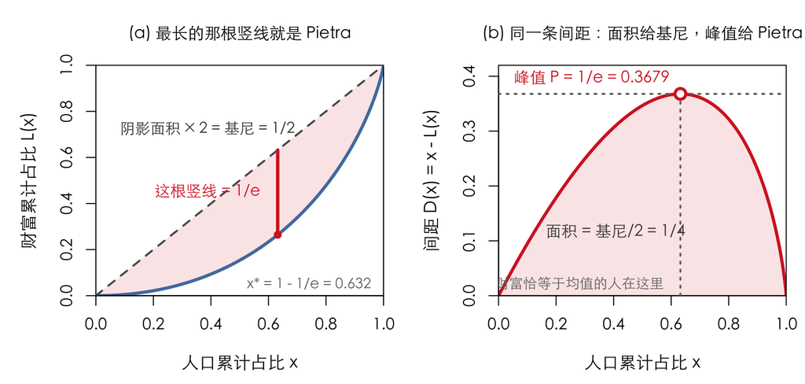

```r
## 指数分布的 Lorenz 间距 D(x) = x - L(x)，L(x) = x + (1-x)ln(1-x)
## 基尼 = 2∫D（面积的两倍）；Pietra = max D（峰值）。两者都有闭式。
BLU <- "steelblue"; ACC <- "#D62728"; GRY <- "gray45"
Lx <- function(x){ y <- x + (1 - x)*log(1 - x); y[!is.finite(y)] <- x[!is.finite(y)]; y }
## x -> 1 时 -(1-x)ln(1-x) 是 0·(-Inf)，R 给 NaN；极限为 0，端点补上。x=0 同理。
Dx <- function(x){ y <- -(1 - x)*log(1 - x); y[!is.finite(y)] <- 0; y }
xs <- seq(1e-9, 1 - 1e-9, length.out = 2000)
xstar <- 1 - exp(-1); Pstar <- exp(-1)         # 解析：极大点与峰值

par(mfrow = c(1, 2), mar = c(4.6, 5.0, 3.4, 1.0), cex.lab = 1.08, cex.main = 1.02,
    family = "cjk")

## (a) Lorenz 曲线上的那根最长竖线
plot(xs, Lx(xs), type = "l", lwd = 3.2, col = BLU, xlim = c(0,1), ylim = c(0,1),
     xaxs = "i", yaxs = "i", xlab = "人口累计占比 x", ylab = "财富累计占比 L(x)",
     main = "(a) 最长的那根竖线就是 Pietra")
polygon(c(xs, rev(xs)), c(xs, rev(Lx(xs))), col = adjustcolor(ACC, .12), border = NA)
lines(c(0,1), c(0,1), lty = 2, lwd = 2, col = "gray35")
segments(xstar, Lx(xstar), xstar, xstar, lwd = 3.4, col = ACC)
points(xstar, Lx(xstar), pch = 16, col = ACC, cex = 1.1)
text(0.05, 0.72, "阴影面积 × 2 = 基尼 = 1/2", col = "gray25", pos = 4, cex = 0.95)
text(xstar, (xstar + Lx(xstar))/2, "这根竖线 = 1/e  ", col = ACC, pos = 2, cex = 0.98)
text(0.99, 0.045, sprintf("x* = 1 - 1/e = %.3f", xstar), col = GRY, pos = 2, cex = 0.9)

## (b) 把间距单独画出来
plot(xs, Dx(xs), type = "l", lwd = 3.2, col = ACC, xlim = c(0,1), ylim = c(0, 0.42),
     xaxs = "i", yaxs = "i", xlab = "人口累计占比 x", ylab = "间距 D(x) = x - L(x)",
     main = "(b) 同一条间距：面积给基尼，峰值给 Pietra")
polygon(c(xs, rev(xs)), c(Dx(xs), rep(0, length(xs))), col = adjustcolor(ACC, .12), border = NA)
segments(xstar, 0, xstar, Pstar, lty = 3, lwd = 2, col = GRY)
abline(h = Pstar, lty = 3, lwd = 2, col = GRY)
points(xstar, Pstar, pch = 21, bg = "white", col = ACC, lwd = 3, cex = 1.5)
text(0.02, 0.395, sprintf("峰值 P = 1/e = %.4f", Pstar), col = ACC, pos = 4, cex = 1.0)
text(0.13, 0.115, "面积 = 基尼/2 = 1/4", col = "gray25", pos = 4, cex = 1.0)
text(xstar, 0.020, "财富恰等于均值的人在这里  ", col = GRY, pos = 2, cex = 0.88)
```

```r
## 自检：闭式对得上，且极大点处 Lorenz 斜率为 1
stopifnot(abs(2*integrate(Dx, 0, 1)$value - 0.5) < 1e-6,   # 数值积分，非解析比较
          abs(optimize(Dx, c(1e-9, 1-1e-9), maximum = TRUE)$objective - exp(-1)) < 1e-6,
          abs((Lx(xstar + 1e-6) - Lx(xstar - 1e-6))/2e-6 - 1) < 1e-4)
reg("pietra_baseline",  exp(-1), "analytic", "§4.1 lorenz_gap", "指数分布的 Pietra 指数 = 1/e")
reg("pietra_cut",       xstar,   "analytic", "§4.1 lorenz_gap", "间距极大点 = 1 - 1/e，即财富=均值的分位")
```

峰值取在哪里，也是闭式的：$D'(x)=0$ 即 $L'(x)=1$，而 Lorenz 曲线的斜率是“该分位的财富除以均值”，所以极大点正是财富恰好等于均值的那个人。对指数分布那是第 $1-1/e \approx 63.2\%$ 分位，峰值 $P = 1/e \approx 0.368$。

这正好兑现第 2.6 节留下的那个承诺。那里把基尼拆成“组内 + 组间”，并说组间项就是 $D$ 在切点处的取值 $D(p_L)$；也说了切点是一个选择。现在可以把话说完：如果不想选，就取让组间项最大的那一点——那就是这里的 $x^*$，而此时组间项恰好等于 $P$。于是“顶端多拿了多少”有了一个零拟合参数的标准答案。

于是基线上有两个不需要拟合任何参数的常数：

$$\underbrace{G=\tfrac12}_{\text{间距的两倍面积}}
\qquad\qquad \underbrace{P=\tfrac1e}_{\text{间距的峰值}}$$

这两个数是同一条曲线的两种读法——一个把整条间距压成面积，一个只取它最高的那一点。第 5 章会看到，这个区别不是修辞：压成一个数的过程里丢掉了什么，正是那一章要处理的问题。

收尾：它到底有多不平等。这座岛上只有约 39% 的岛民在平均线以上，而这少数人握着 77% 的金币；后一半人合起来只有 16%。（这三个数按岛上离散的几何分布算；连续极限下是 37%、74%、15%，下一节还会展开。）基尼系数 0.5 听起来温和，实际不是。

## 4.2 基尼系数 0.5 长什么样

上一节把基尼系数算出来了，但 0.5 仍然是个抽象的数。把它翻译成看得见的样子：把这 4000 个人按财富排成一队，再画一条 Lorenz 曲线。

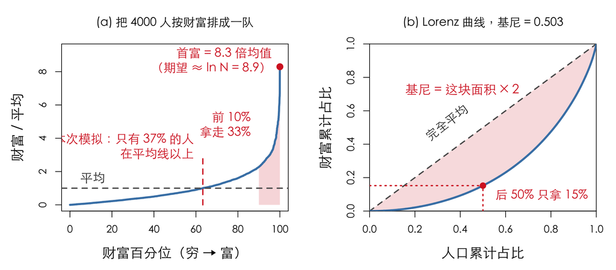

```r
ACC <- "#D62728"
u   <- sort(wa/mean(wa)); N <- length(u); pct <- (1:N)/N

par(mfrow = c(1, 2), mar = c(4.8, 5.0, 3.6, 1.6), cex.lab = 1.35, cex.main = 1.15, family = "cjk")

## (a) 把所有人按财富排成一队
## 标注一律由本次模拟的 u 实算；正文另有离散/连续两组解析值，二者不是同一个量
ab_mean <- mean(u > 1); top10 <- sum(tail(sort(u), round(N/10)))/sum(u)
plot(pct*100, u, type = "n", ylim = c(0, max(u)*1.12),
     xlab = "财富百分位（穷 → 富）", ylab = "财富 / 平均",
     main = "(a) 把 4000 人按财富排成一队")
polygon(c(90, pct[pct >= .9]*100, 100), c(0, u[pct >= .9], 0),
        col = adjustcolor(ACC, .18), border = NA)
lines(pct*100, u, lwd = 3.2, col = "steelblue")
abline(h = 1, lty = 2, lwd = 2, col = "gray35")
segments(100*(1-ab_mean), 0, 100*(1-ab_mean), 3.0, lty = 2, lwd = 2, col = ACC)  # 竖线位置同样实算
text(2, 1.55, "平均", col = "gray20", cex = 1.2, pos = 4)
text(62, 3.3, sprintf("本次模拟：只有 %.0f%% 的人\n在平均线以上", 100*ab_mean),
     col = ACC, cex = 1.2, pos = 2)
text(89, 4.6, sprintf("前 10%%\n拿走 %.0f%%", 100*top10), col = ACC, cex = 1.2, pos = 2)
points(100, u[N], pch = 16, cex = 1.5, col = ACC)
text(99, u[N]*1.02, sprintf("首富 = %.1f 倍均值\n（期望 ≈ ln N = %.1f）", u[N], sum(1/(1:N))),
     col = ACC, cex = 1.2, pos = 2)

## (b) Lorenz 曲线：阴影是曲线与对角线之间那块
L <- cumsum(u)/sum(u); L50 <- approx(pct, L, .5)$y
plot(NA, xlim = c(0,1), ylim = c(0,1), xaxs = "i", yaxs = "i",
     xlab = "人口累计占比", ylab = "财富累计占比",
     main = sprintf("(b) Lorenz 曲线，基尼 = %.3f", gini(wa)))
polygon(c(pct, rev(pct)), c(pct, rev(L)), col = adjustcolor(ACC, .16), border = NA)
lines(c(0,1), c(0,1), lwd = 2, lty = 2, col = "gray35")
lines(c(0, pct), c(0, L), lwd = 3.2, col = "steelblue")
segments(.5, 0, .5, L50, lty = 3, lwd = 2, col = ACC)
segments(0, L50, .5, L50, lty = 3, lwd = 2, col = ACC)
points(.5, L50, pch = 16, cex = 1.4, col = ACC)
text(.99, .09, sprintf("后 50%% 只拿 %.0f%%", L50*100), col = ACC, cex = 1.2, pos = 2)
text(.34, .53, "完全平均", col = "gray20", cex = 1.2, srt = 38)
text(.13, .72, "基尼 = 这块面积 × 2", col = ACC, cex = 1.25, pos = 4)
```

这个社会长这样——下面每一条都是指数分布的闭式解，不是从模拟里拟合出来的，上面那张图只是它的一次实现：

- 随便抓两个人，他们的财富差距，期望正好是一个人的平均财富（$E|X-Y|=\mu$，上一节算过）。而且这个差距本身还服从同一个指数分布——两个人之间的差距，长得像第三个人。基尼 无非是把这句话除以 $2\mu$。
- 只有 $e^{-1} = 36.8\%$ 的人在平均线以上，而这少数人拿走 $2/e = 73.6\%$。“三分之一的人拿走四分之三”就是 基尼 0.5 的日常样貌。
- 中位数只有平均数的 $\ln 2 = 0.69$ 倍。平均数在这里是个系统性的骗子，而且骗人的幅度是个常数。
- 前 10% 拿 33%，前 1% 拿 5.6%，后 50% 只拿 15.3%（$p(1-\ln p)$）。上半区的人均财富是下半区的 $\frac{1+\ln 2}{1-\ln 2} = 5.5$ 倍。
- 门槛 +1 定律：$E[X\mid X>q] = q+\mu$。进“前 1%”的门槛是 4.6 倍均值，而这群人的平均是 5.6 倍——过了任何门槛，门里的人平均还要再多出整整一个均值。这就是无记忆性，换成钱的说法。
- 要把它抹平，得搬走全部财富的 $1/e = 36.8\%$（Hoover 指数），而且要搬的正好是平均线以上那 36.8% 的人。两个 36.8% 是同一个 $1/e$。
- 4000 人里的首富，期望是均值的 $H_N=$ 8.9 倍（$H_N=\sum_{k\le N}1/k \approx \ln N+\gamma$；$\ln N=$ 8.29，加上欧拉常数才是 8.9）（首富本身是随机变量，服从 Gumbel 型分布而且右偏，95% 的实现落在 7.0～12.0 倍之间——上尾比下尾长得多，所以单次实现跳到十一二倍并不反常）。要紧的是这个 $\ln$：人再多，首富也只按对数变富——没有正反馈的世界里长不出超级富豪。前面右图那条幂律尾必须靠异质性才长得出来，原因就在这里。

于是本节的结论可以写死了：

> 程序完全公平（无人被偏袒），结果的 基尼 也是 0.5。

这是一条**热力学不平等基线**。它把“公平”这个词劈成两半：过程的公平不蕴含结果的平等，最大熵态自带相当程度的不平等。基尼低于 0.5 说明有再分配在起作用；高于 0.5 说明有正反馈在放大。它是程序公平的下限，不是不公平的上限。

但这里必须立刻堵一个误读：熵不等于规范意义上的公平。最大熵态只意味着“没有人被特殊对待”，那是程序上的公平——它不回答“什么样的分配才算正当”。政治哲学里对这一问有的是别的答案，随手举两个最常被引的：罗尔斯的差别原则说，不平等只有在对处境最差的那群人也有利时才可接受；森的可行能力说，该看的根本不是钱分得怎么样，而是一个人实际能做成什么、能成为什么。按这两条标准，一个基尼 0.5 的最大熵社会都远谈不上公平。哪一档不平等可以接受，是个规范问题，这个模型一个字都答不上来。本文给的是实证基线与机制，不是伦理结论。

顺带把一个最容易混的东西量出来：这里说的是财富，不是收入。在这座岛上，两者差得极远——

```r
set.seed(4); Ni <- 1000; wi <- rep(10, Ni); hf <- Ni/2
wins <- c(1, 5, 20, 100, 1000)                   # 把多少轮算作一个"收入年度"
inc  <- lapply(wins, function(w) numeric(Ni)); from <- 30000 - wins
for (r in 1:30000){
  idx <- sample.int(Ni); i <- idx[1:hf]; j <- idx[(hf+1):Ni]
  pay <- wi[i] > 0; wi[i] <- wi[i] - pay; wi[j] <- wi[j] + pay
  for (k in seq_along(wins)) if (r > from[k]) inc[[k]][j] <- inc[[k]][j] + pay
}
g_inc <- sapply(inc, gini); g_w <- gini(wi)
```

| 收入的核算窗口 | 收入（流量）基尼 | 财富（存量）基尼 |
| --- | --- | --- |
| 1 轮 | 0.547 | 0.523 |
| 5 轮 | 0.266 | 0.523 |
| 20 轮 | 0.135 | 0.523 |
| 100 轮 | 0.063 | 0.523 |
| 1000 轮 | 0.019 | 0.523 |

财富基尼钉在 0.52 一动不动，收入基尼却从 0.55 一路滑到 0.02。这不是噪声，是两个量的性质不同：财富是存量，它的分布是这个模型的稳态性质，跟你怎么记账无关；收入是流量，它的基尼是核算窗口的函数——窗口越长，大数定律抹得越平，极限是 0。道理很直白：每一轮每个人至多收到一枚金币，流量本来就高度平均；而财富是流量在时间上的累积，随机涨落一路叠加，就分化了出来。

这件事有两个后果，都要紧。

其一（本节的主角）：财富的不平等，可以完全不由收入的不平等产生。现实中财富基尼（普遍 0.7 以上）远高于收入基尼（多在 0.25–0.6），通常被解释成“高收入者存得更多”；但这座岛说明，哪怕收入完全平等、储蓄率也完全相同，财富照样会分化——只需要时间和随机性。收入差距是财富差距的一个来源，但不是必要条件。

其二（第 4.4 节会用到）：模型的收入预测带一个自由参数，财富预测不带。财富基尼 0.52 是稳态性质，模型里没有任何可调项；而“收入基尼是多少”必须先回答“多少轮算作一年”——偏偏这个模型没有校准过的时间尺度。所以拿收入去对数据，对上对不上首先取决于那个校准假设。能直接和数据对的输出只有一个：财富的分布形状。

（一句口径提醒，免得对错数：这条基线是财富分布的。新闻里常引的国别 基尼 基本都是收入 基尼（多在 0.25–0.6），而真实的财富 基尼 普遍在 0.7 以上——那里的差距主要来自继承、资产回报和杠杆这些本模型里没有的正反馈。两个口径不能直接比。下一节就把这条“正反馈”补进模型，看它值多少个 基尼点。）

**金币不可切分带来的修正：为什么是 11/21（可跳过）**

回到金币不可切分的离散版。平衡态是几何分布 $P(n)=(1-q)q^{\,n}$，同一台机器再走一遍。先求两个人的差：对 $k>0$，

$$P(X-Y=k)\;=\;\sum_{n\ge
0}P(X=n+k)P(Y=n)\;=\;(1-q)^2q^{\,k}\sum_{n\ge0}q^{2n}\;=\;\frac{(1-q)^2}{1-q^2}\,q^{\,k}$$

于是

$$E|X-Y| \;=\;
2\sum_{k\ge1}k\,\frac{(1-q)^2}{1-q^2}q^{\,k}
\;=\; \frac{2q}{1-q^2},
\qquad \mu=\frac{q}{1-q}$$

$$G \;=\; \frac{E|X-Y|}{2\mu} \;=\;
\frac{1-q}{1-q^2} \;=\; \boxed{\frac{1}{1+q}} \;=\;
\frac{c+1}{2c+1}$$

$c=10$（每人十枚金币）给 $11/21=0.524$，$c\to\infty$ 给 $1/2$，$c=1$（人均一枚）给 $2/3$——金币越粗，量子化本身就在制造不平等。

```r
set.seed(3); n <- 2e6
x <- rexp(n); y <- rexp(n)
c(`E|X-Y|/(2mu)`      = mean(abs(x - y)) / (2 * mean(x)),   # 应为 0.5
  `Gamma(4) 闭式`      = gamma(4.5) / (sqrt(pi) * gamma(5)), # 应为 0.2734
  `Gamma(4) 模拟`      = gini(rgamma(n, shape = 4)),
  `Gamma(1) 闭式`      = gamma(1.5) / (sqrt(pi) * gamma(2)), # 退化为指数，应为 0.5
  `几何 c=10 闭式`     = 11/21,                              # 岛屿模型，应为 0.5238
  `几何 c=10 模拟`     = gini(as.numeric(rgeom(n, prob = 1/11))))
```

```
##   E|X-Y|/(2mu)  Gamma(4) 闭式  Gamma(4) 模拟  Gamma(1) 闭式 几何 c=10 闭式
##      0.4998648      0.2734375      0.2732684      0.5000000      0.5238095
## 几何 c=10 模拟
##      0.5237975
```

## 4.3 同一句“程序公平”，可以是基尼 0.5，也可以是一人独占

到这里，“程序完全公平 → 基尼 0.5”看起来像条稳固的结论。但它藏着一个没被说破的前提：每次交易转移多少钱。

本文的规则是把两人的钱合起来随机劈分，转移额与两人的财富之和挂钩。换一种同样自然、而且更像真实交易的定法：赌注按比例——每次两人拿出较穷那一方财富的一个固定比例 $f$ 押上，公平抛硬币定胜负。这就是文献里的 yard-sale 模型 (Chakraborti 2002)。

它依然总量守恒，依然每一笔都是公平硬币，依然规则对所有人一字不差。看看会发生什么：

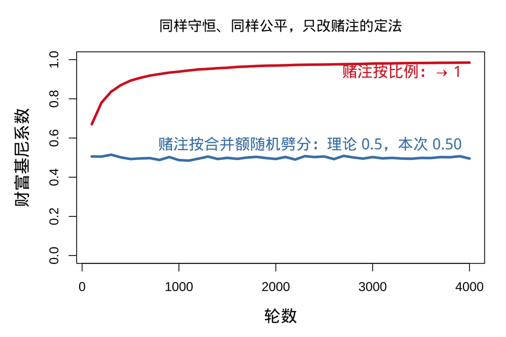

```r
N <- 2000; half <- N/2; ACC <- "#D62728"
ys <- function(f = 0.2, rounds = 4000, seed = 1){
  set.seed(seed); w <- rep(1, N); g <- numeric(0)
  for (r in 1:rounds){
    idx <- sample.int(N); i <- idx[1:half]; j <- idx[(half+1):N]
    stake <- f*pmin(w[i], w[j])                 # 赌注 = 较穷一方财富的固定比例
    win   <- (runif(half) < 0.5)*2 - 1          # 公平硬币
    w[i] <- w[i] + win*stake; w[j] <- w[j] - win*stake
    if (r %% 100 == 0) g <- c(g, gini(w))
  }
  list(w = w, g = g)
}
o <- ys()
reg("yardsale", o$g[length(o$g)], "transient", "§4.3 yard_sale",
    "不收敛：越跑越高，这是第 4000 轮的快照")
## 对照：本文的池化随机劈分，同样守恒、同样公平
set.seed(1); w2 <- rep(1, N); g2 <- numeric(0)
for (r in 1:4000){
  idx <- sample.int(N); i <- idx[1:half]; j <- idx[(half+1):N]
  pooled <- w2[i] + w2[j]; e <- runif(half); w2[i] <- e*pooled; w2[j] <- (1-e)*pooled
  if (r %% 100 == 0) g2 <- c(g2, gini(w2))
}
par(mar = c(4.8, 5.0, 3.4, 1.4), cex.lab = 1.3, cex.main = 1.12)
plot(seq(100, 4000, 100), o$g, type = "l", lwd = 3.2, col = ACC, ylim = c(0, 1),
     xlab = "轮数", ylab = "财富基尼系数", main = "同样守恒、同样公平，只改赌注的定法")
lines(seq(100, 4000, 100), g2, lwd = 3.2, col = "steelblue")
text(4000, 0.93, "赌注按比例：→ 1", col = ACC, cex = 1.2, pos = 2)
## 0.5 是理论稳态基线（解析），g2 末值是一次有限实现——两个都显示，不互相替换
text(4000, 0.56, sprintf("赌注按合并额随机劈分：理论 0.5，本次 %.2f", g2[length(g2)]),
     col = "steelblue", cex = 1.2, pos = 2)
```

基尼一路爬到 0.985 而且没有停下来的意思：91% 的人财富不足均值的 1%，前 1% 占了 77%。跑得足够久，全部财富会凝聚到一个人手里。Boghosian 把这个模型叫做“逃不掉的赌场” (Boghosian 2019)。

那分布长什么样？这是个陷阱问题——它没有分布。

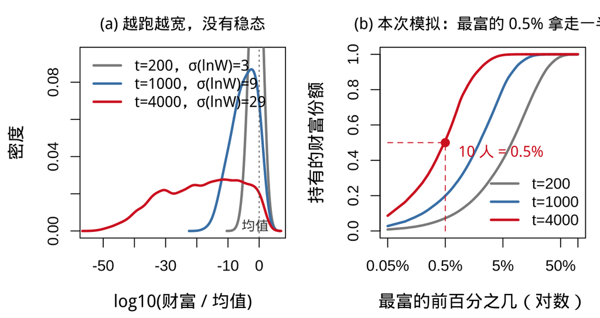

```r
## 三个时刻的财富分布（沿用上面的 ys()，只是把中途快照留下来）
ys_snap <- function(f = 0.2, snaps = c(200, 1000, 4000), seed = 1){
  set.seed(seed); w <- rep(1, N); S <- list()
  for (r in 1:max(snaps)){
    idx <- sample.int(N); i <- idx[1:half]; j <- idx[(half+1):N]
    stake <- f*pmin(w[i], w[j]); win <- (runif(half) < 0.5)*2 - 1
    w[i] <- w[i] + win*stake; w[j] <- w[j] - win*stake
    if (r %in% snaps) S[[as.character(r)]] <- w
  }
  S
}
SN <- ys_snap(); snaps <- c(200, 1000, 4000)
sig <- sapply(SN, function(v) sd(log(v)))
last <- SN[[3]]; cum <- cumsum(sort(last, TRUE))/sum(last)
sci <- function(x, d = 0){ e <- floor(log10(x)); sprintf("%.*f\\times 10^{%d}", d, x/10^e, e) }
i50 <- which(cum >= 0.50)[1]; i99 <- which(cum >= 0.99)[1]

## 有限尺度检查：把岛民从 200 加到 32000，看基尼和"拿走一半的那一撮"是否随人口漂移。
## 这段原先只在正文里给了结论，没有代码——现在补上。
ys_n <- function(Nn, f = 0.2, rounds = 4000, seed = 1){
  set.seed(seed); w <- rep(1, Nn); h <- Nn %/% 2
  for (r in 1:rounds){
    idx <- sample.int(Nn); i <- idx[1:h]; j <- idx[(h+1):(2*h)]
    stake <- f*pmin(w[i], w[j]); win <- (runif(h) < 0.5)*2 - 1
    w[i] <- w[i] + win*stake; w[j] <- w[j] - win*stake
  }
  cu <- cumsum(sort(w, TRUE))/sum(w)
  c(gini = gini(w), half = which(cu >= 0.5)[1]/Nn)
}
FS_N <- c(200, 800, 3200, 12800, 32000)
FS   <- t(sapply(FS_N, ys_n))
reg("yardsale_fs_lo", min(FS[, "gini"]), "point", "§4.3 ys_dist", "有限尺度扫描的基尼下界")
reg("yardsale_fs_hi", max(FS[, "gini"]), "point", "§4.3 ys_dist", "有限尺度扫描的基尼上界")

par(mfrow = c(1, 2), mar = c(4.4, 4.4, 2.6, 0.8), cex.lab = 1.15, cex.main = 1.05)
COL <- c("gray55", "steelblue", ACC)

## (a) 对数坐标上的分布：一路左移、一路变宽
plot(NA, xlim = c(-55, 6), ylim = c(0, 0.095),
     xlab = "log10(财富 / 均值)", ylab = "密度", main = "(a) 越跑越宽，没有稳态")
for (k in seq_along(snaps))
  lines(density(log10(SN[[k]]/mean(SN[[k]])), bw = 1.6), col = COL[k], lwd = 2.6)
abline(v = 0, lty = 3, col = "gray40")
text(6, 0.002, "均值", col = "gray30", cex = 0.9, pos = 2)
legend("topleft", bty = "n", cex = 1.0, col = COL, lwd = 2.6,
       legend = sprintf("t=%d，σ(lnW)=%.0f", snaps, sig))

## (b) 前百分之几的人拿走多少
plot(NA, xlim = c(0.05, 100), ylim = c(0, 1), log = "x", xaxt = "n",
     xlab = "最富的前百分之几（对数）", ylab = "持有的财富份额",
     main = local({
       wl <- sort(SN[[length(SN)]], TRUE); f <- cumsum(wl)/sum(wl)
       sprintf("(b) 本次模拟：最富的 %.1f%% 拿走一半", 100*which(f >= 0.5)[1]/length(wl))
     }))
axis(1, at = c(0.05, 0.5, 5, 50, 100), labels = c("0.05%", "0.5%", "5%", "50%", "100%"))
for (k in seq_along(snaps))
  lines(100*seq_len(N)/N, cumsum(sort(SN[[k]], TRUE))/sum(SN[[k]]), col = COL[k], lwd = 2.6)
segments(100*i50/N, 0, 100*i50/N, 0.5, lty = 2, col = ACC)
segments(0.05, 0.5, 100*i50/N, 0.5, lty = 2, col = ACC)
points(100*i50/N, 0.5, pch = 19, col = ACC, cex = 1.2)
text(100*i50/N, 0.44, sprintf(" %d 人 = %.1f%%", i50, 100*i50/N), col = ACC, cex = 1.0, pos = 4)
legend("bottomright", legend = sprintf("t=%d", snaps), col = COL, lwd = 2.6, bty = "n", cex = 1.0)
```

准确说，它没有稳态。左图把三个时刻画在对数坐标上：形状一直是对数正态的样子，但宽度不收敛——$\sigma(\ln W)$ 从 3 涨到 9，再到 29，越跑越宽，没有要停的迹象。到 $t=4000$ 时，最穷的人持有均值的 $10^{-52}$，最富的持有 $10^{2.2}$：跨 54 个数量级，中位数是均值的 $4\times 10^{-18}$。

右图是同一件事的另一个切面：10 个人（0.5%）拿走一半，84 个人（4.2%）拿走 99%。而且这不是“人太少”造成的假象——把岛民从 200 加到 32,000，基尼始终在 0.982–0.984。“拿走一半的那一撮”在 $N \ge 3200$ 之后稳定在 0.50% 上下；$N = 200$ 那一档是 1.0%，也就是 2 个人——这是那一次实现的结果，不是什么下限（200 人里最富的一个就已经是 0.5%）。小 $N$ 下这个比例本来就跳得厉害，单次运行看不出趋势。

所以正确的说法不是“yard-sale 的稳态分布是某某”，而是：它没有稳态分布，唯一的不动点是一个人持有全部，中途的任何一张分布图都只是路过。

为什么？一行就能说破：赢 20% 再输 20% 回不到原点（$1.2\times0.8=0.96$）。赌注按比例时，每个人面对的是一场乘性赌局，而乘性赌局的对数增长率

$$\tfrac12\ln(1+f)+\tfrac12\ln(1-f) \;=\;
\tfrac12\ln(1-f^2) \;<\; 0$$

期望是公平的，但每个人的时间平均都在往下走——这正是第 5 章那个“遍历性破裂”，只不过这次连增长都没有，纯靠守恒。而钱不会消失，于是它必须落到某处：除了随机产生的那一个赢家，其余人几乎必然趋于零，总量守恒逼着这些钱堆到越来越少的人手上。（所有人都趋零是读错了——负的对数漂移对每个人成立，但有限人口下总有一个幸存者，第 5 章那个折叠里给了严格证明。）

这一条的分量比“yard-sale 会凝聚”大得多，值得把它说透。它回答的是一个边界问题：

> 一个程序，怎么可能每一笔都公平，却把结果推到一人独占？

关键在于“公平”这个词管得没有想象中宽。它约束的是单笔交易：赢面各一半，规则对谁都一样。它没有、也无力约束这些交易复合起来会去哪里。而上面那三行算术正好把中间那一段显影了——公平保证的是系综平均：任何时刻，每个人的期望财富都还是平均数，一分不多一分不少；在往下走的是时间平均：每个人自己那条轨迹几乎必然衰减。两句同时为真，并不矛盾，因为期望被少数几条极大的轨迹撑着，而典型的那一条在沉。公平落在第一个量上，人过的日子却在第二个量上。

再加上守恒，结论就被锁死了：钱不会消失，于是“几乎每个人都在往下走”必须由“某个人在往上走”来结算。极端不平等在这里不是公平的副产品，也不是哪个环节出了纰漏——它是守恒律唯一允许的结算方式。

> “程序公平”不是一个二元属性，也不是一条能够单独成立的道德保证。同样是“每一笔交易都公平、规则对所有人一字不差、总量不变”，只因为公平被安放在哪个尺度上——固定额度，还是按财富的比例——结果可以是基尼 0.5，也可以是一个人独占。

> 公平规定的是每一步怎么走，没有规定会走到哪里。两者之间隔着的那段距离，叫做时间。

所以第 2 章那座岛给出的 0.5，是“固定额度的公平”的产物，不是“公平”本身的产物。要让 0.5 成立，公平必须落在加性的尺度上；一旦交易额随财富按比例缩放，同一句“公平”就通向完全相反的结局。

而这件事补不了——两套规则在程序公平这一条上一样干净，没有哪一条可以指着说“这里不公平”。分歧根本不在规则公不公平，而在它作用于哪个尺度。想要别的结果，就只能在“公平”之外另立一条标准，而那一步要付的代价是什么，第 4.5 节单独说。

这里正好可以把“乘性”这三个字下面的四条路一次分清，因为它们常被混为一谈，而结果完全不同：

| 机制 | 写成式子 | 结果 | 本文哪里 |
| --- | --- | --- | --- |
| 乘性，无约束 | W → A·W | 对数正态（ln W 做随机游走） | 测验选项 B |
| 乘性 + 托底 | W → A·W + B，B > 0 | 幂律尾（Kesten） | 外生托底的模型，本文未用 |
| 乘性 + 守恒 | 两人之间按比例对赌，总量不变 | 凝聚：财富落到极少数人手里 | 本节 |
| 乘性 + 合并劈分 | 两份财富合并后随机切分，各带独立回报 | 均值为 1 的幂律尾不动点（0 < σ < 1；其余区间见第五章） | 第 5、6 章的资本回报 |

所以“乘法增长必然产生幂律”这句流行的说法是错的：纯比例增长先给出的是对数正态。要长出 Pareto 尾，加一个把人往回拉的托底项 $B_t$ 是一种充分机制（Kesten），但它不是必要的——第四行那种齐次的“合并劈分”没有任何外生加项，照样有幂律尾，本文第五章会把它的尾指数直接解出来。而守恒这一条最特别——它既不给对数正态也不给幂律，而是把所有东西堆到一个人身上。

顺带补一句实用的：真实经济当然没有凝聚到一个人，因为现实里同时存在再分配、工资、破产保护这些“托底”。把哪怕很弱的再分配加回 yard-sale，稳态就不再凝聚——但那个稳态的尾巴并不是幂律：在 Boghosian 那套带财富优势与再分配的模型里，临界点两侧的尾都是高斯的，恰在临界处退化为指数（另一种相变：财富优势与再分配一节把它单独摆出来）。真正把尾巴变成幂律的是第 5、6 章那个 $\sigma$ 旋钮。

## 4.4 那为什么基线还是 0.5，不是 1？

读到这里很容易冒出一个念头：赌注按比例听起来才像真实交易——谁做买卖会每次只押固定的一枚呢？既然如此，为什么不干脆把它当基线，把整篇文章的参照点从 0.5 换成“趋于 1”？

这个念头只对了一小半，而把它拆开，正好能说清楚基线到底该怎么选。四条理由，从最硬的开始。

第一，数据否决了它。这不是偏好问题。yard-sale 的预测是“财富凝聚到极少数人、91% 的人几乎一无所有”——没有任何真实社会长这样。不是我们挑了个方便的基线，是数据把另一个否决了。

但数据能做的只是否决 yard-sale，不是确认 0.5。真实财富分布的主体确实是指数形状，可真实的财富基尼是 0.83，不是 0.5。那 0.5 凭什么还当基线？答案不在数据里，留到第四条一起说。

这中间有一条常被当作“0.5 的实证支持”的结果，其实不能这么用。它值得单独交代，但不影响上面那个判断：

**那条常被拿来给 0.5 背书的实证，为什么印证不了它（可跳过）**

Drăgulescu 与 Yakovenko 用美国税务与人口普查数据发现，占绝大多数人口的那一段确实是指数分布，Lorenz 曲线不含任何拟合参数、基尼系数 $1/2$ (Drăgulescu and Yakovenko 2001a)——但它量的是个人收入。两个 0.5 数值相同，却是关于两个不同量的陈述，不能互相印证。三件事必须分开：

1. 那个 $1/2$ 不是第二个实证结果。D-Y 测到的是“分布是指数的”这一件事；$1/2$ 是它的数学后果——任何指数分布，不论尺度，基尼都恰好是 $1/2$（第 4.1 节算过）。所以这条证据的内容是形状，不是那个数。把“形状吻合”和“基尼是 0.5”并列成两条证据，是把一件事数了两遍。
2. D-Y 最有名的那条结果确实跨了口径。他们的模型守恒的是货币存量，而“基尼恒为 $1/2$”那条检验用的是收入流量，中间默认两者结构相似。这一步是这套文献最受诟病的环节之一，Gallegati 等人的批评正打在这里 (Gallegati et al. 2006)。本文照录，不替它辩护。 不过要补一句，他们在存量上也做过检验：英国 1996 年的全国净资产分布，主体同样是指数（第 2.6 节那张图）(Drăgulescu and Yakovenko 2001b)。但那一次算出来的财富基尼是 0.68，不是 0.5——顶端那条幂律尾把它抬了上去。所以存量这一侧的证据支持的是“主体的形状”，恰恰不支持“基尼等于 0.5”。这反而正是本文的读法：0.5 是基线，不是预测。
3. 模型的收入那一侧非但不能印证，还对不上。第 4.2 节量过：岛上的财富基尼稳稳钉在 0.52，不含任何可调项；而收入基尼取决于“多少轮算一年”——1 轮 0.55，20 轮 0.13，100 轮 0.06，1000 轮 0.02。除非把“一年”压缩到只够发生一次交易，模型给出的收入基尼都远低于 D-Y 实测的 0.5。 而对不上的原因也很清楚，值得写下来：这个模型里没有生产。现实中绝大部分收入是工资，是被生产出来的；岛上的“收入”只是别人转过来的金币。一个纯交换模型对收入本来就不该有发言权——它能说的只有存量怎么分布。

第二，日常经济活动其实是加性的。“赌注按财富比例”这个直觉，来自投资；但一个人绝大多数的交易不是投资，是买东西——而价格是外生的：你比别人富十倍，买面包并不会押十倍。消费、工资、房租这些构成日常经济主体的活动，规模由外部价格决定，不随个人财富缩放。按比例下注只在资产端成立，而资产端只是少数人财富的主要部分。

第三，真实的乘性赌局从来不是自由运行的。yard-sale 那个“凝聚到一个人”的结论，要求没有工资、没有转移支付、没有破产保护，而且每一笔交易都押上固定比例。现实里这几条全都不成立。而只要把托底加回去（$W_{t+1}=A_tW_t+B_t$ 里那个 $B_t>0$），稳态立刻从“凝聚”变成幂律尾——而那正是真实分布顶端的样子。

于是三条合起来，给出的不是“二选一”，而是两者各管一段：

| 交易的性质 | 覆盖谁 | 产出的形状 | 基尼 |
| --- | --- | --- | --- |
| 加性：额度由外部价格定（消费、工资、房租） | 绝大多数人的绝大多数交易 | 指数分布 —— 分布的主体 | 0.5 |
| 乘性：额度按自己的财富缩放（投资、杠杆、资产回报） | 少数人财富的主要部分 | 幂律尾 —— 分布的顶端 | 越靠近纯乘性越接近 1 |

真实的财富分布正是这两段拼起来的——这也是第 2.6 节那张两段图的最终解释：不是两篇文章讲了两个分布，是两种交易方式各自统治了分布的一段。

第四条是方法论的，也是最要紧的——它同时回答第一条留下的那一问。

基线的作用不是“最像现实”，而是“假设最少”。指数分布是最大熵解：在只知道“总量守恒、不能为负”的前提下，它是唯一不多假设任何东西的分布。所以 0.5 从来不是一个预测，它是零假设——它回答“其余一无所知会得到什么”，不回答“现实是什么”。拿真实的 0.83 去反驳它，就像拿真实赌场的收益去反驳“公平硬币的期望是零”。

而正因为它不准，它才有用。基线存在的意义是被减去：现实的 0.83 减去 0.5，剩下的那 0.33 才是第 6 章那些机制要解释的东西。一个“最像现实”的基线会把这些机制吸收进参照系，让它们再也测不出来。

yard-sale 恰恰过不了这一关。它已经预设了一个很强的结构——赌注必须与财富成正比。一个预设了机制的模型不能当基线，因为你没法用它去衡量那个机制：把 0.5 当基线，“按比例下注”才能被量成一个可以报数的效应；把 1 当基线，这个效应就消失在参照系里了。

这也是为什么它出现在第 4 章而不是第 2 章：它不是这座岛的另一种设定，而是第一个被减去基线之后显形的机制——后面第 6 章那一整族“乘性”的东西，都是它的亲戚。

## 4.5 程序公平与结果公平：各自的目的和代价

这两个词经常混着用，但它们要的是两件不同的事，代价也完全不同。本文算出来的数正好可以把两边的价签填上。

**程序公平**——规则对每个人一字不差、无偏、可审计。

- 目的：排除偏袒。它最大的优点是不需要预知结果：你只要检查规则本身，不必观察谁最后拿了多少。这让它成为可验证的公平。
- 代价：必须接受一个不为零的不平等底座。本文整篇就是这张价签——基尼 0.5、只有 37% 的人在平均线以上而他们拿走 74%、后一半人拿 15%、首富是均值的 $\ln N$ 倍。而且这不是执行不力的结果，恰恰是程序公平做到极致时的样子。

**结果公平**——压住终态分布的离散度。

- 目的：让分布本身别太散。它是可观测的（基尼系数就是它的读数），但不能从规则上验证——你必须一直盯着结果。
- 代价二选一，本文两条都量过：
  1. 持续干预。每轮征税、按人头返还：方向是对的，但代价陡峭——$\tau = 0.4$ 才把基尼压下来一大截（这个数第 6.3 节现算）。要留意那里报的 $1/3$ 是在再一次随机交换之后测到的，不是再分配本身的下限：$\tau=1$ 时紧接再分配基尼就是 0，随后一轮交换又把它推回 $1/3$。更要紧的是，这不是一次性手术，是永久的维持成本：停手就滑回 0.5。
  2. 对不同人用不同规则。让储蓄倾向、回报率或继承规则因人而异——这条能把基尼推向任何方向，但它同时销毁了程序公平，而且推的方向经常是反的：异质储蓄把基尼从 0.5 推到 0.758，异质回报推得更高——具体多少，第 5 章会量。

冲突到底出在哪。程序公平要求规则同质；结果公平要求按结果调整，而按结果调整就意味着规则对处于不同状态的人不一样——税收正是这类“规则不一样”里最温和的一种。但这里要收住，别把话说成普适定理。同质的规则一样可以把基尼压到任意低——第 5.10 节那个 $w\mapsto(1-\tau)w+\tau\bar w$ 对所有人一字不差、总量守恒，却把基尼精确乘上 $1-\tau$。所以真正的取舍不在同质还是不同质这根轴上，而在转移规则本身：本章那条纯交换规则不含任何回复力，于是它的落点就是 0.5；要换落点就得换规则，但换规则不必以放弃同质为代价。

但这两个词加起来还是漏了一件事，而它可能是人们最在意的那件。无论程序公平还是结果公平，量的都是某一个时刻的横截面——规则此刻是否同质，分布此刻有多散。两者都没说同一个人明年还在不在那个位置。

这是第三个量，而下一节整节在讲它。

## 4.6 同一个基尼，两个完全不同的世界

第 1 章末尾留过一句话，现在可以兑现了：基尼系数看不出“这是同一个人一生的起落，还是不同人被固定在不同位置上”。这不是修辞，是可以直接摆出来的。

造两个世界，让它们的财富分布一模一样——都是均值相同的指数分布，基尼都是 0.5：

- 世界 A（流动）：就是本文那座岛。每一轮随机配对交换，跑很多代。
- 世界 B（世袭）：出生时按同一个指数分布抽一次财富，此后再不发生任何交易，原样传给后代。

```r
set.seed(7); N <- 4000; half <- N/2
## 世界 A：纯交换，跑 8 代，每代 200 轮
wA <- rep(1, N); rhoA <- c(); prev <- NULL
for (g in 1:8){
  for (r in 1:200){
    idx <- sample.int(N); i <- idx[1:half]; j <- idx[(half+1):N]
    pooled <- wA[i] + wA[j]; e <- runif(half); wA[i] <- e*pooled; wA[j] <- (1-e)*pooled
  }
  if (!is.null(prev)) rhoA <- c(rhoA, cor(prev, wA, method = "spearman"))
  prev <- wA
}
## 世界 B：出生抽一次，此后不动
wB <- rexp(N); rhoB <- 1                       # 位置从不改变，秩相关恒为 1
c(`A 基尼` = gini(wA), `A 代际秩相关` = mean(rhoA),
  `B 基尼` = gini(wB), `B 代际秩相关` = rhoB)
```

```
##       A 基尼 A 代际秩相关       B 基尼 B 代际秩相关
##  0.508871894 -0.002416045  0.501974254  1.000000000
```

| 世界 | 财富分布 | 基尼系数 | 代际秩相关 | 这个社会是 |
| --- | --- | --- | --- | --- |
| A：每代重新洗牌 | 指数 | 0.509 | -0.00 | 人人都会轮到穷和富 |
| B：出生即定终身 | 指数（同一条） | 0.502 | 1.00 | 穷富从出生那天就定死 |

两个世界的基尼系数一样，但它们是两件不同的事。在 A 里，那条指数曲线是一个人的一生被摊平摆开——第 2 章那张遍历性图画的就是它：跟踪任意一个人足够久，他的经历会复刻整个社会的分布。在 B 里，同一条曲线是一份出生名单：你在哪一格，一辈子就在哪一格，你的孩子也在哪一格。

基尼系数分不出这两者，因为它只读截面。它把时间维度整个压掉了。而人们真正在意的往往正是被压掉的那一维——不是“差距有多大”，而是“差距会不会落到我头上、我能不能出去”。

所以要补第二个量。但这里有个岔口，本节剩下的篇幅都在这个岔口上：所谓“第二个量”其实是两个，而且它们可以完全脱钩。

### 4.6.1 第二个量其实是两个

把被压掉的那一维摊开，里面装着两件不同的事：

- **代际阶层流动性**：父辈的位置能不能预测子辈。世界 B 是它的极端——父子位次的秩相关恒为 1，流动性为零。
- **代内阶层流动性**：同一个人在一生之内，隔一段时间之后还在不在原来的位置。世界 A 是它的极端——位置每天在换。

要紧的是这两者可以各走各的。代际流动性高并不保证一个人一生之内会起落：也可能是每一代重新抽一次签，而每个人抽到之后一辈子不动。反过来也一样。于是有一种社会既世袭又颠簸——位置换不了，日子还过得不稳。这不是理论上的可能性：摩根大通研究院用数百万匿名账户测出，收入处在中位数的家庭，月间收入变化幅度约 36%，多年稳定不降，而低收入家庭的下跌更大也更频繁 (Farrell et al. 2019)。

经济学里量这一维的工具有五件，但它们几乎全落在代际那一侧：

| 指标 | 哪一维 | 量的是什么 | 主要问题 |
| --- | --- | --- | --- |
| 秩–秩斜率 | 代际 | 父母的百分位排名 → 子女排名的回归斜率 | 依赖参照群体的划法；只看位次，看不到整体增长 |
| 代际弹性 IGE | 代际 | ln(子女收入) 对 ln(父母收入) 的弹性 β | 要取对数，收入为零的人只能丢掉——而那正是最该算的人 |
| 转移矩阵 | 代际 | P(子在最高五分之一 \| 父在最低五分之一) | 分组是任意的；单拎一格会丢掉矩阵其余信息 |
| 绝对流动性 | 代际 | 子女收入超过父母的比例 | 把增长和分配混在一起，用之前必须先分解 |
| 收入波动性 | 代内 | 同一个人若干年收入方差里的永久／暂时成分 | 需要个人层面的面板数据，样本要求最高 |

四比一。代际那四个里，跨社会比较该用秩–秩斜率——它不取对数，零收入和负收入的人也算得进去 (Chetty et al. 2014)；代际弹性最好不要单独用，截断规则一变数字就变。而指向代内的只有最后一个：Gottschalk 与 Moffitt 把个人收入方差拆成永久成分（长期位置）与暂时成分（年际起落）(Gottschalk and Moffitt 2009)。

用这套术语，本节开头那两个世界可以说得很干净：截面方差相同，而永久／暂时的配比恰好相反——B 世界全是永久成分，A 世界全是暂时成分。

这两个量必须一起看，还有一个跨国事实作证。把各国的基尼系数放横轴、代际弹性放纵轴，点会排成一条明显上升的线：不平等越高的国家，代际流动性越低。这个观察出自 Corak (Corak 2013)，Krueger 后来给它起名叫“了不起的盖茨比曲线”：

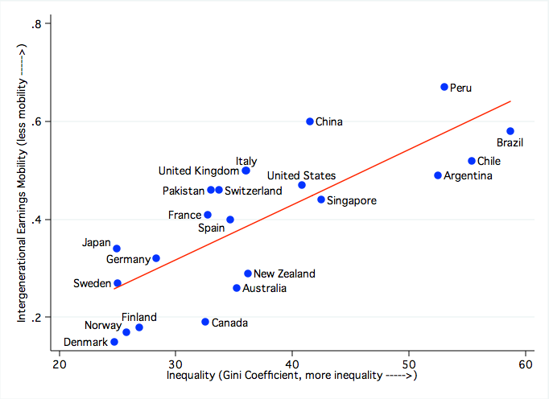

了不起的盖茨比曲线（22 国）。横轴是收入不平等，纵轴是代际收入弹性。图片来源：[Miles Corak](https://milescorak.com/2017/06/26/the-great-gatsby-curve-and-the-world-bank/)，版权归原作者所有。

注意它量的是代际那一支——所以它恰恰说不了代内那一支。至于本文的模型跟这条曲线对不对得上，等第 6.2 节把继承规则量出来之后再回来算账。

本文对这两个量的交代，一次说完。代际那一支做了（第 6.2 节那三行继承规则）；代内那一支也做了（第 7.1 节的位次秩相关）。唯独收入的永久／暂时分解没做——而按上面的分析，恰恰是它才最对得上本节这两个世界。原因不是麻烦，是这个模型没有资格做：岛上没有生产，给不出时间尺度确定的收入流。第 7.2 节把这条边界说清楚。

### 4.6.2 那么流动性是不是越高越好

到这里为止全是事实层。但真正要问的是下一句：阶层流动性高，是不是就是好事？

最直觉的答案是“当然”。但这个“当然”里混进了一个不属于它的东西。

过去几十年，全世界的收入普遍在涨。于是“变动”这个词在人们心里默认是向上的：孩子过得比父母好、这一代比上一代强。可那是绝对流动性——它量的是“日子有没有变好”，而它之所以能普遍为正，靠的是增长，不是位次的重排。美国这个数从 1940 年出生队列的约 90% 掉到 1980 年代的约 50% (Chetty et al. 2017)，掉的也主要是增长和分配，不是谁跟谁换了位子。

阶层流动性不是这回事，它是零和的。位次是一个排列：有人上去，必然有人下来，一个不多一个不少。全社会的位次变动加起来恒等于零——这不是经验规律，是定义。所以“流动性高”从来不等于“大家都在往上走”，它只等于“上上下下的人都更多”。

那上和下对称吗？在位次上严格对称，在别的每一处都不对称：

- 换算成财富不对称。分布是右偏的，顶端那一格比底端那一格宽得多。同样跨一个十分位，在顶端换来的财富远多于在底端失去的。
- 上下粘不粘也不对称，而且看机制。第 7.1 节会把这个 $\rho$ 按十分位拆开：同一个流动性读数，可以是“上下一样牢”，也可以是“顶端锁死、底端还在换人”。
- 在本文这个模型里也不对称。0 是一堵墙：往下跌有底，往上没有上限。
- 感受上更不对称。掉下去的痛，一般大于同样幅度爬上来的快。

所以“流动性高”这句话，对一个已经在上面的人和一个在下面的人，说的根本不是同一件事。这也是为什么不能把它当成一个越大越好的分数。

回到那两支。对代际那一支，“越流动越好”基本站得住：位置若能由父辈预测，预测力来自财富传递而非本人——穷人的后代该有机会上去，只靠出身占着高位的该掉下来。这一支上争议不大。

但同一句话搬到代内那一支，立刻就不成立了。一个人一生之内位置换个不停，可以是好事（他有机会翻身），也可以是坏事（他做什么都不算数，位置纯由噪声决定）。反过来，位置几十年不动也未必坏：如果一个人确实更能干，那他持续待在高位并不构成问题。

所以“流动性高不高”这个问法本身不够用。它只说位置换不换人，说不出位置到底追踪着什么。而好坏恰恰挂在后面这一问上：位置追踪能力，那么它持续就说得过去；位置追踪运气，那么它持续就只是把噪声固化下来。

而“说得过去”三个字，最顺口的辩护是“有能力的人应得更多”——这条路走不通。它要正面承担一个很硬的反驳：能力本身也是抽签的结果——基因、家庭、时代、押中哪个行业。既然如此，凭什么运气得来的财富叫“德不配位”，而能力得来的就名至实归？两者都是没选择过的初始条件。

这个反驳对“应得”是致命的，而它正是本文换一条路的理由。换的那条路绕开“应得”，只问一件事：把资源放在谁手里，产出更多。

顺带说两句这个问题的来历，免得读起来像本文自己想出来的。

其一，“能力给定也未必配得上成功”是能算出来的。Pluchino 等人做过一个模型：才华服从正态分布 $N(0.6,\,0.1)$，资本按乘性演化，中间随机撒下幸运与不幸的事件。结果是高斯的才华配上幂律的成功——一万次运行里，最成功那个人的才华均值是 0.667——高于总体均值 0.6，但只高出 0.67 个总体标准差，远不足以把最成功解释成最有才华。原文强调的正是这个右移：赢家里确实富集了才华，只是富集得很浅。另一头也有数：才华高于 0.7 的人里，只有三分之一最终高于自己的初始资本 (Pluchino et al. 2018)。才华是成功的必要非充分条件。口径要点破：他们有外生的幸运事件和乘性资本，本文是守恒交换，两者不是同一个模型；但两边指向同一件事——即便能力是给定的，成功也不会跟着能力走。

其二，“能力是抽签得来的”这个反驳，在经济学里有一个五十年的处理传统。机会平等文献把决定结果的东西分成环境（circumstance，个人不该负责的）与努力（effort，该负责的），难处正是两者在数据上分不开。Roemer 的做法很值得点出：他不去分辨努力与禀赋，而是用“同一类型内部的位次”来定义努力——理由是“类型内那个分布的形状本身就是一种环境” (Roemer and Trannoy 2015)。这和本文用秩相关来量流动性是同一个动作：不去问某个人的绝对水平，只问他在自己那一群人里排第几。

换到这个问法之后，“能力是不是抽签得来的”根本不构成问题。一个人的能力是天生的、是被培养的、还是纯属走运碰上了，对产出没有影响——抽签得来的能力照样能产出。所以运气和能力的区别之所以要紧，不在应得不应得：

> 人们本能反感“德不配位”——更准确地说，是才不配位。这条直觉底下压着一个事实判断：能力是关于产出的信号，运气不是；位置若纯由运气产生，资源还一直留在那儿，整体产出就被压低了。看起来最像道德的那个判断，其实一直在替效率说话。

所以本文不谈应得，只谈一件可以量的事：位置里有没有信息。

这条路的分量要一次交代清楚。上面那句“能力是关于产出的信号，运气不是”是这个问法自带的概念前提——它规定了在这条路上“能力”指什么，不是本文测出来的结论：岛上没有生产，量不了任何东西的产出。上面那句“整体产出就被压低了”同样是前提不是结论——它说的是这条路为什么值得走，不是本文算出来的数。而真要去量“位次里携带了多少关于能力的信息”，需要一个财富与能力的联合统计量，本文也没有算（第 7.2 节说明为什么）。所以本节做的只有一件事：把判据提出来，并说明它为什么比“应得”更好谈。至于“信息量高的配置为什么产出更高”，那需要一个能直接算产出的生产模型，是姊妹篇《公平与效率：同一个温度》的正题。

顺带说破一件本文早就证了、却一直没点明的事：第 2 到第 4 章那座岛上每个人的能力完全相同——而基尼照样是 0.5。这不是修辞，是个恒等式：没有被建模的东西，位次里不可能携带关于它的信息。（Pluchino 等人从另一个方向撞见过同一类现象：才能是高斯的，财富却是幂律的，而最有才能的人几乎从不到达顶峰 (Pluchino et al. 2018)。那是另一个风格化模型，不构成对本文设定的验证。）

顺着“信息”这条线，那两个量的方向就不再是并列的，而是同一条判据的两次应用——但两次的方向相反。必须写成条件命题，因为它们依赖的假设都不是本模型的结论：

- 代际：*若*(i) 子代能力与父代能力独立，*且*(ii) 父辈位置对子辈位置的影响只经由财富传递（模型中不存在教育、健康、网络、社区等其他出身通道），*则*秩–秩相关低意味着位置更少由出身决定。
- 代内：*若*(i) 同一个人的能力在所考察期间大致固定，*且*(ii) 比较的是保均值的外生风险、终身资源与机会集固定、个体风险厌恶，*则*暂时成分低意味着位置更少由随机冲击决定。

这四个“若”都不是模型证出来的，是外加的假设。少了任何一个，方向就可能反过来——比如若出身还经由教育起作用，那么“秩–秩相关低”就不再等价于“位置更少由出身决定”。

三个量因此各有各的读法：

| 量 | 它测什么 | 在什么条件下更可取 |
| --- | --- | --- |
| 代际秩–秩相关 | 父辈位置能预测子辈位置多少 | 在上面代际那两个假设下，低者意味着位置更少由出身决定 |
| 代内的暂时成分（本文未做分解，只在财富位次上做过类比——见第 7.2 节） | 同一个人逐年收入里随机起落的那一份 | 在上面代内那两个假设下，低者意味着位置更少由随机冲击决定 |
| 代内的永久成分 | 同一个人收入里持久的那一份 | 本身无所谓好坏——它只说明位置差异是持久的，不说明持久性从何而来 |

第三行要特别小心：它的好坏不由前两行推出来。说“永久成分的好坏取决于代际指标”是一个没有根据的蕴含——两者测的是不同世代结构上的不同东西。本文不主张这种依赖关系。

收个尾。这一节自始至终回答的都是在什么条件下更可取，而不是为什么那样更好。前者本文能给，后者要等生产模型。

# 5 能坏到什么程度：把相变算出来

基线立住了：程序完全公平，结果的基尼系数是 0.5。而第 4.3 节已经给出了另一端：同样是每一笔都公平，只把赌注改成按比例，财富就一路凝聚到一个人手里。

于是“能坏到什么程度”这一问看上去已经有答案了——最坏就是 1。但那个答案是退化的。yard-sale 没有稳态，也没有旋钮可拧：它只有一个终点，没有路。你没法问“推到哪一步会出事”，因为它从头到尾只有一种行为，差别仅仅在于跑了多久。

真正要问的是别的：有没有一整族稳态？有没有一个可以连续拧的参数？拧到哪里，行为会突然换一种性质？第 2 到第 4 章那座岛一个都给不了——零和加性的交换只有一个固定的平衡态，指数分布，人均一万枚金币也好一百枚也好，形状都是那一条。没有可调的参数，就谈不上“推到多远”，更谈不上相变。

所以这一章换一个模型，并给它装上一个旋钮：金币能生息，而利率带随机性。期望回报人人相同，只是实际到手的有涨落——涨落有多大，就是那个旋钮，本章一律记作 $\sigma$。旋钮之外沿用的是第 3 章那个连续版的“合并劈分”变体——两个人相遇，把财富合起来再随机分开；不是第 2 章那座岛的“每次交一枚金币”。两者是不同的交换核，后面比较 yard-sale 时还要用到这个区别。

## 5.1 答案先摆在这里

先把这一章算出来的结果摆上，后面各节再逐条拆开。

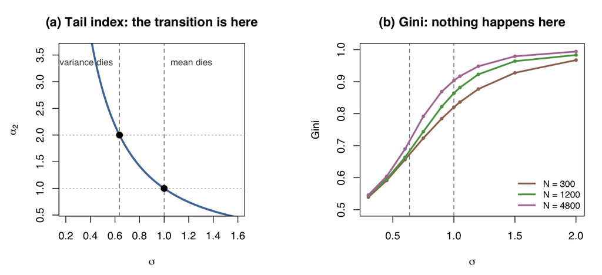

```r
## 左栏：解析的尾指数曲线。
## 右栏：同一根 σ 轴上的基尼——三档人口，用来说明它为什么当不了判据。
.af_blue <- "#4E79A7"; .af_acc <- "#D62728"
par(mfrow = c(1,2), mar = c(4.6,4.6,3.4,4.4), family = "sans")
.af_sg <- seq(0.2, 1.6, length.out = 300)
.af_al <- vapply(.af_sg, alpha2, numeric(1))
plot(.af_sg, .af_al, type = "l", lwd = 3, col = .af_blue, ylim = c(0.6, 3.6),
     xlab = expression(sigma), ylab = expression(alpha[2]),
     main = "(a) Tail index: the transition is here")
abline(v = c(sigma_c_var, sigma_c_mean), lty = 2, col = "gray45")
abline(h = c(2, 1), lty = 3, col = "gray70")
points(c(sigma_c_var, sigma_c_mean), c(2, 1), pch = 19, cex = 1.3)
text(sigma_c_var, 3.35, "variance dies", col = "gray30", cex = 0.85, pos = 2)
text(sigma_c_mean, 3.35, "mean dies", col = "gray30", cex = 0.85, pos = 4)
## 这里曾经挂过一条"前 1% 占多少"的右轴，用纯 Pareto 的 p^(1-1/α) 换算。已删除：
## 那个公式要求整条分布都是 Pareto，而本模型只有尾巴是；机械代入在 α<1 处会给出
## 超过 100% 的份额（σ=1.1 处 215%），可见其定义域已经结束。直观读数改用模拟实测值。

par(mar = c(4.6,4.6,3.4,1.4))
.af_N <- c(300, 1200, 4800); .af_col <- c("#9C755F", "#59A14F", "#B07AA1")
plot(NA, xlim = range(sigs), ylim = c(0.5, 1), xlab = expression(sigma), ylab = "Gini",
     main = "(b) Gini: nothing happens here")
abline(v = c(sigma_c_var, sigma_c_mean), lty = 2, col = "gray45")
## 一次跑完、两个读数都留下：基尼给右图，前 1% 份额给正文的白话读数。
.af_stat <- lapply(.af_N, function(N)
  sapply(sigs, function(sg) rowMeans(sapply(1:6, function(sd) one(sg, sd, N = N)))))
.af_G <- lapply(.af_stat, function(M) unname(M["gini", ]))
for (k in seq_along(.af_N)) {
  lines(sigs, .af_G[[k]], col = .af_col[k], lwd = 2.6)
  points(sigs, .af_G[[k]], col = .af_col[k], pch = 19, cex = 0.6)
}
legend("bottomright", sprintf("N = %d", .af_N), col = .af_col, lwd = 2.6, bty = "n", cex = 0.85)
```

```r
## 临界档的基尼随人口漂移；亚临界档同样在漂——所以漂移不是相变的信号。
.af_ic <- which(sigs == sigma_c_mean); .af_i9 <- which(sigs == 0.9)
for (k in seq_along(.af_N)) {
  reg(paste0("G_at_crit_N", k), .af_G[[k]][.af_ic], "mean", "§5.1 answer_fig",
      sprintf("sigma=1、N=%d 的基尼", .af_N[k]))
  reg(paste0("G_at_sub_N", k), .af_G[[k]][.af_i9], "mean", "§5.1 answer_fig",
      sprintf("sigma=0.9、N=%d 的基尼", .af_N[k]))
  reg(paste0("G_N", k), .af_N[k], "derived", "§5.1 answer_fig", "基尼面板的人口档")
}
for (nm in c("09","10","12")) {
  .af_i <- which(abs(sigs - as.numeric(paste0(substr(nm,1,1), ".", substr(nm,2,2)))) < 1e-9)
  reg(paste0("top1_s", nm), .af_stat[[3]]["top1", .af_i], "mean", "§5.1 answer_fig",
      sprintf("sigma=%s、N=4800、6 种子的前 1%% 份额", nm))
}
## 基尼随 σ 单调上升且无拐点可读。它向 1 饱和，所以线性相关系数并不接近 1——
## 要查的是"单调"，用秩相关；6 种子下允许相邻档的微小逆序。
stopifnot(.af_G[[3]][length(sigs)] - .af_G[[3]][1] > 0.3,
          cor(sigs, .af_G[[3]], method = "spearman") > 0.98,
          all(diff(.af_G[[3]]) > -0.01))
```

控制参数是 $\sigma$，不是基尼。左图那条曲线是不动点的尾指数 $\alpha_2(\sigma)$——尾巴越重，它越小。$\alpha_2$ 跌破 2 就没有方差，跌破 1 就没有均值。

要一个白话读数，用模拟实测的“前 1% 占多少”：$\sigma=0.9/1.0/1.2$ 时分别是 49%／57%／70%。

**细节：为什么这个份额不能由尾指数换算出来（可跳过）**

注意这不能由 $\alpha_2$ 换算出来：幂律那套 $p^{1-1/\alpha}$ 的公式要求整条分布都是 Pareto，而这里只有尾巴是——机械代入在 $\alpha_2<1$ 处甚至会给出超过 100% 的“份额”。$\alpha_2$ 管的是尾巴的重量，不是任何一段人口的份额。

真正跳变的量是“均值能不能活过极限”。$\sigma<1$ 时能：迭代收敛到一个均值为 1 的分布，财富有典型尺度。$\sigma\ge1$ 时不能：随机抽到的那个人的财富分布向零集中，而平均值仍是 1——它被越来越稀少、越来越大的少数人撑着。这个“能／不能”就是这一章的序参量，它在 $\sigma=1$ 处从 1 掉到 0。（冰水那个类比：$\sigma$ 是温度，这个量才是固体分数。）

四重极限的位置，就这样被算了出来：

- 第一重，描述崩塌。分两步：$\alpha_2$ 跌破 2，方差不再存在，位置 $\sigma=0.63676$；再跌破 1，均值也不再存在，位置 $\sigma=1$。两道边界是同一条曲线穿过两个整数，不是两套理论。
- 第二重，个体沉没。典型个体趋于零而系综均值不动——正是上面那个序参量掉到 0。位置 $\sigma=1$。
- 第三重，集体退场。持有固定财富份额所需的人口比例趋于零。同一个位置 $\sigma=1$。
- 第四重，交换冻结。本模型里不存在。财富连续、每一对无条件成交，没有“付不出钱”这回事。它属于另一根轴（金币的稀缺程度），下面会单独说清。

（这四重落在基尼的哪一带？本节末尾有一张路标表。）

所以四重不是四件先后发生的事：第一重的前半段先到（$\sigma\approx0.64$），接着第一重的后半段、第二重、第三重同处 $\sigma=1$——同一个条件把它们一起触发；第四重根本不在这根轴上。

至于基尼，右图就是它的全部答案：什么也没发生。两条竖线处曲线光滑通过，没有拐点、没有跳变。更麻烦的是三条曲线彼此分开——同一个 $\sigma$，基尼随人口规模漂移（$\sigma=1$ 处 0.82／0.86／0.90，对应 N = 300／1200／4800）。而且亚临界的 $\sigma=0.9$ 同样在漂（0.78／0.82／0.87），所以这个漂移不能读成“正在接近凝聚”——它两侧都有。

> 这些有限人口、有限时程的基尼读数定不出临界点，也给不出一个通用的“临界基尼”。

那有没有一个既直观、又真的带着相变指纹的量？有一个很接近的：多少人握着一半的财富。

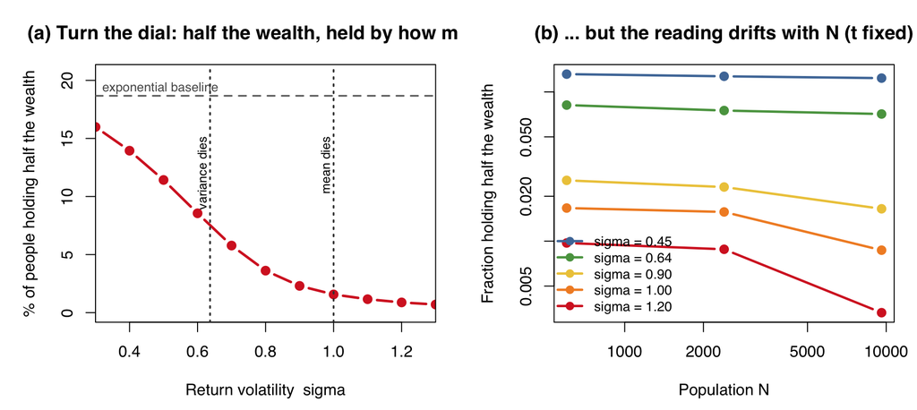

```r
## 握住一半财富所需的人口比例。理论上：alpha2>1（均值有限）时它收敛到一个正常数；
## alpha2<1 时，在先人口、后时间的次序下它趋于零。下图是固定时间的人口敏感度，不是那个渐近极限。
p_half <- function(w){ v <- sort(w, decreasing = TRUE); which(cumsum(v) >= 0.5*sum(v))[1]/length(v) }
PH_ROUNDS <- 1000                       # 这张图的时程，正文那条口径注要引它
## 指数基线是解析的：top-p 份额 = p(1 - log p)，令其等于 1/2。
.ph_exp <- uniroot(function(x) x*(1-log(x)) - 0.5, c(1e-6, 0.5), tol = 1e-12)$root
reg("p_half_exp", .ph_exp, "analytic", "§5.1 p_half_scaling", "指数基线下握住一半财富的人口比例")
.ph_N <- c(600, 2400, 9600); .ph_sg <- c(0.45, sigma_c_var, 0.9, sigma_c_mean, 1.2)
## 90 个独立任务（3 个 N x 5 个 sigma x 6 个种子），铺平后一次并行。
## one_w() 自带 set.seed，与串行逐位相同；行=sigma、列=N 的形状与原来一致。
.ph_grid <- expand.grid(sd = 1:6, sg = seq_along(.ph_sg), N = seq_along(.ph_N))
.ph_raw <- unlist(parallel::mclapply(seq_len(nrow(.ph_grid)), function(k)
  p_half(one_w(.ph_sg[.ph_grid$sg[k]], .ph_grid$sd[k],
               N = .ph_N[.ph_grid$N[k]], rounds = PH_ROUNDS)), mc.cores = .PAR))
.ph <- matrix(apply(matrix(.ph_raw, nrow = 6), 2, mean), nrow = length(.ph_sg))
for (k in seq_along(.ph_sg))
  reg(paste0("p_half_s", k), .ph[k, 2], "mean", "§5.1 p_half_scaling",
      sprintf("sigma=%.4f、N=2400 时握住一半财富的人口比例", .ph_sg[k]))
## (a) 直观读数：只拧 sigma，人口与轮数固定。11 档 x 6 个种子，一次并行。
.ph_sg2 <- seq(0.3, 1.3, by = 0.1)
.ph_g2  <- expand.grid(sd = 1:6, sg = seq_along(.ph_sg2))
.ph_r2  <- unlist(parallel::mclapply(seq_len(nrow(.ph_g2)), function(k)
  p_half(one_w(.ph_sg2[.ph_g2$sg[k]], .ph_g2$sd[k], N = .ph_N[2], rounds = PH_ROUNDS)),
  mc.cores = .PAR))
.ph2 <- colMeans(matrix(.ph_r2, nrow = 6))
stopifnot(.ph2[1] > .ph2[length(.ph2)],
          cor(.ph_sg2, .ph2, method = "spearman") < -0.95)

PHC <- c("#4E79A7", "#59A14F", "#EDC948", "#F28E2B", "#D62728")
par(mfrow = c(1, 2), mar = c(4.6, 5.0, 3.4, 1.2), family = "sans")
plot(.ph_sg2, 100*.ph2, type = "b", pch = 19, lwd = 2.6, col = "#D62728",
     ylim = c(0, 100*max(.ph_exp, max(.ph2))*1.1), xaxs = "i",
     xlab = "Return volatility  sigma", ylab = "% of people holding half the wealth",
     main = "(a) Turn the dial: half the wealth, held by how many?")
abline(h = 100*.ph_exp, lty = 2, lwd = 1.8, col = "gray45")
text(0.32, 100*.ph_exp, "exponential baseline", adj = c(0, -0.5), cex = 0.8, col = "gray35")
abline(v = c(sigma_c_var, 1), lty = 3, lwd = 1.8, col = "gray25")
text(sigma_c_var, 100*max(.ph2)*0.95, "variance dies", srt = 90, adj = c(1, -0.4), cex = 0.78)
text(1, 100*max(.ph2)*0.95, "mean dies", srt = 90, adj = c(1, -0.4), cex = 0.78)

## (b) 同一个量对人口规模的敏感度——用来说明它为什么定位不了临界点。
matplot(.ph_N, t(.ph), type = "b", pch = 19, lty = 1, lwd = 2.4, log = "xy",
        col = PHC, xlab = "Population N", ylab = "Fraction holding half the wealth",
        main = "(b) ... but the reading drifts with N (t fixed)")
legend("bottomleft", sprintf("sigma = %.2f", .ph_sg), col = PHC,
       lwd = 2.4, pch = 19, bty = "n", cex = 0.85)
```

```r
## 亚临界两档基本持平，超临界持续下滑——这是趋势判据，不是临界点定位。
stopifnot(.ph[1,3]/.ph[1,1] > 0.8, .ph[5,3]/.ph[5,1] < 0.5,
          .ph[1,3]/.ph[1,1] > .ph[5,3]/.ph[5,1])
```

左边那张图就是这一章的旋钮图，只不过纵轴换成了一个人人都能掂量的量。横轴还是 $\sigma$，纵轴是“最富的百分之几人握着全岛一半的财富”。虚线是指数基线：程序完全公平、没有回报涨落时，19% 的人握着一半。旋钮往右拧，这条线一路往下——到方差边界只剩 8%，到 $\sigma=1$ 只剩 2%。两条竖线是前面算出来的那两道边界。

这就是“能坏到什么程度”的白话版本：同样是每一笔都公平，只把回报的涨落从零拧到 1，握着一半财富的人就从一百个里的 19 个掉到 2 个。

但它只能给直觉，定位不了临界点——右边那张图就是理由。

**右图在说什么：这个量会随人口漂，所以它当不了判据（可跳过）**

右图换了横轴：固定 $\sigma$ 与轮数，把人口从 600 加到 9600，看这个比例往哪走。两档行为：$\sigma$ 小的几条基本不动，$\sigma$ 大的几条持续下滑。听上去像个判据——“会不会随人口缩小”区分两相。

可惜不是。$\sigma=0.9$ 理论上属于“该收敛到常数”的那一侧，实测到最大的那档人口仍在下滑；这个差距本文没有归因（可能是收敛慢，也可能是固定时间根本不是那个极限该看的地方）。可行的人口规模分不开 0.9 与 1.0。

而且“比例无限缩小”本来也不该是固定时间该有的行为：在任何固定时刻，无穷人口极限分布均值为 1 且二阶矩有限，由 Cauchy–Schwarz 有 $p_{1/2}\ge 1/(4EX_t^2)>0$。真正的渐近陈述必须放在先人口、后时间那个次序里说。

所以想知道临界点在哪，还是只能回到解析的 $\alpha_2$。这一点必须说死，否则就是把刚退役的“用横截面读数定位相变”换个量重犯一次。

最后把这一章换成读者最熟的那个数来读一遍。下面这张表把四重相变各自落在哪一带标出来——σ 是控制参数，基尼、前 1%、「几个人握着一半」都是读数。

| 第几重 | 什么不再存在 | σ | 基尼 | 前 1% 占有 | 一百人里几个握着一半 |
| --- | --- | --- | --- | --- | --- |
| 基线（旋钮关着） | — | 0 | 0.50（解析） | 6% | 19 个 |
| 第一重·前半 | 方差 | 0.64 | 0.67–0.71 | 23% | 8 个 |
| 第一重·后半 + 第二重 + 第三重 | 均值 | 1 | 0.82–0.90 | 57% | 2 个 |
| 第四重 | 交换本身（本模型里不发生） | 不在这根轴上 | — | — | — |

这一栏是路标，不是判据。基尼那一栏写成区间，正是因为上面刚说过的那件事：同一个 $\sigma$ 下它随人口漂，区间的两端就是 N 从 300 到 4800 的实测范围。所以这张表该读成「基尼爬到 0.8 这一带，方差其实早就没了」，不能读成「0.85 就是临界值」——临界点在哪，仍然只有解析的 $\alpha_2$ 说了算。

还有一句口径，免得把四栏当成同一次观测：基线那一行是解析值，不随人口或轮数漂；其余三行都是模拟读数，而且设定并不相同——基尼取 N = 300／1200／4800 三档、500 轮、各 6 个种子的均值（区间即三档的范围）；前 1% 取 N = 4800、同样轮数、6 种子均值；「几个握着一半」来自另一张图，N = 2400、1000 轮、6 种子均值（方差边界那一格正是 $\sigma=\sqrt{\ln 1.5}$ 落在那张图的网格上，直接取用）。三栏各自内部可比，跨栏只读趋势。

## 5.2 这个旋钮是什么，和 yard-sale 差在哪

先交代口径：这一章换了模型，但基尼仍然是财富基尼，这一点全章不变。

换模型之前，先看一个连旋钮都不用装就能坏到底的例子，因为它能一次说清“公平”这两个字有多不保险。前面第 4 章提过的 yard-sale：每次从双方较少的那份财富里拿一个固定比例 $\beta\in(0,1)$ 作赌注，抛一枚公平硬币决定输赢，总财富一分不多一分不少。规则对所有人一字不差，每一笔交易的期望都是零——可是最后只会剩下一个赢家，而每个人赢得全部的概率，正好等于他一开始持有的财富份额。

这个结论是能证出来的，一句话就是理由：只要不止一个人有钱，他们迟早会被配到一起、又要押上一笔像样的赌注，局面就静不下来；而有限的家底经不起无穷无尽地晃——两头一挤，最后只能剩一个人。至于是谁，纯看运气。

**细节：把它证严格——顺带交代”鞅”是什么**

上面那句理由，对应的工具叫鞅（martingale）。yard-sale 不是本章主线，读者尽可跳过这一段；但这一章后面还会再用到鞅两次，所以在这里一并交代。

鞅就是“公平赌局”这四个字的数学名字。一个随时间变化的随机量，如果在已知此刻全部信息的前提下，下一步的期望正好等于此刻的值，它就是一个鞅。硬币不偏、赌注对等，所以岛上每个人的财富都是鞅：今天有多少，明天在期望意义上还是多少——尽管实际上它每一轮都在抖。“期望不变”完全不等于“不动”——正是这个区别撑起了上面那句理由。

再加一个条件：这里的财富还有界——不会为负，也不可能超过全岛总量。而概率论有一条很硬的定理：有界的鞅几乎必然收敛（“几乎必然”意思是例外情形加起来的概率为零）。这就是“经不起无穷无尽地晃”的严格版本。

于是完整的论证是：每个人的财富 $w_{i,t}$ 都是非负有界鞅，所以几乎必然收敛。如果两个人的极限财富都为正，就存在 $\varepsilon>0$，使他们此后都至少有 $\varepsilon$。全局随机配对让这两个人无限次相遇，每次的财富跳动至少为 $\beta\varepsilon$，与收敛所需的增量趋零矛盾——这是“局面静不下来”的严格版本。因此至多一个人的极限为正；总量守恒又保证至少一个。由有界收敛，$Ew_{i,\infty}=w_{i,0}$，而极限财富只有 $0$ 与全岛总量两个取值，于是

$$P(i\text{
最终通吃})=\frac{w_{i,0}}{\sum_jw_{j,0}}.$$

这是关于有限人口、无限时间的结论。它也说明：不能把每个人的负对数漂移直接读成所有人最终都趋零；赢家是随机的，但总有一个。

但 yard-sale 帮不上这一章的忙，理由和那座岛一样，只是方向相反：它的结局是写死的。不管 $\beta$ 取多少，无限时间的结局永远是“一个人通吃”（有限轮数下，所有人都还剩一点）。$\beta$ 只改变到达那里的快慢，不改变去哪里。一个只有一种结局的模型，同样没有相变可谈——相变的意思是：参数在某个值的两侧，系统去往性质不同的两个地方。

所以需要第三个模型：既不像那座岛那样只有一种平衡态，也不像 yard-sale 那样只有一种结局。这一章装的旋钮是现实里最常见的那一个——金币能生息，而利率带随机性。期望回报人人相同，只是实际到手的有涨落；涨落有多大，就是那个旋钮。

具体规则是乘性回报 + 合并劈分：每轮先让每个人的财富乘上一个随机回报，再全局随机两两配对，把双方财富并在一起、随机切成两份，最后统一除以当轮均值（这一步只是换算单位，把“人均一份”固定下来）。人人面对同一种回报分布，区别只在实际抽到哪一次涨落。把所有人共有的那部分漂移消掉之后，回报可以写成

$$R=e^{\sigma Z-\sigma^2/2},\qquad Z\sim
N(0,1),\qquad ER=1.$$

$\sigma$ 就是旋钮：它越大，同样的期望回报下，实际到手的越分散。模型里没有外生工资，也没有把人往回拉的加性托底——能不能挡住集中，全靠合并劈分自己。

那么“合并劈分”和刚才那个必然通吃的 yard-sale，到底差在哪？两条规则都守恒、都对所有人一字不差，听上去像是同一类东西。差别只有一条，但它决定了全部结局：

均值归一到 1。yard-sale 每笔交易都是公平赌局，所以个人财富的期望原地不动；合并劈分不是赌局，它把两人的家底重新洗一次。

| 一次相遇 | yard-sale | 本章：合并劈分 |
| --- | --- | --- |
| 拿多少出来 | 较穷一方财富的固定比例 β | 两人财富全部并进一个池子 |
| 怎么定输赢 | 抛公平硬币，赢家拿走赌注 | 池子随机切一刀，各拿一段 |
| 交易后的期望财富 | E[w′\|w] = w（原封不动） | E[w′\|w] = (w + 1)/2 |
| 比均值多出的那部分 | 不动它 | 每轮砍掉一半 |
| 长期结局 | 必然一人通吃 | 看 σ：两种结局 |

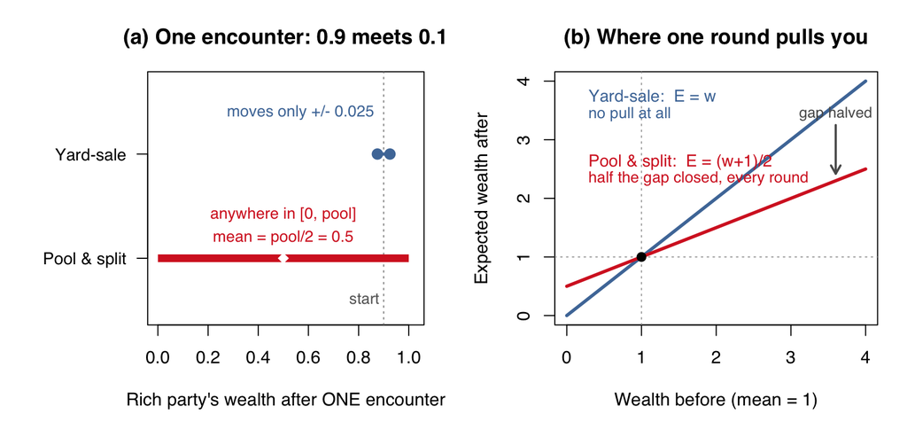

```r
ACC <- "#D62728"; BLU <- "#4E79A7"
par(mfrow = c(1,2), mar = c(4.6,7.0,3.4,1.4), family = "sans", cex.lab = 1.02)
## (a) 同一次相遇，两条规则各自能把富人送到哪里。
.rc_rich <- 0.9; .rc_poor <- 0.1; .rc_beta <- 0.25
.rc_stake <- .rc_beta*min(.rc_rich, .rc_poor)
reg("rule_stake", .rc_stake, "analytic", "§5.2 rule_contrast_fig", "yard-sale 单次赌注（β=0.25，富 0.9 遇穷 0.1）")
reg("rule_pull", 0.5, "analytic", "§5.2 rule_contrast_fig", "合并劈分每轮保留的偏离比例")
plot(NA, xlim = c(0,1.02), ylim = c(0.45,2.7), yaxt = "n",
     xlab = "Rich party's wealth after ONE encounter", ylab = "",
     main = "(a) One encounter: 0.9 meets 0.1")
axis(2, at = c(2,1), labels = c("Yard-sale","Pool & split"), las = 1, cex.axis = 0.95)
abline(v = .rc_rich, lty = 3, col = "gray55")
segments(.rc_rich-.rc_stake, 2, .rc_rich+.rc_stake, 2, col = BLU, lwd = 3)
points(c(.rc_rich-.rc_stake, .rc_rich+.rc_stake), c(2,2), pch = 19, col = BLU, cex = 1.3)
text(.rc_rich-.rc_stake, 2.40, sprintf("moves only +/- %.3f", .rc_stake),
     col = BLU, cex = 0.90, pos = 2, offset = 0.15)
segments(0, 1, 1, 1, col = ACC, lwd = 7, lend = 1)
points(0.5, 1, pch = 18, col = "white", cex = 1.4)
text(0.5, 1.42, "anywhere in [0, pool]", col = ACC, cex = 0.90)
text(0.5, 1.20, "mean = pool/2 = 0.5", col = ACC, cex = 0.90)
text(.rc_rich, 0.60, "start", col = "gray40", cex = 0.88, pos = 2, offset = 0.2)
## (b) 一轮之后的期望：yard-sale 落在 45 度线上，合并劈分把偏离砍半。
par(mar = c(4.6,4.8,3.4,1.4))
.rc_w <- seq(0, 4, length.out = 200)
plot(.rc_w, .rc_w, type = "l", lwd = 3, col = BLU, xlab = "Wealth before (mean = 1)",
     ylab = "Expected wealth after", main = "(b) Where one round pulls you")
lines(.rc_w, (.rc_w+1)/2, lwd = 3, col = ACC)
abline(h = 1, v = 1, lty = 3, col = "gray65"); points(1, 1, pch = 19, cex = 1.1)
text(0.15, 3.72, "Yard-sale:  E = w", col = BLU, cex = 0.95, pos = 4)
text(0.15, 3.44, "no pull at all", col = BLU, cex = 0.88, pos = 4)
text(0.15, 2.62, "Pool & split:  E = (w+1)/2", col = ACC, cex = 0.95, pos = 4)
text(0.15, 2.34, "half the gap closed, every round", col = ACC, cex = 0.88, pos = 4)
arrows(3.6, 3.25, 3.6, 2.42, length = 0.09, lwd = 2, col = "gray35")
text(3.6, 3.45, "gap halved", col = "gray35", cex = 0.85)
```

```r
## 自检：两条期望线就是表里那两式。
stopifnot(abs((0.5*(3+1)) - 2) < 1e-12, abs(.rc_stake - 0.025) < 1e-12)
```

左图：单看一次相遇，合并劈分反而粗暴得多。yard-sale 里那个富人只动了 0.025；合并劈分却可能把他从 0.9 一路打到接近 0，也可能让他吃下整个池子。

右图才是要害，而且它把“为什么不会必然通吃”一次说清。yard-sale 的每一笔都是公平赌局，所以交易后的期望财富恰好等于交易前——那条线就是 45 度线，没有任何力量把偏离均值的人拉回来。财富于是做无偏随机游走。但它不会在有限时间内真的归零——输家至少保住 $(1-\beta)$ 倍，所以谁都不会“撞上 0”；只是在无限时间的极限下，除了那个随机产生的赢家，其余人的财富都趋于零。合并劈分不是赌局，它把两人的家底重新洗一次：期望变成 $(w+1)/2$，比均值多出来的那部分，每轮被砍掉一半。这是一股实打实的回复力。

所以本章这条规则“温和”，不在于每笔交易更客气——恰恰相反——而在于它每一轮都在抹平已经拉开的差距。

于是一章之内就有了两股相反的力：合并劈分把差距砍半，随机回报让走运的人乘得更多、把差距重新拉开。谁赢，取决于 $\sigma$——而“相变”正是这场胜负易主的那个位置。

顺带把一个容易硌住的地方说破：第 3 章说平衡态是指数分布，这一章却会一路谈幂律尾，两者并不矛盾——它们属于两个模型。后者是前者装上乘性回报之后的样子。而且待会儿会看到一件更整齐的事：把旋钮拧到零，这一章的公式会精确地退回指数分布，第 3 章那条基线就躺在本章这条曲线的起点上。

```r
## 每档只跑一次，均值与标准差都从同一批结果里出——原先 M 和 S 各跑一遍，白算一倍
RAW <- lapply(sigs, function(sg) sapply(1:SC_K, function(sd) one(sg, sd)))
M <- sapply(RAW, function(A) rowMeans(A))
S <- sapply(RAW, function(A) apply(A, 1, sd))
reg("capital_06", M["gini", which(sigs == 0.6)], "mean", "§5.2 collapse_scan", sprintf("%d 个种子的均值", SC_K))
reg("capital_12", M["gini", which(sigs == 1.2)], "mean", "§5.2 collapse_scan", sprintf("%d 个种子的均值", SC_K))
```

## 5.3 第一重与第三重：同一条曲线穿过 2 和 1

答案里说，第一重分两步、第三重和均值那道边界重合。这一节说明为什么。

先把本章和第 3.5 节的分工钉死，因为两边都在讲幂律。第 3.5 节那条恒等式说的是幂律长什么样，尾指数 $\alpha$ 由谁定它没说；第 2.7 节那条 Fokker–Planck 定了一个：把漂移与扩散都设成按比例（$A=ar$、$B=br^2$），稳态解的尾指数就是 $\alpha=1+a/b$ (Ludwig and Yakovenko 2022)，而 $a,b>0$ 意味着它恒大于 1。本章要找的边界恰恰在 $\alpha_2$ 穿过 2、再穿过 1 的地方，那条路永远够不到。所以这一节不是把前面的话再说一遍：它进的是另一个区间，而且靠的是一条守恒的交换规则，不外加任何回复项。

先跑一眼模拟，看看拧大 $\sigma$ 究竟发生了什么。下面三条曲线出自同一条规则，只改了 $\sigma$；纵轴是“比这个财富更富的人占多大比例”，双对数坐标。

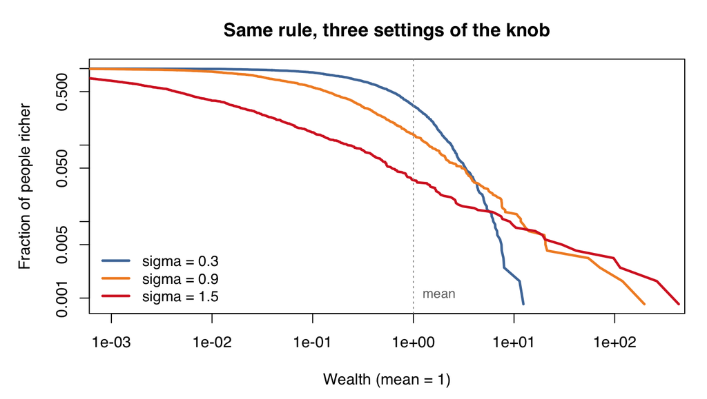

```r
## 与 collapse_scan 里的 one() 同一个核，只是把最终的财富向量整个留下来画图。
.ti_run <- function(sig, seed = 1, N = CH5_N, rounds = CH5_R)
  sort(one_w(sig, seed, N, rounds), decreasing = TRUE)
.ti_sg <- c(0.3, 0.9, 1.5); .ti_col <- c("#4E79A7", "#F28E2B", "#D62728")
.ti_w <- lapply(.ti_sg, .ti_run)
for (k in seq_along(.ti_sg))
  reg(paste0("tail_max_", k), max(.ti_w[[k]]), "point",
      "tail_intuition", sprintf("sigma=%.1f 单次实现的最富者（人均=1）", .ti_sg[k]))
par(mar = c(4.6,4.8,3.2,1.2), family = "sans")
plot(NA, xlim = c(1e-3, 3e2), ylim = c(1/1200, 1), log = "xy",
     xlab = "Wealth (mean = 1)", ylab = "Fraction of people richer",
     main = "Same rule, three settings of the knob")
for (k in seq_along(.ti_sg))
  lines(.ti_w[[k]], seq_along(.ti_w[[k]])/length(.ti_w[[k]]), col = .ti_col[k], lwd = 2.6)
abline(v = 1, lty = 3, col = "gray60")
text(1, 1/900, "mean", col = "gray45", cex = 0.85, pos = 4)
legend("bottomleft", sprintf("sigma = %.1f", .ti_sg), col = .ti_col, lwd = 2.6,
       bty = "n", cex = 0.95)
```

看得很清楚：$\sigma$ 越大，尾巴越肥。最富的那个人从人均的 12 倍，涨到 197 倍、再到 433 倍；曲线在双对数纸上也越来越接近直线，也就是越来越像幂律。

但模拟到此为止了。它让人看见“尾巴变重”，却答不出这一章真正要问的那一问：质变到底发生在哪一个 $\sigma$。肉眼分不出 0.9 与 1.0 有什么本质不同；而想靠在这种图上拟合一条直线把指数量出来，还有一个更麻烦的问题——有限人口、有限轮数下量出来的斜率，和“尾巴的渐近指数”根本不是同一个东西（解析曲线与有限模拟放在一起会把这两者的差距摆开）。

好在这个模型不必靠估。往回追一个人的财富来源，会得到一棵二叉的家系树；人口足够多时树枝几乎不会撞在一起，于是整件事变成一个有现成定理可用的标准对象——**平滑变换**。尾巴因此可以直接解出来。怎么解放在下面的折叠里，这里先说结论。

结论是一条曲线。把不动点的尾指数记作 $\alpha_2(\sigma)$，即 $P(X>x)\sim Cx^{-\alpha_2}$ 中的那个指数。它由一个一维方程定死——注意这个方程恒有 $\alpha=1$ 这个解（均值被归一化钉死），$\alpha_2$ 取的是它的另一个正根；在 $\sigma=1$ 处两根合并，按连续性取 1：

$$\boxed{\log\frac{\alpha_2+1}{2}
=\frac{\sigma^2}{2}\alpha_2(\alpha_2-1)}.$$

它不是拿基尼反推出来的参数，也不是对模拟上尾回归得到的斜率，求数值只需一维求根。

而两道边界，是同一条曲线穿过两个整数。尾巴多重决定了哪些矩还活着：$\alpha_2$ 跌到 2 以下，方差不再存在；再跌到 1 以下，连均值都不再存在。所以不需要两套理论——一条 $\alpha_2(\sigma)$ 依次穿过 2 和 1，就是两道边界。

两道边界分别在 $\sigma=\sqrt{\ln(3/2)}\approx0.63676$ 和 $\sigma=1$。前者的尾指数为 2；后者是两根合并的位置。方差先失去有限性，随后连均值为一的不动点也不再存在。

还有一个整齐的收尾：把旋钮拧回零，这条曲线的起点正好落在前三章那条基线上。$\sigma=0$ 时递推退化成 $X\overset d=U(X_1+X_2)$，而 $\mathrm{Exp}(1)$ 是它的精确不动点（下面就有两行验算）。指数分布、基尼 0.5——第 2 到第 4 章那条基线，在这里由一个恒等式接了上来。不同的交换规则可以共享这条基线；加上回报涨落，才沿着 $\sigma$ 这根轴离开它。

最后要诚实地插一句。上面这条曲线是“尾指数的合理候选”：它指出了矩发散的门槛在哪儿，但“门槛处真的长着一条 $Cx^{-\alpha_2}$ 的尾巴”需要定理来保证，而且三个参数区间用的还不是同一条定理。下面那个折叠会把 $0<\sigma<1$ 与 $\sigma>1$ 两格补上；$\sigma=1$ 那一格的存在性本文未补齐。

第一重，描述崩塌。对本章的非零不动点，$\alpha_2\le2$ 时方差无穷，$\alpha_2\le1$ 时均值无穷。统计量先失去有限性，伤的是描述工具；有限模拟的样本均值始终被归一，不能把这里的积分发散当成模拟直接观测到了什么。

第三重，集体退场。$\sigma\ge1$ 一侧，持有固定财富份额所需的人口比例趋于零——握住一半财富的那一小撮，越跑越小。

这句话要按它的口径读：它说的是“弱凝聚”，不是“有限几个人各自握着宏观份额”那种更强的说法。两者不等价，本章只认领前一个。

还有一个能确切算出的后果：$\sigma\ge1$ 时基尼序列趋于 1。注意这是基尼序列的极限，不是极限分布的基尼——后者均值为零，基尼根本无定义。

**细节：弱凝聚与强凝聚差在哪，以及基尼趋于 1 的证明（可跳过）**

第三重，集体退场。在本章树极限的 $\sigma\ge1$ 一侧，典型个体 $X_t\to0$，而均值仍为一。任取阈值 $a>0$，阈值以下的财富 $E[X_t\mathbf1_{X_t\le a}]\to0$；阈值以上的人口比例 $P(X_t>a)\to0$，却持有趋于全部的财富。因此，持有固定财富份额所需的人口比例趋零。这是按先人口、后时间的次序得到的弱凝聚。

强凝聚要的是另一件事，得先有一把量集中程度的尺子。记 $s_i$ 为第 $i$ 个人占全部财富的份额，定义逆参与比 $Y_2=\sum_i s_i^2$：人人均分时它等于 $1/N$（很小），一个人独占时它等于 1，所以它趋不趋于零，正好分得开“集中”的两种方式。强凝聚要求 $Y_2\nrightarrow0$，即有限个个体各自持有宏观份额。两者不等价：最富 $\sqrt N$ 人每人持有 $1/\sqrt N$ 的总财富，人口比例趋零（弱凝聚成立），而 $Y_2=1/\sqrt N$ 却也趋零（强凝聚不成立）。本章没有证明有限人口稳态的强凝聚。

还有一个能确切算出的后果。对均值为一、相互独立的 $X_t,\widetilde X_t$，

$$G_t=\frac{E|X_t-\widetilde X_t|}{2}
=1-E\min(X_t,\widetilde X_t)
=1-\int_0^\infty P(X_t>x)^2\,dx.$$

$\sigma\ge1$ 时被积函数逐点趋零，而 Markov 不等式给出可积上界 $P(X_t>x)^2\le\min(1,x^{-2})$。由控制收敛，

$$\boxed{G_t\longrightarrow1\quad(\sigma\ge1).}$$

这是基尼序列的极限，不是 $\delta_0$ 的基尼；后者均值为零，基尼无定义。

**细节：合并劈分为什么没有一轮摊平**

给定切分前的份额 $\mathbf s$，随机配对并均匀劈分后，

$$E[Y_2^{\rm after}\mid\mathbf
s]=\frac23\left[Y_2+\frac{1-Y_2}{N-1}\right].$$

这里 $E[U^2+(1-U)^2]=2/3$，而随机配对的交叉项期望为 $(1-Y_2)/(N-1)$。已有的宏观集中度大约乘以 $2/3$，并没有直接压到 $O(1/N)$：巨富的财富分给一个搭档，远非摊给全体。

人口设为 400 时，这次计算从 $Y_2=0.2506$ 出发，切分后重复均值为 0.1680（标准误 0.0006），解析条件期望为 0.1683。若每组 $k$ 人合并后等分，则 $m_k(q)=k^{1-q}ER^q$，$m_k'(1)=\sigma^2/2-\log k$，边界变成 $\sigma_c(k)=\sqrt{2\log k}$。两人等分把边界抬到 1.1774。

两道边界各自其实都不必碰尾巴，一行就能算完：方差那道由一个二阶矩的放大系数与 1 比大小定下来，均值那道由鞅判据直接给出。真正需要下面那台机器的，是非零不动点的尾巴长什么样——那是另一个问题。

而把旋钮拧回零，这台机器正好接回前三章：$\sigma=0$ 时指数分布是精确不动点，基尼恰好 0.5，没有第二根，也就没有幂律尾。

**细节：两道边界各自怎么一行算完，以及 σ=0 那一端的验算（可跳过）**

先看方差那道边界，因为它只用二阶矩就能算出来，不必碰尾巴。记 $M_{2,t}=EX_t^2$，其中 $X_t$ 是先取人口极限之后被随机标记者的财富（不是有限模拟里那个已归一化的样本二阶矩——$N=2$ 时后者恒为 $4/3$，与 $\sigma$ 无关）。从均等出发、每步均值为一，它满足一条一行的递推：

$$M_{2,t+1}=\tfrac23e^{\sigma^2}\,M_{2,t}+\tfrac23.$$

放大系数是 $\tfrac23e^{\sigma^2}$（常数项 $2/3$ 来自两条路径的交叉项，与放大无关）。系数小于 1，二阶矩收敛到 $2/(3-2e^{\sigma^2})$；大于 1，指数发散；恰好等于 1 时 $M_{2,t}=1+\tfrac23t$，线性发散——所以边界那一点上方差已经没了。所以方差的存亡由这一个系数与 1 的大小一手决定，而 $\tfrac23e^{\sigma^2}=1$ 解出来正是 $\sigma=\sqrt{\ln(3/2)}\approx0.63676$——答案图上那道方差边界。

均值那道边界也不需要尾巴：它由鞅判据直接给出（$m'(1)=(\sigma^2-1)/2$ 变号）。真正需要下面那台机器的，是非零不动点的尾巴长什么样——那是另一个问题。

$\sigma=0$ 那一端也能一行算完，而且它正好接回前三章。关掉回报涨落，递推只剩 $X\overset d=U(X_1+X_2)$。（这里 $U\sim\mathrm{Unif}(0,1)$ 是那一刀的切分比例，与两份财富独立。）用 Laplace 变换验一下——对每个 $s\ge0$ 算 $E[e^{-sX}]$，得到的函数唯一确定一个非负变量的分布，所以变换前后同一个函数就是同一个分布。若两份财富独立且服从 $\mathrm{Exp}(1)$，其和服从 $\Gamma(2,1)$，随机切一刀之后

$$E\bigl[e^{-sU(X_1+X_2)}\bigr]=\int_0^1(1+su)^{-2}\,\mathrm
du=\frac1{1+s},$$

右边仍是 $\mathrm{Exp}(1)$ 的变换。指数分布是精确不动点，基尼恰好 0.5。而 $\sigma=0$ 时，下面那台机器里的权重函数退化成 $2/(q+1)$，在 $q>0$ 上只有 $q=1$ 一个根——没有第二根，也就没有幂律尾；指数尾正是“$\alpha_2=\infty$”那一端。

**细节：尾指数那台机器是怎么搭起来的（模型地基，可跳过）**

第一步，把一个人的来路看清楚。随便挑一个人，问他此刻手里的财富从哪来。上一轮，他和某个人配了对，两份财富并在一起、随机切了一刀，他拿走其中一份；而那两份财富，各自又来自上上一轮的一次配对。这样往回看 $t$ 轮，他的财富是 $2^t$ 个“祖先”的财富经过一路回报与切分汇总到他身上的结果——一棵二叉家系树。

关键的简化是：人口足够多、往回看的轮数又固定时，这棵树的分支几乎不会撞在一起（$N$ 个人里挑 $2^t$ 个祖先，重复的概率是 $O(4^t/N)$）。分支不相撞，两边来路互不相干，于是独立。这一步是全章的地基，本节末尾的折叠里会专门交代。

有了独立性，随机标记一个受方，他的财富满足

$$X_{t+1}\overset
d=UR_1X_t^{(1)}+UR_2X_t^{(2)},\qquad
U\sim\mathrm{Unif}(0,1).$$

读法：两份独立的上一轮财富各自乘上自己的随机回报，加起来，再乘以切分比例 $U$。另一位受方拿 $1-U$ 那份；因为 $1-U$ 与 $U$ 同分布，随机标记之后是同一个式子。记 $A_1=UR_1$、$A_2=UR_2$——它们共享同一个 $U$，所以彼此相关；要紧的独立性在于树上不同顶点的系数向量之间互相独立、且与后代财富独立。

这类“加权求和再迭代”的递推叫**平滑变换**：它把一个财富分布映成另一个财富分布，被它映过去还是自己的那个分布就是**不动点**——注意“是不动点”和“从某个初始分布迭代会走到它”是两件不同的事，后面正好要用到这个区别。

第二步，把“尾巴多重”换成一个更好算的问题。尾巴的重量通常用“哪些次幂的矩还有限”来刻画：方差存在就是二阶矩有限，均值存在就是一阶矩有限。所以与其盯着分布，不如问——

> 把财富的 $q$ 次幂沿这棵树往回传一层，它平均是被放大还是被压小？

一层的答案只跟系数有关：

$$m(q)=E\bigl(A_1^{\,q}+A_2^{\,q}\bigr)=\frac{2}{q+1}\,e^{\sigma^2q(q-1)/2}.$$

（$2/(q+1)$ 来自 $EU^q$ 与两个分支，指数因子来自对数正态回报的 $q$ 次矩。）$m(q)>1$ 就每传一层涨一点，$m(q)<1$ 就缩一点，$m(q)=1$ 恰好持平。

第三步，对一般的 $q$ 说同样的话。持平的那些 $q$ 就是尾巴的临界指数。其中一个早就知道：均值被归一化钉死为 1，所以一阶矩必然持平，$m(1)=1$ 与 $\sigma$ 无关——这个永久根什么也不告诉我们。带信息的是另一个根：若 $m(\alpha)=1$ 而 $\alpha\ne1$，则 $\alpha$ 次矩正走在收敛与发散的分界上，这正是 Pareto 尾的特征（$q<\alpha$ 时矩有限、$q>\alpha$ 时发散）。把它记作 $\alpha_2(\sigma)$，整理即得正文那个方框式。

为什么恰好只有这两次穿越。

$$\frac{d}{dq}\log
m(q)=-\frac1{q+1}+\frac{\sigma^2}{2}(2q-1),
\qquad \frac{d^2}{dq^2}\log
m(q)=\frac1{(q+1)^2}+\sigma^2>0.$$

严格凸性给出根数的上界；$m(0)=2$、$m'(1)=(\sigma^2-1)/2$ 与无穷远处的行为给出存在性。

| 参数 | m(q) = 1 的正根 | 第二根分支 |
| --- | --- | --- |
| σ = 0 | 只有 q = 1 | 无第二根；作图约定 α₂(0) = ∞ |
| 0 < σ < 1 | q = 1，另有 q > 1 | α₂ > 1 |
| σ = 1 | 只有 q = 1（重根） | 连续延拓 α₂ = 1 |
| σ > 1 | 另有 0 < q < 1，以及 q = 1 | 0 < α₂ < 1 |

求根时把永久根代数地除掉，用

$$h_\sigma(q)=\frac{\log m(q)}{q-1}
=\frac{\sigma^2q}{2}-\frac{\log((q+1)/2)}{q-1},
\qquad h_\sigma(1)=\frac{\sigma^2-1}{2}$$

追踪分支。严格凸性使这条割线的斜率随 $q$ 严格递增；$h_\sigma(0)=-\log2$，而 $\sigma>0$ 时 $h_\sigma(q)\to\infty$，所以它恰有一个正根。$\sigma\downarrow0$ 时第二根发散是真实的数学极限；只有在端点写 $\alpha_2(0)=\infty$ 才是作图约定。

无穷人口链的矩发散，与有限样本的样本方差是两件事：均值归一的非负样本满足 $w_i\le N$，R 的 `var()` 以 $N-1$ 为分母，其上界是 $N$。

**细节：为什么可以这样算——从有限人口到树，再到长时间**

上一节把结论算了出来，但欠着两笔账。

第一笔：那棵二叉树是“人口足够多”时的理想图景。真实的模拟只有 $N=$ 1200 个人，家系迟早会撞车——凭什么用树的答案去说有限人口的事？第二笔：$m(q)$ 描述的是一层传递，而“不动点”是无穷多层之后的东西。从“每层缩一点”到“最终收敛到哪里”，中间还差一个定理。 两笔账要按固定的顺序还，而且顺序不能颠倒：

$$\lim_{t\to\infty}\
\lim_{N\to\infty}$$

先固定轮数、让人口趋于无穷（还第一笔），再让轮数趋于无穷（还第二笔）。为什么强调顺序：先让人口无穷，家系树才是干净的；而如果反过来先让时间无穷，有限人口里的家系早就全撞在一起了，树的图景根本不成立。本章证到的是这个次序下的结论，不是别的次序——这一点后面还会再提，因为它正是本章最大的一处留白。

第一步：固定轮数，人口趋于无穷。要办的事有两件——说明归一化那一步不会捣乱（除以当轮均值是个全局操作，天然把所有人绑在一起，而树的图景要求他们独立），以及说明被标记的少数几个人的家系确实不撞车。两件事都能办：

固定时间命题与归一化。 令 $V^N_t$ 为同样冲击、同样配对下不做归一的过程，初值均为一，并把所有人共有的确定性漂移消去。因为合并劈分是齐次映射，逐轨道有

$$w^N_{i,t}=\frac{V^N_{i,t}}{\bar
V^N_t}.$$
合并劈分保总量，$ER=1$，所以 $\bar V^N_t$ 是均值为一的鞅，而且

$$\operatorname{Var}(\bar V^N_{t+1}-\bar
V^N_t\mid V^N_t)
=\frac{e^{\sigma^2}-1}{N^2}\sum_i(V^N_{i,t})^2.$$
记 $Q_t=N^{-1}\sum_i(V^N_{i,t})^2$。由切分比例的二阶矩与 $(a+b)^2\le2(a^2+b^2)$，

$$EQ_{t+1}\le\frac43e^{\sigma^2}EQ_t.$$
因此任意固定 $t$ 都有

$$E(\bar
V^N_t-1)^2\le\frac{e^{\sigma^2}-1}{N}
\sum_{j<t}\left(\frac43e^{\sigma^2}\right)^j\longrightarrow0.$$
有限多个标记个体的回溯谱系相撞的概率为 $O(4^t/N)$。在不碰撞的树上，叶子初值确定，顶点的冲击与切分独立，便能耦合到独立二叉树。结合均值的 $L^2$ 收敛，得到固定时间的 propagation of chaos，并允许归一化穿过这个极限。矩界也给出固定时间下经验一阶矩的尾部控制。 设 $\phi_t(s)=E[e^{-sX_t}]$，同步更新的精确离散递推是

$$\boxed{\phi_{t+1}(s)=\int_0^1\left[E_R\phi_t(suR)\right]^2\,du},
\qquad\phi_0(s)=e^{-s}.$$
连续时间的 $\partial_t\phi=T\phi-\phi$ 属于另一种更新时序；它共享稳态方程，却不能替代这里对同步更新的证明。 这条命题只管固定时间。令 $s_i=w_i/N$、$Y_2=\sum_i s_i^2$，下一步归一化的分母 $D=\sum_i s_iR_i$ 满足

$$E[D\mid
w]=1,\qquad\operatorname{Var}(D\mid w)=(e^{\sigma^2}-1)Y_2.$$

只要宏观份额还在，分母的涨落就不会消失。逐轨道抵消共同漂移，并不等于归一化在长时间下无害；上面的界随时间增长，不能拿来证明有限模拟已经稳态，也不允许交换极限。

第二步：长时间。上面那一步只管固定轮数下的人口极限，它不自动给出“轮数也趋于无穷”时会发生什么——这是另一个定理，得单独接上。接法是把整棵树的权重一次算清：从根出发走到第 $t$ 代的每一条路径，沿路把系数乘起来（一条路径就是一串连乘），再把所有路径的结果加起来。写成式子，$v$ 是一个顶点、$|v|$ 是它所在的代数、$e\in v$ 是从根走到它的那些边：

$$W_t=\sum_{|v|=t}\prod_{e\in v}A_e,
\qquad\mathcal L(X_t)=\mathcal L(W_t).$$
右边那个等号只说每个固定时刻两者同分布，不是说它们是同一个随机过程。

$W_t$ 是分枝树上的鞅：每个顶点的两个孩子的权重之和，期望正好是 $m(1)=1$ 倍，所以再往下长一代，总权重的期望不变——“给定当下、下一步的期望等于当下”，这就是鞅。但要当心：它是整棵树的总权重，不是某个岛民的财富轨迹，这两者很容易混为一谈。权重非负，分枝数恒为二；均匀与对数正态因子保证所有正阶矩有限，特别是 $E[W_1\log^+W_1]<\infty$、$E\sum_i A_i|\log A_i|<\infty$。模型非退化，没有灭绝事件。Kahane–Peyrière / Biggins 的鞅收敛判据于是只看一个数的符号——$m'(1)=(\sigma^2-1)/2$，它在 $\sigma=1$ 处变号 (Kahane and Peyrière 1976; Biggins 1977)。判据问的不是“收不收敛”——两边都收敛——而是极限有没有把均值一起带过去。 这里要用到一个叫**一致可积**的条件，它管的正是这件事。$W_t$ 的均值恒为一，但这个“一”可能是被极少数极大的值撑起来的。一致可积要求：存在同一个足够高的门槛，使得超过它的那部分对均值的贡献，对所有轮数都同样地小——“一致”就是指这个门槛不随轮数往后退。门槛守得住，取极限和取均值就可以交换次序；守不住，就不行。

- $\sigma<1$：鞅一致可积，收敛到一个均值为一的非零不动点。
- $\sigma\ge1$：$W_t\to0$ 几乎必然，可每一代的均值仍然是一——丧失的正是一致可积性。 第二行看着自相矛盾：一个几乎必然趋于零的量，均值怎么会一直是一？现在答案清楚了：随着轮数增加，均值越来越依赖越来越稀少、越来越大的那几个值，门槛不断被推高，于是典型个体趋于零，均值却纹丝不动。所以 $\sigma\ge1$ 丢掉的不是“有没有不动点”，而是“能不能把极限搬进期望里”。

这就是本模型在自己坐标中的相变：临界点两侧，$W_t$ 去往性质完全不同的两个地方。

最后一步：尾巴。上面那条判据说的是鞅收不收敛，还没说不动点的尾巴长什么样——鞅极限与不动点的分类是相关但不同的两个问题。平滑变换的分类见 Durrett–Liggett，广义变换及分枝随机游走的联系见 Liu (Durrett and Liggett 1983; Liu 1998)。本章的尾渐近按下表分别使用定理。

| 区间 | 非零不动点 | 依据 |
| --- | --- | --- |
| 0 < σ < 1 | 均值为 1；P(X > x) ∼ C x^(−α₂) | Iksanov Proposition 7 |
| σ = 1 | 均值无穷；P(X > x) ∼ C/x | Buraczewski（尾）；存在性未补齐 |
| σ > 1 | 正的稳定混合；均值无穷；尾指数 α₂ < 1 | Iksanov Theorem 2 + Proposition 3 |

在 $0<\sigma<1$，$m(1)=m(\alpha_2)=1$，$\alpha_2>1$，且 $m'(\alpha_2)>0$；系数的正阶矩与带对数矩均有限，$\log A_i$ 非格点。Iksanov 的 Proposition 7 给出 $P(X>x)\sim Cx^{-\alpha_2}$、$C>0$ (Iksanov 2004)。所以前面的方差边界是尾渐近定理的推论，不是由拟合斜率作的外推。 在 $\sigma=1$，有 $m(1)=1$、$m'(1)=0$，恰好落在 Buraczewski 的独立边界情形，得到非零解的 $C/x$ 尾及无穷均值 (Buraczewski 2009)。这里有本章唯一一处没有补齐的引用。Buraczewski 的尾定理假定非零解已经存在，它本身不是存在性定理；而 Iksanov Theorem 2 的 $\alpha=1$ 情形给的是有限均值的 elementary 不动点，且要求带尺寸偏倚的对数漂移严格为负——恰在 $\sigma=1$ 处这个漂移等于零（$m'(1)=0$），所以它不能用来提供这里那个无穷均值临界解的存在性。边界情形的存在性属于导数鞅那一支的结果，本文未逐条核对，故这一格按“未补齐”记录，不按已证处理。（$\sigma\ge1$ 时 $W_\infty=0$ 是另一个结论，不受此影响。） 在 $\sigma>1$，那个根落到 $(0,1)$ 里，不动点由 Iksanov 的 Theorem 2 与 Proposition 3 给出，并且在相差一个常数倍的意义下唯一 (Iksanov 2004)。它的构造是“随机尺度 × 稳定律”：稳定律指的是这样一类分布——若干个独立副本加起来、再适当缩放，形状仍与原来相同（这里的“稳定”与前面说的“稳态”无关，是另一个词）；而那个尺度本身还是随机的，所以叫稳定混合。

三个区间各自要核对的条件。

- $0<\sigma<1$：$m(1)=m(\alpha_2)=1$，$\alpha_2>1$，$m'(\alpha_2)>0$；系数的正阶矩与带对数矩均有限，$\log A_i$ 非格点（即不集中在某个等差格点上）。
- $\sigma=1$：$m(1)=1$、$m'(1)=0$，落在 Buraczewski 的边界情形，尾为 $C/x$。但存在性这一格是空的：Iksanov Theorem 2 的 $\alpha=1$ 情形给的是有限均值的 elementary 不动点，且要求带尺寸偏倚的对数漂移严格为负，而这里恰好等于零，所以它用不上；Buraczewski 的定理又假定非零解已存在。本文不声称这一格已证。
- $\sigma>1$：最小根 $\beta_1=\alpha_2\in(0,1)$，$m'(\beta_1)<0$，同样满足相应可积性条件；把系数换成 $A_i^{\alpha_2}$ 所得的均值有限不动点充当混合尺度，与独立的正 $\alpha_2$-稳定变量组合，即得原变换的无穷均值不动点及其尾指数。

后两个区间中的非零不动点，都不是从均等出发的动理学迭代的极限。后者**弱收敛**到 $\delta_0$——$\delta_0$ 是概率全部堆在零这一点上的那个分布，而“弱收敛到它”的意思是：随机抽一个人，他的财富落在零的任意小邻域里的概率趋于一。这正是前面说的典型个体趋零。$\delta_0$ 当然没有幂律尾。图上的 $\alpha_2$ 描述的是非零不动点。

## 5.4 第二重：个体沉没

这一重说的是“平均值不动，可财富的分布整体向零塌”。在本模型里它不需要另找机器——它就是序参量掉到零的那一刻。

$\sigma\ge1$ 时，先取人口极限，随机抽到的那个人的归一化财富依概率趋于零，而每一代的平均值仍然是 1。

**细节：“依概率趋零”说到什么程度为止（可跳过）**

（：本章证的是树上总权重 $W_t\to0$ 几乎必然，加上每个时刻 $\mathcal L(X_t)=\mathcal L(W_t)$——这不足以断言某个固定个体的财富轨迹几乎必然趋零，那需要时间上的相依结构，本章没有证。有限人口更不成立：$N=2$ 时标记财富恒为 $\mathrm{Unif}(0,2)$。）两句话不矛盾：平均值被越来越稀少、越来越大的少数人撑着。丢掉的不是“有没有平衡态”，而是“能不能把极限搬进期望里”——也就是一致可积性。

第一重的均值边界、第二重的分布性趋零、第三重的弱凝聚，在本模型里同处 $\sigma=1$——它们由同一个条件（$m'(1)=0$）触发，但说的是不同的对象、走的是不同的推论：一个讲不动点的矩，一个讲被标记个体的分布，一个讲人口比例。位置重合，不等于是一句话的三种说法。

把这两者的分离看清楚，最省事的办法是暂时离开本章的模型，只留纯乘性过程 $w\mapsto we^{m+\sigma\varepsilon}$：关掉交换、关掉归一。它不是本章的模型，控制参数也不是本章的 $\sigma$——它只是一台把现象放大的演示机器。

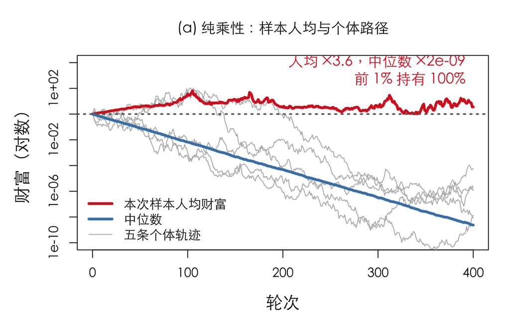

```r
ACC <- "#D62728"; GRN <- "#59A14F"
par(mar = c(4.8, 5.0, 3.6, 1.4), cex.lab = 1.32, cex.main = 1.12, family = "cjk")

## 纯乘性过程与离散金币过程各自演示，不共用控制参数。
set.seed(1); Np <- 5000; TT <- 400; m <- -0.05; sg <- 0.4
w <- rep(1, Np); ens <- med <- numeric(TT + 1); ens[1] <- med[1] <- 1
trk <- matrix(NA_real_, TT + 1, 5); trk[1, ] <- 1
for (t in 1:TT){
  w <- w * exp(m + sg*rnorm(Np))
  ens[t+1] <- mean(w); med[t+1] <- median(w); trk[t+1, ] <- w[1:5]
}
plot(NA, xlim = c(0, TT), ylim = c(1e-10, 1e4), log = "y",
     xlab = "轮次", ylab = "财富（对数）",
     main = "(a) 纯乘性：样本人均与个体路径")
for (k in 1:5) lines(0:TT, trk[, k], col = "gray72", lwd = 1.1)
lines(0:TT, ens, col = ACC, lwd = 3.4); lines(0:TT, med, col = "steelblue", lwd = 3.4)
abline(h = 1, lty = 3, lwd = 2, col = "gray40")
legend("bottomleft", c("本次样本人均财富", "中位数", "五条个体轨迹"),
       col = c(ACC, "steelblue", "gray72"), lwd = c(3.4, 3.4, 1.1), bty = "n", cex = 1.0)
text(TT, 1.2e3, sprintf("人均 ×%.1f，中位数 ×%.0e\n前 1%% 持有 %.0f%%",
     ens[TT+1], med[TT+1], 100*sum(sort(w, TRUE)[1:(Np/100)])/sum(w)),
     col = ACC, cex = 1.15, pos = 2)
```

```r
reg("erg_rounds", TT, "derived", "§5.4 erg_multiplicative", "独立纯乘性演示的时程")
reg("erg_mean", ens[TT+1], "point", "§5.4 erg_multiplicative", "末轮样本人均财富")
reg("erg_median", med[TT+1], "point", "§5.4 erg_multiplicative", "末轮样本中位财富")
```

这次独立演示跑了 400 轮，样本人均财富为初值的 3.6 倍，中位数为 2e-09 倍。一个样本时段的人均值，不能替代期望，更不能替代长时间结局。

**细节：纯乘性机器上「个体趋零而期望增长」怎么同时成立（可跳过）**

对这台纯乘性机器还要补一句，否则容易读错：当 $m<0<m+\sigma^2/2$，每个个体几乎必然趋零，期望却增长；而且固定任意有限人口再取长时间，总财富也几乎必然趋零——“$E[S_t]$ 在涨”是另一回事。先让人口趋于无穷，每个固定时刻的样本均值才趋于那个增长中的期望。

## 5.5 第四重：它不在这根轴上

**交换冻结**指的是交易本身停摆：穷到连一枚金币都拿不出来，配对了也成交不了。

这一重在本模型里不存在。本章的财富是连续的，每一对无条件成交——哪怕一个人只剩均值的万分之一，他仍然把这万分之一并进池子、再分回来。“有效破产”的人再多，也不意味着任何一笔交易失败。

它真正住的是另一根轴：金币的稀缺程度。把财富改成离散的金币、并要求付款方至少有一枚，成交率就跟着人均币量一起降——但它是连续地降，没有哪个正币量上会突然冻结。

换成离散金币就能把这根轴画出来：

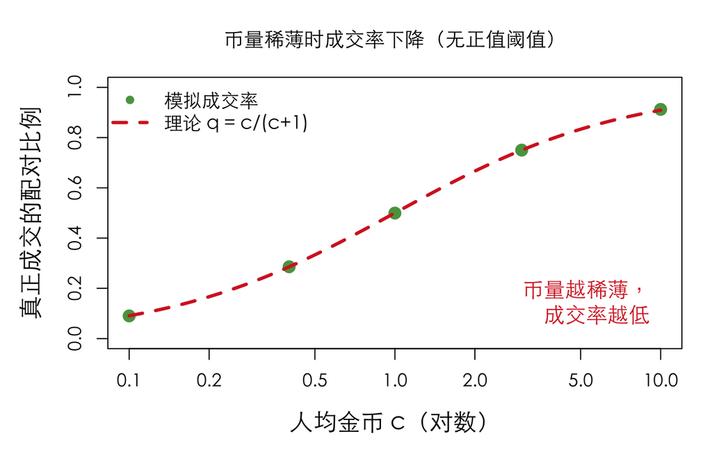

```r
ACC <- "#D62728"; GRN <- "#59A14F"
par(mar = c(4.8, 5.0, 3.6, 1.4), cex.lab = 1.32, cex.main = 1.12, family = "cjk")
cs <- c(10, 3, 1, 0.4, 0.1); rate <- numeric(length(cs))
for (k in seq_along(cs)){
  N2 <- 600; rounds <- 3000; tot <- round(cs[k]*N2)
  set.seed(3); wv <- rep(0, N2)
  if (tot > 0){ tb <- table(sample.int(N2, tot, replace = TRUE))
                wv[as.integer(names(tb))] <- as.integer(tb) }
  half <- N2/2; vol <- 0
  for (r in 1:rounds){
    idx <- sample.int(N2); i <- idx[1:half]; j <- idx[(half+1):N2]
    pay <- wv[i] > 0; vol <- vol + sum(pay); wv[i] <- wv[i] - pay; wv[j] <- wv[j] + pay
  }
  rate[k] <- vol/(rounds*half)
}
plot(cs, rate, log = "x", pch = 16, cex = 1.6, col = GRN, ylim = c(0, 1),
     xlab = "人均金币 c（对数）", ylab = "真正成交的配对比例",
     main = "币量稀薄时成交率下降（无正值阈值）")
curve(x/(x+1), add = TRUE, col = ACC, lwd = 3, lty = 2)
legend("topleft", c("模拟成交率", "理论 q = c/(c+1)"),
       col = c(GRN, ACC), pch = c(16, NA), lwd = c(NA, 3), lty = c(NA, 2), bty = "n", cex = 1.05)
## 注：q 对任何 c>0 都为正，所以这里标的是"越来越慢"，不是"停了"。
text(10, 0.12, "币量越稀薄，\n成交率越低", col = ACC, cex = 1.18, pos = 2)
```

**细节：成交率的闭式，以及为什么没有阈值（可跳过）**

要求付款方至少有一枚金币，成交率就成了人均币量 $c$ 的函数，而且精确地落在 $q=c/(c+1)$ 上——单调下降，但对任何 $c>0$ 都是正的，不存在“币量降到某个正值就冻结”的临界点。

这条轴是币量，不是 $\sigma$：本章把 $\sigma$ 拧到多大，都不会让连续财富的合并劈分停止成交。所以把这一重画进 $\sigma$ 的相图，是一个口径错误。

## 5.6 解析曲线与有限模拟放在一起

到这里，理论那一侧已经交代完了。自然的下一个问题是：跑出来的模拟，跟这条曲线对得上吗？

这个问题要小心回答，因为两边量的不是同一个东西：解析曲线给的是无穷人口、无穷时间下那个不动点的渐近尾指数；模拟给的是有限人口、有限轮数下在固定顶端一段上回归出来的一个斜率。后者本章一律称作有效上尾斜率 $\widehat\alpha_{\rm eff}$，与理论的 $\alpha_2$ 分开记号，就是为了不让它们混成一个概念。

**细节：$\widehat\alpha_{\rm eff}$ 到底怎么算的（可跳过）**

这个问题要小心回答，因为两边量的不是同一个东西。解析曲线给的是无穷人口、无穷时间下那个不动点的渐近尾指数；模拟给的是 $N=$ 1200、跑 500 轮之后，在固定的顶端一段上做对数回归得到的一个斜率。后者本章一律称作有效上尾斜率 $\widehat\alpha_{\rm eff}$，与理论的 $\alpha_2$ 分开记号，就是为了不让它们混成一个概念。

所以下面这张图是探索性的，不是检验。它对不上不能证伪理论，对得上也不能证实理论——中间隔着有限人口、有限轮数、渐近与非渐近、以及回归窗口这四层差异。既然如此还放它，是因为看一眼两条线的走向仍然有信息；而既然只是看一眼，就得把所有参数档全列出来，不能事后挑一个“吻合窗口”。（$\widehat\alpha_{\rm eff}$ 的算法：取顶端固定一段，做带截距的对数回归；下图误差棒是种子间标准差。）

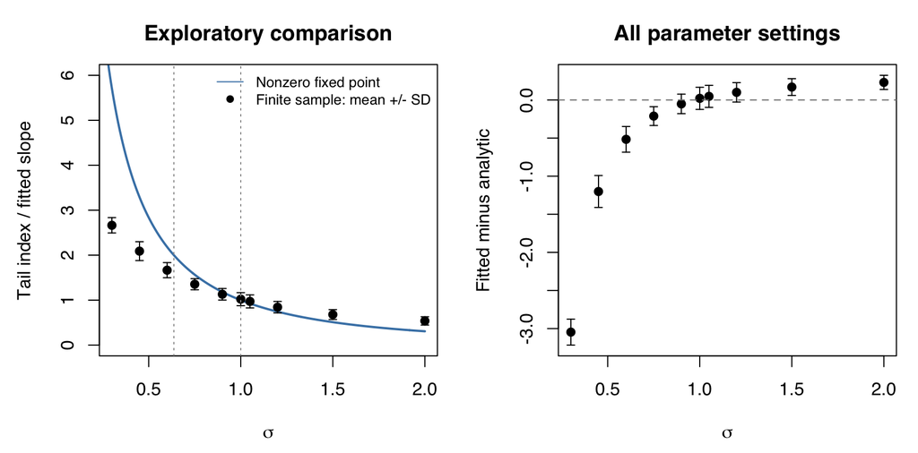

```r
alpha2_values <- vapply(sigs, alpha2, numeric(1))
alpha2_residual <- data.frame(sigma = sigs, analytic = alpha2_values,
  fitted = as.numeric(M["alpha", ]), seed_sd = as.numeric(S["alpha", ]),
  seed_se = as.numeric(S["alpha", ])/sqrt(SC_K),
  residual = as.numeric(M["alpha", ])-alpha2_values)
for (j in seq_len(nrow(alpha2_residual))) {
  for (nm in names(alpha2_residual)) reg(paste0("alpha2_", nm, "_", j),
    alpha2_residual[[nm]][j], if(nm == "analytic") "analytic" else if(nm == "fitted") "mean" else "derived",
    "alpha2_curve", "解析曲线与内存扫描的探索性比较")
}
## 注意：one() 的默认参数现在是具名常量，formals() 会返回符号而不是数值——直接用常量。
stopifnot(identical(formals(one)$N, quote(CH5_N)), identical(formals(one)$rounds, quote(CH5_R)))
reg("scan_N", CH5_N, "analytic", "§5.6 alpha2_curve", "模拟人口，取自 §5.1 的 CH5_N")
reg("scan_rounds", CH5_R, "analytic", "§5.6 alpha2_curve", "模拟轮数，取自 §5.1 的 CH5_R")
reg("scan_seeds", SC_K, "derived", "§5.6 alpha2_curve", "独立种子数")
reg("scan_tail_percent", 100*0.125, "derived", "§5.6 alpha2_curve", "固定尾窗百分比")
par(mfrow = c(1,2), mar = c(4.5,4.6,3,1), family = "sans")
plot(phase_sigma, phase_alpha, type = "l", xlim = range(sigs), ylim = c(0,6), lwd = 2,
     col = "steelblue", xlab = expression(sigma), ylab = "Tail index / fitted slope",
     main = "Exploratory comparison")
points(sigs, M["alpha", ], pch = 19)
arrows(sigs, M["alpha", ]-S["alpha", ], sigs, M["alpha", ]+S["alpha", ],
       code = 3, angle = 90, length = .035)
abline(v = c(sigma_c_var, sigma_c_mean), lty = 3, col = "gray60")
legend("topright", c("Nonzero fixed point", "Finite sample: mean +/- SD"),
       col = c("steelblue", "black"), lty = c(1,NA), pch = c(NA,19), bty = "n", cex = .8)
plot(sigs, alpha2_residual$residual, pch = 19, xlab = expression(sigma),
     ylab = "Fitted minus analytic", main = "All parameter settings",
     ylim = range(alpha2_residual$residual + rep(c(-1,1), each=length(sigs))*S["alpha", ]))
arrows(sigs, alpha2_residual$residual-S["alpha", ], sigs, alpha2_residual$residual+S["alpha", ],
       code = 3, angle = 90, length = .035)
abline(h=0, lty=2, col="gray50")
```

```r
ft_show(data.frame(
  `σ` = sprintf("%.2f", sigs), `解析 α₂` = sprintf("%.4f", alpha2_residual$analytic),
  `有效上尾斜率（顶端 12.5%）` = sprintf("%.4f", alpha2_residual$fitted),
  `种子 SD` = sprintf("%.4f", alpha2_residual$seed_sd),
  `均值 SE` = sprintf("%.4f", alpha2_residual$seed_se),
  `拟合 − 解析` = sprintf("%+.4f", alpha2_residual$residual), check.names = FALSE))
```

| σ | 解析 α₂ | 有效上尾斜率（顶端 12.5%） | 种子 SD | 均值 SE | 拟合 − 解析 |
| --- | --- | --- | --- | --- | --- |
| 0.30 | 5.7107 | 2.6642 | 0.1703 | 0.0492 | -3.0465 |
| 0.45 | 3.2909 | 2.0896 | 0.2094 | 0.0604 | -1.2013 |
| 0.60 | 2.1824 | 1.6659 | 0.1682 | 0.0486 | -0.5165 |
| 0.75 | 1.5656 | 1.3540 | 0.1236 | 0.0357 | -0.2116 |
| 0.90 | 1.1817 | 1.1300 | 0.1280 | 0.0369 | -0.0516 |
| 1.00 | 1.0000 | 1.0213 | 0.1452 | 0.0419 | +0.0213 |
| 1.05 | 0.9246 | 0.9719 | 0.1448 | 0.0418 | +0.0473 |
| 1.20 | 0.7432 | 0.8434 | 0.1273 | 0.0367 | +0.1001 |
| 1.50 | 0.5098 | 0.6793 | 0.1098 | 0.0317 | +0.1695 |
| 2.00 | 0.3069 | 0.5376 | 0.0929 | 0.0268 | +0.2307 |

**细节：$\sigma>1$ 一侧必须分清的几个对象，以及归一化为什么不会机械地抬高斜率（可跳过）**

这里叠着有限人口、有限时间、不动点尾渐近、固定顶端 12.5% 回归这几层差异。上区斜率一般不等于渐近指数。归一化也不会机械地产生斜率上偏：带截距的回归中，$w\mapsto cw$ 只把 $\log w$ 平移，斜率精确不变；有限尺度影响的符号与量级需要另外的证据。

尤其在 $\sigma>1$，必须分清下面几个对象：

| 对象 | 已知性质 |
| --- | --- |
| 非零平滑变换不动点 | 无穷均值，尾指数 α₂ < 1；解析曲线画的是它 |
| 从均等出发的无穷人口动理学迭代 | 趋于 δ₀；δ₀ 没有幂律尾 |
| 有限人口模拟 | 与前两者的长时间关系均未证 |

有限人口的标记财富有 $0\le w_{I,t}\le N$ 且 $Ew_{I,t}=1$，因此不可能在固定 $N$ 下依分布趋零。最小反例是 $N=2$：每轮恰为 $(2U,2(1-U))$，与回报、前一状态及 $\sigma$ 无关，标记分布恒为 $\mathrm{Unif}(0,2)$。单一人口规模上的曲线吻合，不能证明双重极限正在被逼近。

那么基尼呢？前面反复说控制参数是 $\sigma$ 不是 $G$，但读者自然会想知道：临界那一档的基尼到底是多少。这个数可以给，只是必须以范围的形式给，理由紧接在数字后面。

在 $\sigma=1$、$N=1200$、500 轮下，12 个种子的基尼范围是 0.79–0.91，均值 0.859，种子标准差 0.0393。模型基尼与 UBS 的人均成人财富基尼不是可比对象；相变判据是 $\sigma$，不是 $G$。瑞典的报告值即使落在这个区间里，也不代表处在模型的临界点。

同一参数、同一时程、同一批种子下，人口从 300、1200 到 4800，基尼均值依次为 0.83、0.86、0.89，随这几档人口规模上移。参数、观测量、人口规模、极限次序都不同，不能用其中一个横截面点值替代解析边界；理论在先人口、后时间的次序下给的是 $G_t\to1$。拟合斜率穿过一时的基尼，又是另一个量。

有一件事是真能验的。上面那张图验不了什么，但本章地基里那条“固定轮数、人口趋于无穷”的命题可以直接对照——因为它给出的是一个精确的递推，而递推的解能独立算出来。这一步可以直接对照：独立解 Laplace 递推，再从粒子系统计算 $\widehat\phi_{N,t}(s)=N^{-1}\sum_i e^{-sw_{i,t}}$。固定短时程，增加人口，比较误差与重复不确定度。结论先说：人口越大，两者的差越小，方向与固定时间的命题一致。

这一步的做法与结果都放在正文，因为它是全章唯一一个真正做成了的检验。

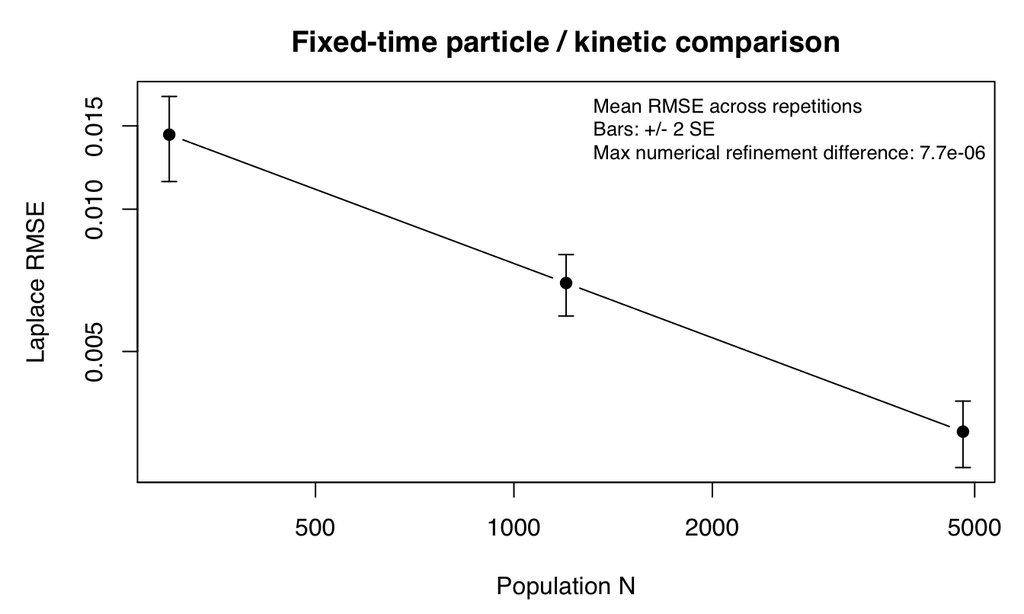

```r
## 高斯求积节点由 Jacobi 矩阵求得，只用 base R。
.kc_gauss <- function(n, normal=FALSE) {
  b <- if(normal) sqrt(seq_len(n-1)) else seq_len(n-1)/sqrt(4*seq_len(n-1)^2-1)
  J <- matrix(0,n,n); J[cbind(1:(n-1),2:n)] <- b; J <- J+t(J)
  eg <- eigen(J,symmetric=TRUE); ord <- order(eg$values)
  list(x=if(normal) eg$values[ord] else (eg$values[ord]+1)/2,
       w=eg$vectors[1,ord]^2)
}
.kc_sigma <- .7; .kc_times <- c(1,3,5); .kc_s <- c(.25,1,4)
.kc_reps <- 40; .kc_N <- c(300,1200,4800)
.kc_targets <- expand.grid(s=.kc_s,t=.kc_times)
.kc_solve <- function(ng,nq) {
  lg <- seq(-24,24,length.out=ng); ss <- exp(lg); f <- exp(-ss)
  gu <- .kc_gauss(nq); gz <- .kc_gauss(nq,TRUE)
  lr <- .kc_sigma*gz$x-.kc_sigma^2/2
  ans <- matrix(NA_real_,length(.kc_s),max(.kc_times))
  for(tt in seq_len(max(.kc_times))) {
    nxt <- numeric(ng)
    for(j in seq_along(gu$x)) {
      args <- outer(lg+log(gu$x[j]),lr,"+")
      vals <- matrix(approx(lg,f,xout=as.vector(args),yleft=1,yright=0)$y,ng,nq)
      nxt <- nxt+gu$w[j]*as.vector(vals %*% gz$w)^2
    }
    f <- nxt
    ans[,tt] <- approx(lg,f,xout=log(.kc_s))$y
  }
  as.vector(ans[,.kc_times])
}
.kc_coarse <- .kc_solve(1800,24)
.kc_mid <- .kc_solve(3600,36)
.kc_fine <- .kc_solve(7200,52)
.kc_numdiff <- abs(.kc_fine-.kc_mid)
.kc_previous <- abs(.kc_mid-.kc_coarse)
## 独立跑粒子转移核，仅取短时程；不复用积分方程生成样本。
.kc_rng <- .Random.seed
.kc_particle <- function(n,seed) {
  set.seed(seed); w <- rep(1,n); hh <- n/2
  ans <- matrix(NA_real_,length(.kc_s),length(.kc_times))
  for(tt in seq_len(max(.kc_times))) {
    w <- w*exp(.01-.kc_sigma^2/2+.kc_sigma*rnorm(n))
    ii <- sample.int(n); i <- ii[1:hh]; j <- ii[(hh+1):n]
    pool <- w[i]+w[j]; u <- runif(hh); w[i] <- u*pool; w[j] <- (1-u)*pool
    w <- w/mean(w)
    if(tt %in% .kc_times) ans[,match(tt,.kc_times)] <- vapply(.kc_s,function(s) mean(exp(-s*w)),numeric(1))
  }
  as.vector(ans)
}
.kc_raw <- lapply(.kc_N,function(n) vapply(seq_len(.kc_reps),function(seed)
  .kc_particle(n,51000+seed),numeric(nrow(.kc_targets))))
.Random.seed <- .kc_rng
kinetic_results <- do.call(rbind,lapply(seq_along(.kc_N),function(j) {
  a <- .kc_raw[[j]]
  data.frame(N=.kc_N[j],.kc_targets,phi=.kc_fine,particle=rowMeans(a),
    seed_sd=apply(a,1,sd),seed_se=apply(a,1,sd)/sqrt(.kc_reps),
    residual=rowMeans(a)-.kc_fine,numeric_diff=.kc_numdiff,previous_diff=.kc_previous)
}))
.kc_rms_raw <- lapply(.kc_raw,function(a) sqrt(colMeans((a-.kc_fine)^2)))
.kc_rms <- vapply(.kc_rms_raw,mean,numeric(1))
.kc_rms_se <- vapply(.kc_rms_raw,sd,numeric(1))/sqrt(.kc_reps)
reg("kinetic_sigma",.kc_sigma,"derived","§5.6 kinetic_check","非零回报涨落")
reg("kinetic_tmax",max(.kc_times),"derived","§5.6 kinetic_check","固定短时程")
reg("kinetic_reps",.kc_reps,"derived","§5.6 kinetic_check","独立重复数")
reg("kinetic_numeric_diff",max(.kc_numdiff),"derived","§5.6 kinetic_check","最后两档积分和插值加密的最大差")
stopifnot(all(is.finite(as.matrix(kinetic_results))),all(.kc_fine>0 & .kc_fine<1),
          max(.kc_numdiff)<1e-4)
par(mar=c(4.5,4.7,2.8,1),family="sans")
plot(.kc_N,.kc_rms,log="xy",type="b",pch=19,xlab="Population N",ylab="Laplace RMSE",
     main="Fixed-time particle / kinetic comparison",
     ylim=range(c(.kc_rms-2*.kc_rms_se,.kc_rms+2*.kc_rms_se)))
arrows(.kc_N,.kc_rms-2*.kc_rms_se,.kc_N,.kc_rms+2*.kc_rms_se,
       code=3,angle=90,length=.05)
legend("topright",c("Mean RMSE across repetitions","Bars: +/- 2 SE",
                     sprintf("Max numerical refinement difference: %.2g",max(.kc_numdiff))),bty="n",cex=.8)
```

```r
ft_show(data.frame(
  `N`=kinetic_results$N,`轮次`=kinetic_results$t,`s`=kinetic_results$s,
  `递推 φ`=sprintf("%.5f",kinetic_results$phi),
  `粒子均值`=sprintf("%.5f",kinetic_results$particle),
  `种子 SD`=sprintf("%.5f",kinetic_results$seed_sd),
  `均值 SE`=sprintf("%.5f",kinetic_results$seed_se),
  `粒子 − 递推`=sprintf("%+.5f",kinetic_results$residual),
  `数值差`=sprintf("%.1e",kinetic_results$numeric_diff),check.names=FALSE),
  title="固定短时程的独立对照；数值差来自最后两档加密")
```

固定短时程的独立对照；数值差来自最后两档加密

| N | 轮次 | s | 递推 φ | 粒子均值 | 种子 SD | 均值 SE | 粒子 − 递推 | 数值差 |
| --- | --- | --- | --- | --- | --- | --- | --- | --- |
| 300 | 1 | 0.25 | 0.79507 | 0.79520 | 0.00192 | 0.00030 | +0.00013 | 3.2e-06 |
| 300 | 1 | 1.00 | 0.47244 | 0.47286 | 0.00814 | 0.00129 | +0.00042 | 1.2e-06 |
| 300 | 1 | 4.00 | 0.15975 | 0.16003 | 0.01064 | 0.00168 | +0.00028 | 2.0e-06 |
| 300 | 3 | 0.25 | 0.81621 | 0.81553 | 0.00616 | 0.00097 | -0.00067 | 4.9e-06 |
| 300 | 3 | 1.00 | 0.55448 | 0.55166 | 0.01413 | 0.00223 | -0.00282 | 4.4e-06 |
| 300 | 3 | 4.00 | 0.25913 | 0.25592 | 0.01485 | 0.00235 | -0.00320 | 6.5e-07 |
| 300 | 5 | 0.25 | 0.82785 | 0.82897 | 0.01418 | 0.00224 | +0.00112 | 6.7e-06 |
| 300 | 5 | 1.00 | 0.58894 | 0.59064 | 0.02994 | 0.00473 | +0.00170 | 7.7e-06 |
| 300 | 5 | 4.00 | 0.30204 | 0.30485 | 0.03023 | 0.00478 | +0.00281 | 3.9e-06 |
| 1,200 | 1 | 0.25 | 0.79507 | 0.79512 | 0.00081 | 0.00013 | +0.00004 | 3.2e-06 |
| 1,200 | 1 | 1.00 | 0.47244 | 0.47263 | 0.00352 | 0.00056 | +0.00019 | 1.2e-06 |
| 1,200 | 1 | 4.00 | 0.15975 | 0.15986 | 0.00584 | 0.00092 | +0.00011 | 2.0e-06 |
| 1,200 | 3 | 0.25 | 0.81621 | 0.81652 | 0.00324 | 0.00051 | +0.00031 | 4.9e-06 |
| 1,200 | 3 | 1.00 | 0.55448 | 0.55595 | 0.00835 | 0.00132 | +0.00147 | 4.4e-06 |
| 1,200 | 3 | 4.00 | 0.25913 | 0.26016 | 0.00936 | 0.00148 | +0.00103 | 6.5e-07 |
| 1,200 | 5 | 0.25 | 0.82785 | 0.82796 | 0.00520 | 0.00082 | +0.00012 | 6.7e-06 |
| 1,200 | 5 | 1.00 | 0.58894 | 0.58984 | 0.01160 | 0.00183 | +0.00090 | 7.7e-06 |
| 1,200 | 5 | 4.00 | 0.30204 | 0.30370 | 0.01275 | 0.00202 | +0.00166 | 3.9e-06 |
| 4,800 | 1 | 0.25 | 0.79507 | 0.79499 | 0.00042 | 0.00007 | -0.00008 | 3.2e-06 |
| 4,800 | 1 | 1.00 | 0.47244 | 0.47197 | 0.00167 | 0.00026 | -0.00047 | 1.2e-06 |
| 4,800 | 1 | 4.00 | 0.15975 | 0.15896 | 0.00232 | 0.00037 | -0.00078 | 2.0e-06 |
| 4,800 | 3 | 0.25 | 0.81621 | 0.81628 | 0.00150 | 0.00024 | +0.00008 | 4.9e-06 |
| 4,800 | 3 | 1.00 | 0.55448 | 0.55446 | 0.00367 | 0.00058 | -0.00003 | 4.4e-06 |
| 4,800 | 3 | 4.00 | 0.25913 | 0.25852 | 0.00420 | 0.00066 | -0.00061 | 6.5e-07 |
| 4,800 | 5 | 0.25 | 0.82785 | 0.82746 | 0.00297 | 0.00047 | -0.00039 | 6.7e-06 |
| 4,800 | 5 | 1.00 | 0.58894 | 0.58828 | 0.00599 | 0.00095 | -0.00066 | 7.7e-06 |
| 4,800 | 5 | 4.00 | 0.30204 | 0.30185 | 0.00663 | 0.00105 | -0.00018 | 3.9e-06 |

**细节：这一步的数值方法与参数（可跳过）**

这里用 $\sigma=0.7$，最长 5 轮，40 次重复。积分端采用独立的高斯求积与对数网格插值；表中“数值差”是相邻两档加密的差，是积分和插值误差的数值估计，不是严格误差上界。图展示所有检查时刻与 Laplace 自变量上的均方根误差。

要强调它验的是哪一半：这一步支持的是“固定轮数、人口趋于无穷”那个近似，替有限模拟的长时间行为作不了证。

前面预告过的那处留白，就是这里。本章关于 $\alpha_2$ 的结论都活在“先人口、后时间”这一个次序里；而回报加合并劈分这个模型在固定人口下的长期行为，本章没有确立。（章首那个 yard-sale 的通吃结论确实是固定人口、时间趋于无穷的——但那是另一个模型，它的鞅论证在这里用不上。）模拟跑的又恰好是固定人口，而且只跑到有限的第 500 轮，所以那张对照图只能是探索性的。

作用域到这里为止：本章解析刻画了非零不动点尾指数，证明了树极限中的一致可积性转变、弱凝聚和基尼极限；没有给出有限人口稳态的强凝聚，没有给出国别基尼阈值，也不允许从拟合的横截面斜率反推控制参数。

## 5.7 另一种相变：财富优势与再分配

本章一路把“$\alpha_2$ 穿过 1”当成相变的标志，读到这里很容易留下一个印象：尾指数穿过 1，就是凝聚的通用判据。这个印象是错的，而且用一个现成的反例就能纠正——所以这一节把那个反例单独摆出来。

它同样是一个财富凝聚的相变，同样有明确的临界点，但整个过程里没有任何 Pareto 指数穿过 1。Boghosian 的扩展 yard-sale 用财富优势强度 $\zeta$ 对抗再分配强度 $\tau_\infty$。若寡头持有的财富份额为 $c(t)$，两股力量这样竞争：再分配按份额从寡头身上抽走财富，出一项 $-\tau_\infty c$；财富优势让寡头从交易中占便宜，但能占的便宜取决于普通人群手里还剩多少，也就是 $1-c$，出一项 $+\zeta c(1-c)$。寡头越大，可榨取的对象越少——这个自限效应正是相变的来源。合起来 (Boghosian et al. 2016)

**细节：那条竞争方程与它的闭式解（可跳过）**

$$c'(t)=c(t)[-\tau_\infty+\zeta(1-c(t))],\qquad
c_* = \max\left(0,1-\frac{\tau_\infty}{\zeta}\right).$$

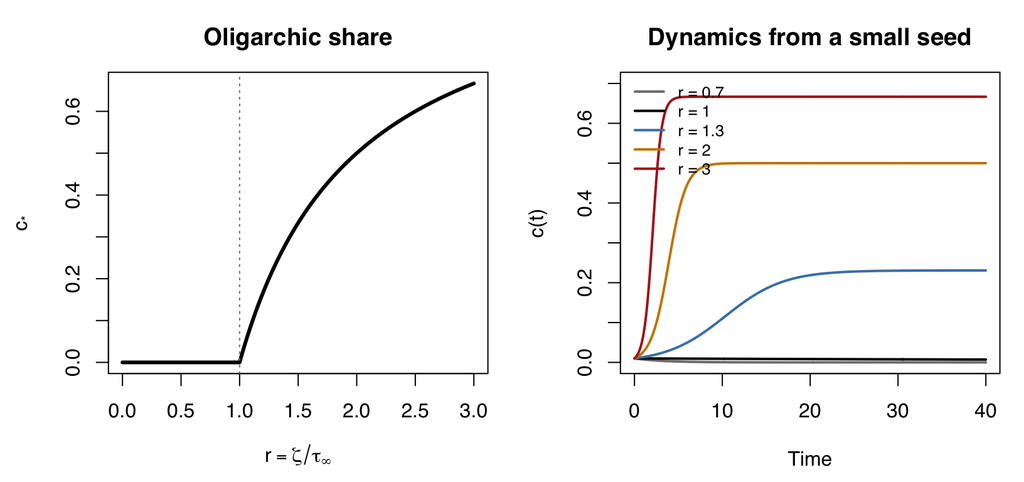

```r
## 非零初值按闭式解演化，避免把临界附近的慢过程误当成稳态。
.bog_tau <- 1; .bog_c0 <- 0.01
.bog_rcrit <- .bog_tau/.bog_tau
.bog_rhalf <- uniroot(function(r) 1-1/r-1/2, c(1,4))$root
reg("bog_rcrit", .bog_rcrit, "analytic", "§5.7 boghosian_oligarchy", "优势与再分配平衡")
reg("bog_rhalf", .bog_rhalf, "analytic", "§5.7 boghosian_oligarchy", "寡头占一半所需的比值")
reg("bog_c0", .bog_c0, "derived", "§5.7 boghosian_oligarchy", "动力学初值")
.bog_sol <- function(t, r) {
  zeta <- r*.bog_tau; a <- zeta-.bog_tau
  if(abs(a)<1e-12) return(.bog_c0/(1+zeta*.bog_c0*t))
  .bog_c0*exp(a*t)/(1+zeta*.bog_c0*expm1(a*t)/a)
}
.bog_r <- seq(0,3,length.out=400); .bog_t <- seq(0,40,length.out=500)
par(mfrow=c(1,2),mar=c(4.5,4.5,3,1),family="sans")
plot(.bog_r, ifelse(.bog_r>1,1-1/pmax(.bog_r,1),0),type="l",lwd=3,
     xlab=expression(r==zeta/tau[infinity]),ylab=expression(c["*"]),main="Oligarchic share")
abline(v=.bog_rcrit,lty=3,col="gray50")
plot(NA,xlim=range(.bog_t),ylim=c(0,.7),xlab="Time",ylab="c(t)",main="Dynamics from a small seed")
.bog_rs <- c(.7,1,1.3,2,3); .bog_cols <- c("gray50","black","steelblue","orange3","firebrick")
for(j in seq_along(.bog_rs)) lines(.bog_t,.bog_sol(.bog_t,.bog_rs[j]),col=.bog_cols[j],lwd=2)
legend("topleft",paste("r =",.bog_rs),col=.bog_cols,lwd=2,bty="n",cex=.8)
```

```r
stopifnot(max(abs(vapply(.bog_rs,function(r) .bog_sol(0,r),numeric(1))-.bog_c0))<1e-12)
```

控制参数是 $r=\zeta/\tau_\infty$，临界值为 1；$r=2$ 时寡头占一半。动力学图从 $c_0=0.01$ 出发。原文称它为二阶相变：$c_*$ 连续，一阶导数在临界处不连续。

普通人群的尾在临界上下都是高斯尾，恰在临界处退化为指数尾。这里没有任何 Pareto 指数穿过一。与之相对，本章平滑变换的 $\alpha_2$ 穿过一，确实与一致可积性的相变由定理重合。“尾指数穿过一”是模型相关的判据，凝聚没有一条通用的 Pareto 刻度。

## 5.8 把基尼系数翻译成分布：一张换算表

给定基尼，分布还没有定下来。只有先指定一个单参数族，才谈得上换算——下面那张表就是替几个常见的族各算一遍。

**细节：三个族的基尼闭式（可跳过）**

$$G_{\rm Pareto}=\frac1{2\alpha-1},\qquad
G_{\rm Gamma}=\frac{\Gamma(k+1/2)}{\sqrt\pi\Gamma(k+1)},\qquad
G_{\rm LN}=2\Phi(\sigma/\sqrt2)-1.$$

其中 Pareto 需要 $\alpha>1$；这里对数正态族的 $\sigma$ 是形状参数，不能拿它替代本章回报过程的控制参数。

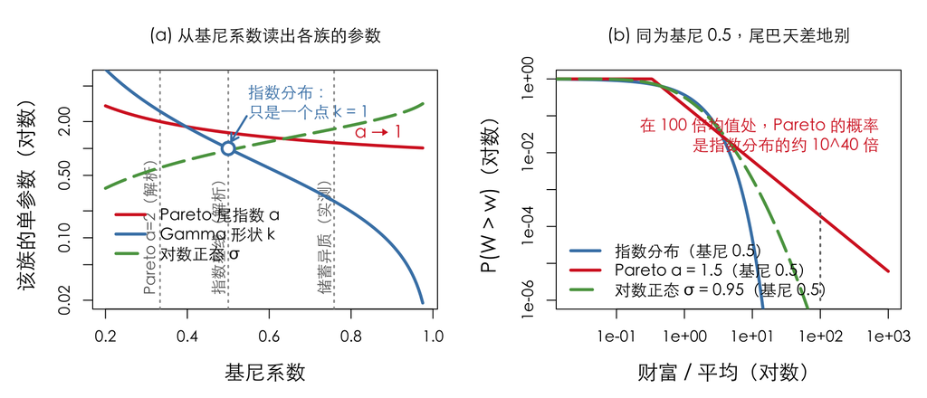

Pietra 列取自对数正态族；换族便变。这是形状换算，不是相变定位。

| 基尼 G | 这个位置是什么 | Pareto α | Gamma k | 对数正态 σ | Pietra P |
| --- | --- | --- | --- | --- | --- |
| 0.333 | Pareto α=2（解析） | 2.00 | 2.604 | 0.61 | 0.239 |
| 0.271 | 全民储蓄率 0.5（实测） | 2.34 | 4.076 | 0.49 | 0.194 |
| 0.500 | 岛屿基线（解析） | 1.50 | 1.000 | 0.95 | 0.367 |
| 0.758 | 储蓄倾向异质（实测） | 1.16 | 0.257 | 1.66 | 0.592 |
| 0.830 | 美国财富基尼 | 1.10 | 0.159 | 1.94 | 0.668 |
| 0.870 | 瑞典财富基尼 | 1.07 | 0.114 | 2.14 | 0.716 |

```r
ACC <- "#D62728"; BLU <- "steelblue"; GRN <- "#59A14F"
par(mfrow = c(1, 2), mar = c(4.8, 5.0, 3.8, 1.4), cex.lab = 1.32, cex.main = 1.1, family = "cjk")

## (a) 换算表：给定基尼，各单参数族的参数是多少
gs    <- seq(0.20, 0.975, by = 0.005)
a_par <- (1/gs + 1)/2                                    # Pareto:   G = 1/(2a-1)
k_gam <- sapply(gs, function(g) uniroot(function(k)
           gamma(k+0.5)/(sqrt(pi)*gamma(k+1)) - g, c(1e-3, 60))$root)
s_lnm <- sqrt(2)*qnorm((gs + 1)/2)                       # Lognormal: G = 2*Phi(s/sqrt2)-1
plot(NA, xlim = c(0.2, 0.98), ylim = c(0.02, 6), log = "y",
     xlab = "基尼系数", ylab = "该族的单参数（对数）",
     main = "(a) 从基尼系数读出各族的参数")
## 这里的族参数换算不是动力学相变定位。
mark <- c(1/3, 0.50, REG$save_het$v)
abline(v = mark, lty = 3, lwd = 1.8, col = "gray62")
text(mark, 0.023, c("Pareto α=2（解析）", "指数基线（解析）", "储蓄异质（实测）"),
     srt = 90, adj = c(0, -0.35), col = "gray40", cex = 1.0)
lines(gs, a_par, col = ACC, lwd = 3.2)
lines(gs, k_gam, col = BLU, lwd = 3.2)
lines(gs, s_lnm, col = GRN, lwd = 3.2, lty = 5)
points(0.5, 1, pch = 21, bg = "white", col = BLU, lwd = 3, cex = 1.8)
arrows(0.545, 2.3, 0.507, 1.2, length = 0.09, lwd = 2.2, col = BLU)
text(0.525, 2.9, "指数分布：\n只是一个点 k = 1", col = BLU, cex = 1.06, pos = 4)
text(0.95, 1.45, "α → 1", col = ACC, cex = 1.15, pos = 2)
legend(0.19, 0.30, c("Pareto 尾指数 α", "Gamma 形状 k", "对数正态 σ"),
       col = c(ACC, BLU, GRN), lwd = 3.2, lty = c(1, 1, 5), bty = "n", cex = 1.05)

## (b) 同一个基尼，形状可以完全不同
xx <- 10^seq(-2, 3, length.out = 400)
al <- 1.5; mp <- al/(al - 1)                             # Pareto(1.5) 的均值 = 3
sg <- sqrt(2)*qnorm(0.75); ml <- exp(sg^2/2)             # 同基尼的对数正态
plot(NA, xlim = c(0.02, 1000), ylim = c(1e-6, 1), log = "xy",
     xlab = "财富 / 平均（对数）", ylab = "P(W > w)（对数）",
     main = "(b) 同为基尼 0.5，尾巴天差地别")
lines(xx, exp(-xx), col = BLU, lwd = 3.2)
lines(xx, ifelse(xx >= 1/mp, (1/(mp*xx))^al, 1), col = ACC, lwd = 3.2)
lines(xx, 1 - pnorm(log(xx*ml)/sg), col = GRN, lwd = 3.2, lty = 5)
legend("bottomleft", c("指数分布（基尼 0.5）", "Pareto α = 1.5（基尼 0.5）",
                       "对数正态 σ = 0.95（基尼 0.5）"),
       col = c(BLU, ACC, GRN), lwd = 3.2, lty = c(1, 1, 5), bty = "n", cex = 1.05)
segments(100, 1e-6, 100, 3e-4, lty = 3, lwd = 2, col = "gray45")
reg("translate_log10_ratio", log10(((1/(mp*100))^al)/exp(-100)), "analytic", "§5.8 gini_translate", "百倍均值处的尾概率比的常用对数")
reg("translate_x", 100, "derived", "§5.8 gini_translate", "尾概率比较位置")
text(1000, 0.022, sprintf("在 %.0f 倍均值处，Pareto 的概率\n是指数分布的约 10^%.0f 倍", REG$translate_x$v, REG$translate_log10_ratio$v),
     col = ACC, cex = 1.06, pos = 2)
```

指数分布只有尺度，没有形状旋钮；基尼又不随尺度改变，所以它在换算图上只是一个点。右图中几种分布的基尼完全相同，尾部却天差地别：在均值的 100 倍处，Pareto 的尾概率约为指数分布的 $10^{40}$ 倍。

基尼定不住形状，按基尼反推的 Pareto 参数也不能证明真实分布有幂律尾。理论尾指数与拟合斜率的比较，见解析曲线与有限模拟放在一起。

顺带回答一个很自然的反问：既然只是要一个形状，为什么不干脆用 Gamma？它比 Pareto 眼熟，而且本文里已经出现过——第 3.4 节那个全民储蓄的稳态就是它。两条理由。

**细节：那两条理由各自的算术（可跳过）**

一是尾巴的形状。Gamma 是 $p(x)\propto x^{k-1}e^{-x/\theta}$，那个 $e^{-x/\theta}$ 让它的尾巴仍然是指数的。在双对数纸上量局部斜率 $\mathrm{d}\log p/\mathrm{d}\log x$：幂律恒定不变，而 Gamma(4) 从 5 倍均值处的 -17.0 一路陡到 80 倍处的 -317——它在那张纸上是弯的。而第 2.6 节那张美国收入图，顶端那一截跨几个数量级是直的。

二是矩，这条更要命，因为它正好是本章的题目。Gamma 的各阶矩有闭式 $E[X^n]=\theta^n\Gamma(k+n)/\Gamma(k)$，对任意 $k>0$、任意 $n$ 都有限——$k=0.5$ 时 $E[X^{20}]$ 已经是 3.05e+17，大得离谱，但有限。Gamma 族里根本没有“矩发散”这个事件，于是方差不会死，均值也不会死。本章整章找的就是这两道边界，而它们在 Gamma 族里不存在。

更根本的分野在这儿：Gamma 是一个可以挑的形状，不是一台可以拧的机器。挑一个 Pareto、再把 $\alpha$ 拧过 2 和 1，当然也能“看到”相变——但那时 $\alpha$ 是输入，等于把答案写进前提。本章要的是 $\alpha_2(\sigma)$ 从动力学里解出来：手里拧的是回报涨落 $\sigma$ 这个有实际含义的旋钮，尾指数是它的输出，而且不含一个拟合参数。这就是为什么这一章非得有自己的模型，不能只借一个分布族。